# Thakur Arun Singh FRA Milestone 1 Project

```python
import numpy as np
import pandas as pd
import matplotlib.pyplot as plt
import seaborn as sns
%matplotlib inline

import warnings
warnings.filterwarnings('ignore')

from sklearn.model_selection import train_test_split
import statsmodels.formula.api as SM
import sklearn.metrics as metrics
from statsmodels.stats.outliers_influence import variance_inflation_factor
```

```python
df = pd.read_excel('Company_Data2015-1.xlsx')
```

```python
df.head()
```

|  | Co_Code | Co_Name | Networth Next Year | Equity Paid Up | Networth | Capital Employed | Total Debt | Gross Block | Net Working Capital | Current Assets | ... | PBIDTM (%)[Latest] | PBITM (%)[Latest] | PBDTM (%)[Latest] | CPM (%)[Latest] | APATM (%)[Latest] | Debtors Velocity (Days) | Creditors Velocity (Days) | Inventory Velocity (Days) | Value of Output/Total Assets | Value of Output/Gross Block |
| --- | --- | --- | --- | --- | --- | --- | --- | --- | --- | --- | --- | --- | --- | --- | --- | --- | --- | --- | --- | --- | --- |
| 0 | 16974 | Hind.Cables | -8021.60 | 419.36 | -7027.48 | -1007.24 | 5936.03 | 474.30 | -1076.34 | 40.50 | ... | 0.00 | 0.00 | 0.00 | 0.00 | 0.00 | 0 | 0 | 45.0 | 0.00 | 0.00 |
| 1 | 21214 | Tata Tele. Mah. | -3986.19 | 1954.93 | -2968.08 | 4458.20 | 7410.18 | 9070.86 | -1098.88 | 486.86 | ... | -10.30 | -39.74 | -57.74 | -57.74 | -87.18 | 29 | 101 | 2.0 | 0.31 | 0.24 |
| 2 | 14852 | ABG Shipyard | -3192.58 | 53.84 | 506.86 | 7714.68 | 6944.54 | 1281.54 | 4496.25 | 9097.64 | ... | -5279.14 | -5516.98 | -7780.25 | -7723.67 | -7961.51 | 97 | 558 | 0.0 | -0.03 | -0.26 |
| 3 | 2439 | GTL | -3054.51 | 157.30 | -623.49 | 2353.88 | 2326.05 | 1033.69 | -2612.42 | 1034.12 | ... | -3.33 | -7.21 | -48.13 | -47.70 | -51.58 | 93 | 63 | 2.0 | 0.24 | 1.90 |
| 4 | 23505 | Bharati Defence | -2967.36 | 50.30 | -1070.83 | 4675.33 | 5740.90 | 1084.20 | 1836.23 | 4685.81 | ... | -295.55 | -400.55 | -845.88 | 379.79 | 274.79 | 3887 | 346 | 0.0 | 0.01 | 0.05 |

5 rows × 67 columns

```python
df.describe()
```

|  | Co_Code | Networth Next Year | Equity Paid Up | Networth | Capital Employed | Total Debt | Gross Block | Net Working Capital | Current Assets | Current Liabilities and Provisions | ... | PBIDTM (%)[Latest] | PBITM (%)[Latest] | PBDTM (%)[Latest] | CPM (%)[Latest] | APATM (%)[Latest] | Debtors Velocity (Days) | Creditors Velocity (Days) | Inventory Velocity (Days) | Value of Output/Total Assets | Value of Output/Gross Block |
| --- | --- | --- | --- | --- | --- | --- | --- | --- | --- | --- | --- | --- | --- | --- | --- | --- | --- | --- | --- | --- | --- |
| count | 3586.000000 | 3586.000000 | 3586.000000 | 3586.000000 | 3586.000000 | 3586.000000 | 3586.000000 | 3586.000000 | 3586.000000 | 3586.000000 | ... | 3585.000000 | 3585.000000 | 3585.000000 | 3585.000000 | 3585.000000 | 3586.000000 | 3.586000e+03 | 3483.000000 | 3586.000000 | 3586.000000 |
| mean | 16065.388734 | 725.045251 | 62.966584 | 649.746299 | 2799.611054 | 1994.823779 | 594.178829 | 410.809665 | 1960.349172 | 391.992078 | ... | -51.162890 | -109.213414 | -311.570357 | -307.005632 | -365.056187 | 603.894032 | 2.057855e+03 | 79.644559 | 0.819757 | 61.884548 |
| std | 19776.817379 | 4769.681004 | 778.761744 | 4091.988792 | 26975.135385 | 23652.842746 | 4871.547802 | 6301.218546 | 22577.570829 | 2675.001631 | ... | 1795.131025 | 3057.635870 | 10921.592639 | 10676.149629 | 12500.051387 | 10636.759580 | 5.416948e+04 | 137.847792 | 1.201400 | 976.824352 |
| min | 4.000000 | -8021.600000 | 0.000000 | -7027.480000 | -1824.750000 | -0.720000 | -41.190000 | -13162.420000 | -0.910000 | -0.230000 | ... | -78870.450000 | -141600.000000 | -590500.000000 | -572000.000000 | -688600.000000 | 0.000000 | 0.000000e+00 | -199.000000 | -0.330000 | -61.000000 |
| 25% | 3029.250000 | 3.985000 | 3.750000 | 3.892500 | 7.602500 | 0.030000 | 0.570000 | 0.942500 | 4.000000 | 0.732500 | ... | 0.000000 | 0.000000 | 0.000000 | 0.000000 | 0.000000 | 8.000000 | 8.000000e+00 | 0.000000 | 0.070000 | 0.270000 |
| 50% | 6077.500000 | 19.015000 | 8.290000 | 18.580000 | 39.090000 | 7.490000 | 15.870000 | 10.145000 | 24.540000 | 9.225000 | ... | 8.070000 | 5.230000 | 4.690000 | 3.890000 | 1.590000 | 49.000000 | 3.900000e+01 | 35.000000 | 0.480000 | 1.530000 |
| 75% | 24269.500000 | 123.802500 | 19.517500 | 117.297500 | 226.605000 | 72.350000 | 131.895000 | 61.175000 | 135.277500 | 65.650000 | ... | 18.990000 | 14.290000 | 14.110000 | 11.390000 | 7.410000 | 106.000000 | 8.900000e+01 | 96.000000 | 1.160000 | 4.910000 |
| max | 72493.000000 | 111729.100000 | 42263.460000 | 81657.350000 | 714001.250000 | 652823.810000 | 128477.590000 | 223257.560000 | 721166.000000 | 83232.980000 | ... | 19233.330000 | 19195.700000 | 15640.000000 | 15640.000000 | 15266.670000 | 514721.000000 | 2.034145e+06 | 996.000000 | 17.630000 | 43404.000000 |

8 rows × 66 columns

```python
df_dict = pd.read_excel('C:\\Users\\anant\\OneDrive\\Desktop\\GL\\FRA-1\\Data_Dictionary.xlsx')
```

```python
df.columns = df_dict['New Field Name'].to_list()
df.columns
```

```
Index(['Co_Code', 'Co_Name', 'Networth_Next_Year', 'Equity_Paid_Up',
       'Networth', 'Capital_Employed', 'Total_Debt', 'Gross_Block',
       'Net_Working_Capital', 'Curr_Assets', 'Curr_Liab_and_Prov',
       'Total_Assets_to_Liab', 'Gross_Sales', 'Net_Sales', 'Other_Income',
       'Value_Of_Output', 'Cost_of_Prod', 'Selling_Cost', 'PBIDT', 'PBDT',
       'PBIT', 'PBT', 'PAT', 'Adjusted_PAT', 'CP', 'Rev_earn_in_forex',
       'Rev_exp_in_forex', 'Capital_exp_in_forex', 'Book_Value_Unit_Curr',
       'Book_Value_Adj_Unit_Curr', 'Market_Capitalisation',
       'CEPS_annualised_Unit_Curr', 'Cash_Flow_From_Opr', 'Cash_Flow_From_Inv',
       'Cash_Flow_From_Fin', 'ROG_Net_Worth_perc', 'ROG_Capital_Employed_perc',
       'ROG_Gross_Block_perc', 'ROG_Gross_Sales_perc', 'ROG_Net_Sales_perc',
       'ROG_Cost_of_Prod_perc', 'ROG_Total_Assets_perc', 'ROG_PBIDT_perc',
       'ROG_PBDT_perc', 'ROG_PBIT_perc', 'ROG_PBT_perc', 'ROG_PAT_perc',
       'ROG_CP_perc', 'ROG_Rev_earn_in_forex_perc',
       'ROG_Rev_exp_in_forex_perc', 'ROG_Market_Capitalisation_perc',
       'Curr_Ratio_Latest', 'Fixed_Assets_Ratio_Latest',
       'Inventory_Ratio_Latest', 'Debtors_Ratio_Latest',
       'Total_Asset_Turnover_Ratio_Latest', 'Interest_Cover_Ratio_Latest',
       'PBIDTM_perc_Latest', 'PBITM_perc_Latest', 'PBDTM_perc_Latest',
       'CPM_perc_Latest', 'APATM_perc_Latest', 'Debtors_Vel_Days',
       'Creditors_Vel_Days', 'Inventory_Vel_Days',
       'Value_of_Output_to_Total_Assets', 'Value_of_Output_to_Gross_Block'],
      dtype='object')
```

```python
df.shape
```

```
(3586, 67)
```

```python
df.head()
```

|  | Co_Code | Co_Name | Networth_Next_Year | Equity_Paid_Up | Networth | Capital_Employed | Total_Debt | Gross_Block | Net_Working_Capital | Curr_Assets | ... | PBIDTM_perc_Latest | PBITM_perc_Latest | PBDTM_perc_Latest | CPM_perc_Latest | APATM_perc_Latest | Debtors_Vel_Days | Creditors_Vel_Days | Inventory_Vel_Days | Value_of_Output_to_Total_Assets | Value_of_Output_to_Gross_Block |
| --- | --- | --- | --- | --- | --- | --- | --- | --- | --- | --- | --- | --- | --- | --- | --- | --- | --- | --- | --- | --- | --- |
| 0 | 16974 | Hind.Cables | -8021.60 | 419.36 | -7027.48 | -1007.24 | 5936.03 | 474.30 | -1076.34 | 40.50 | ... | 0.00 | 0.00 | 0.00 | 0.00 | 0.00 | 0 | 0 | 45.0 | 0.00 | 0.00 |
| 1 | 21214 | Tata Tele. Mah. | -3986.19 | 1954.93 | -2968.08 | 4458.20 | 7410.18 | 9070.86 | -1098.88 | 486.86 | ... | -10.30 | -39.74 | -57.74 | -57.74 | -87.18 | 29 | 101 | 2.0 | 0.31 | 0.24 |
| 2 | 14852 | ABG Shipyard | -3192.58 | 53.84 | 506.86 | 7714.68 | 6944.54 | 1281.54 | 4496.25 | 9097.64 | ... | -5279.14 | -5516.98 | -7780.25 | -7723.67 | -7961.51 | 97 | 558 | 0.0 | -0.03 | -0.26 |
| 3 | 2439 | GTL | -3054.51 | 157.30 | -623.49 | 2353.88 | 2326.05 | 1033.69 | -2612.42 | 1034.12 | ... | -3.33 | -7.21 | -48.13 | -47.70 | -51.58 | 93 | 63 | 2.0 | 0.24 | 1.90 |
| 4 | 23505 | Bharati Defence | -2967.36 | 50.30 | -1070.83 | 4675.33 | 5740.90 | 1084.20 | 1836.23 | 4685.81 | ... | -295.55 | -400.55 | -845.88 | 379.79 | 274.79 | 3887 | 346 | 0.0 | 0.01 | 0.05 |

5 rows × 67 columns

```python
df.describe()
```

|  | Co_Code | Networth_Next_Year | Equity_Paid_Up | Networth | Capital_Employed | Total_Debt | Gross_Block | Net_Working_Capital | Curr_Assets | Curr_Liab_and_Prov | ... | PBIDTM_perc_Latest | PBITM_perc_Latest | PBDTM_perc_Latest | CPM_perc_Latest | APATM_perc_Latest | Debtors_Vel_Days | Creditors_Vel_Days | Inventory_Vel_Days | Value_of_Output_to_Total_Assets | Value_of_Output_to_Gross_Block |
| --- | --- | --- | --- | --- | --- | --- | --- | --- | --- | --- | --- | --- | --- | --- | --- | --- | --- | --- | --- | --- | --- |
| count | 3586.000000 | 3586.000000 | 3586.000000 | 3586.000000 | 3586.000000 | 3586.000000 | 3586.000000 | 3586.000000 | 3586.000000 | 3586.000000 | ... | 3585.000000 | 3585.000000 | 3585.000000 | 3585.000000 | 3585.000000 | 3586.000000 | 3.586000e+03 | 3483.000000 | 3586.000000 | 3586.000000 |
| mean | 16065.388734 | 725.045251 | 62.966584 | 649.746299 | 2799.611054 | 1994.823779 | 594.178829 | 410.809665 | 1960.349172 | 391.992078 | ... | -51.162890 | -109.213414 | -311.570357 | -307.005632 | -365.056187 | 603.894032 | 2.057855e+03 | 79.644559 | 0.819757 | 61.884548 |
| std | 19776.817379 | 4769.681004 | 778.761744 | 4091.988792 | 26975.135385 | 23652.842746 | 4871.547802 | 6301.218546 | 22577.570829 | 2675.001631 | ... | 1795.131025 | 3057.635870 | 10921.592639 | 10676.149629 | 12500.051387 | 10636.759580 | 5.416948e+04 | 137.847792 | 1.201400 | 976.824352 |
| min | 4.000000 | -8021.600000 | 0.000000 | -7027.480000 | -1824.750000 | -0.720000 | -41.190000 | -13162.420000 | -0.910000 | -0.230000 | ... | -78870.450000 | -141600.000000 | -590500.000000 | -572000.000000 | -688600.000000 | 0.000000 | 0.000000e+00 | -199.000000 | -0.330000 | -61.000000 |
| 25% | 3029.250000 | 3.985000 | 3.750000 | 3.892500 | 7.602500 | 0.030000 | 0.570000 | 0.942500 | 4.000000 | 0.732500 | ... | 0.000000 | 0.000000 | 0.000000 | 0.000000 | 0.000000 | 8.000000 | 8.000000e+00 | 0.000000 | 0.070000 | 0.270000 |
| 50% | 6077.500000 | 19.015000 | 8.290000 | 18.580000 | 39.090000 | 7.490000 | 15.870000 | 10.145000 | 24.540000 | 9.225000 | ... | 8.070000 | 5.230000 | 4.690000 | 3.890000 | 1.590000 | 49.000000 | 3.900000e+01 | 35.000000 | 0.480000 | 1.530000 |
| 75% | 24269.500000 | 123.802500 | 19.517500 | 117.297500 | 226.605000 | 72.350000 | 131.895000 | 61.175000 | 135.277500 | 65.650000 | ... | 18.990000 | 14.290000 | 14.110000 | 11.390000 | 7.410000 | 106.000000 | 8.900000e+01 | 96.000000 | 1.160000 | 4.910000 |
| max | 72493.000000 | 111729.100000 | 42263.460000 | 81657.350000 | 714001.250000 | 652823.810000 | 128477.590000 | 223257.560000 | 721166.000000 | 83232.980000 | ... | 19233.330000 | 19195.700000 | 15640.000000 | 15640.000000 | 15266.670000 | 514721.000000 | 2.034145e+06 | 996.000000 | 17.630000 | 43404.000000 |

8 rows × 66 columns

```python
df.info()
```

```
<class 'pandas.core.frame.DataFrame'>
RangeIndex: 3586 entries, 0 to 3585
Data columns (total 67 columns):
 #   Column                             Non-Null Count  Dtype
---  ------                             --------------  -----
 0   Co_Code                            3586 non-null   int64
 1   Co_Name                            3586 non-null   object
 2   Networth_Next_Year                 3586 non-null   float64
 3   Equity_Paid_Up                     3586 non-null   float64
 4   Networth                           3586 non-null   float64
 5   Capital_Employed                   3586 non-null   float64
 6   Total_Debt                         3586 non-null   float64
 7   Gross_Block                        3586 non-null   float64
 8   Net_Working_Capital                3586 non-null   float64
 9   Curr_Assets                        3586 non-null   float64
```

[output cut: 59 more lines]

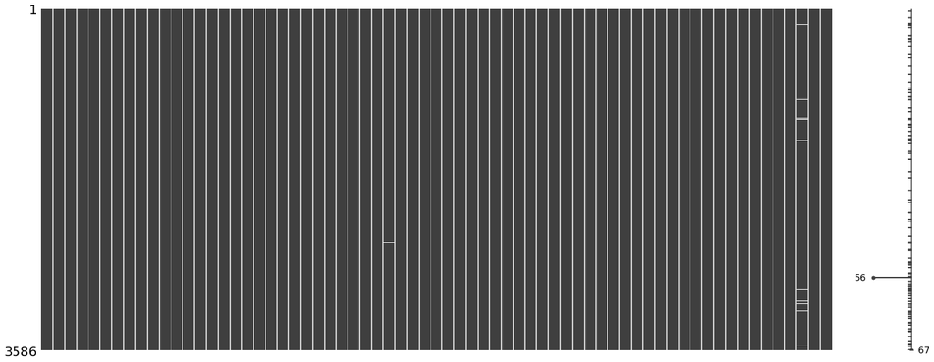

```python
import missingno as msno
msno.matrix(df)
```

```python
pd.set_option('display.max_rows', 500)
```

```python
df.isna().sum().sort_values(ascending=False)
```

```
Inventory_Vel_Days                   103
Book_Value_Adj_Unit_Curr               4
Inventory_Ratio_Latest                 1
Interest_Cover_Ratio_Latest            1
Curr_Ratio_Latest                      1
Fixed_Assets_Ratio_Latest              1
Debtors_Ratio_Latest                   1
Total_Asset_Turnover_Ratio_Latest      1
PBIDTM_perc_Latest                     1
PBITM_perc_Latest                      1
PBDTM_perc_Latest                      1
CPM_perc_Latest                        1
APATM_perc_Latest                      1
PBIT                                   0
Cost_of_Prod                           0
Value_Of_Output                        0
Selling_Cost                           0
PBIDT                                  0
PBDT                                   0
Value_of_Output_to_Gross_Block         0
PBT                                    0
PAT                                    0
Adjusted_PAT                           0
Net_Sales                              0
CP                                     0
Other_Income                           0
Gross_Block                            0
Gross_Sales                            0
Total_Assets_to_Liab                   0
Curr_Liab_and_Prov                     0
Curr_Assets                            0
Net_Working_Capital                    0
Rev_exp_in_forex                       0
Total_Debt                             0
Capital_Employed                       0
Networth                               0
Equity_Paid_Up                         0
Networth_Next_Year                     0
Co_Name                                0
Rev_earn_in_forex                      0
```

[output cut: 13 more lines]

```
ROG_PBIDT_perc                         0
ROG_Total_Assets_perc                  0
ROG_Cost_of_Prod_perc                  0
ROG_Net_Sales_perc                     0
ROG_Gross_Sales_perc                   0
ROG_Gross_Block_perc                   0
ROG_Capital_Employed_perc              0
ROG_Net_Worth_perc                     0
Cash_Flow_From_Fin                     0
Value_of_Output_to_Total_Assets        0
Cash_Flow_From_Opr                     0
CEPS_annualised_Unit_Curr              0
Market_Capitalisation                  0
Co_Code                                0
dtype: int64
```

```python
df.isna().sum()
```

```
Co_Code                                0
Co_Name                                0
Networth_Next_Year                     0
Equity_Paid_Up                         0
Networth                               0
Capital_Employed                       0
Total_Debt                             0
Gross_Block                            0
Net_Working_Capital                    0
Curr_Assets                            0
Curr_Liab_and_Prov                     0
Total_Assets_to_Liab                   0
Gross_Sales                            0
Net_Sales                              0
Other_Income                           0
Value_Of_Output                        0
Cost_of_Prod                           0
Selling_Cost                           0
PBIDT                                  0
PBDT                                   0
PBIT                                   0
PBT                                    0
PAT                                    0
Adjusted_PAT                           0
CP                                     0
Rev_earn_in_forex                      0
Rev_exp_in_forex                       0
Capital_exp_in_forex                   0
Book_Value_Unit_Curr                   0
Book_Value_Adj_Unit_Curr               4
Market_Capitalisation                  0
CEPS_annualised_Unit_Curr              0
Cash_Flow_From_Opr                     0
Cash_Flow_From_Inv                     0
Cash_Flow_From_Fin                     0
ROG_Net_Worth_perc                     0
ROG_Capital_Employed_perc              0
ROG_Gross_Block_perc                   0
ROG_Gross_Sales_perc                   0
ROG_Net_Sales_perc                     0
```

[output cut: 13 more lines]

```
Inventory_Ratio_Latest                 1
Debtors_Ratio_Latest                   1
Total_Asset_Turnover_Ratio_Latest      1
Interest_Cover_Ratio_Latest            1
PBIDTM_perc_Latest                     1
PBITM_perc_Latest                      1
PBDTM_perc_Latest                      1
CPM_perc_Latest                        1
APATM_perc_Latest                      1
Debtors_Vel_Days                       0
Creditors_Vel_Days                     0
Inventory_Vel_Days                   103
Value_of_Output_to_Total_Assets        0
Value_of_Output_to_Gross_Block         0
dtype: int64
```

```python
df.isna().sum().sum()
```

```
118
```

```python
df.shape
```

```
(3586, 67)
```

```python
df.dropna().shape
```

```
(3478, 67)
```

### Treating missing values in Inventory_Vel_Days variable

```python
df['Inventory_Vel_Days'].fillna(df['Inventory_Vel_Days'].mean(), inplace = True)
```

```python
df.isna().sum().sum()
```

```
15
```

### Dropping rows with missing values after fixing Inventory_Vel_Days variable

```python
df=df.dropna()
```

```python
df.shape
```

```
(3581, 67)
```

```python
df.isna().sum().sum()
```

```
0
```

## Checking for duplicate data

```python
df.duplicated().sum()
```

```
0
```

## Dropping unrequired columns

```python
df = df.drop(['Co_Code', 'Co_Name'], axis = 1)
df.head()
```

|  | Networth_Next_Year | Equity_Paid_Up | Networth | Capital_Employed | Total_Debt | Gross_Block | Net_Working_Capital | Curr_Assets | Curr_Liab_and_Prov | Total_Assets_to_Liab | ... | PBIDTM_perc_Latest | PBITM_perc_Latest | PBDTM_perc_Latest | CPM_perc_Latest | APATM_perc_Latest | Debtors_Vel_Days | Creditors_Vel_Days | Inventory_Vel_Days | Value_of_Output_to_Total_Assets | Value_of_Output_to_Gross_Block |
| --- | --- | --- | --- | --- | --- | --- | --- | --- | --- | --- | --- | --- | --- | --- | --- | --- | --- | --- | --- | --- | --- |
| 0 | -8021.60 | 419.36 | -7027.48 | -1007.24 | 5936.03 | 474.30 | -1076.34 | 40.50 | 1116.85 | 109.60 | ... | 0.00 | 0.00 | 0.00 | 0.00 | 0.00 | 0 | 0 | 45.0 | 0.00 | 0.00 |
| 1 | -3986.19 | 1954.93 | -2968.08 | 4458.20 | 7410.18 | 9070.86 | -1098.88 | 486.86 | 1585.74 | 6043.94 | ... | -10.30 | -39.74 | -57.74 | -57.74 | -87.18 | 29 | 101 | 2.0 | 0.31 | 0.24 |
| 2 | -3192.58 | 53.84 | 506.86 | 7714.68 | 6944.54 | 1281.54 | 4496.25 | 9097.64 | 4601.39 | 12316.07 | ... | -5279.14 | -5516.98 | -7780.25 | -7723.67 | -7961.51 | 97 | 558 | 0.0 | -0.03 | -0.26 |
| 3 | -3054.51 | 157.30 | -623.49 | 2353.88 | 2326.05 | 1033.69 | -2612.42 | 1034.12 | 3646.54 | 6000.42 | ... | -3.33 | -7.21 | -48.13 | -47.70 | -51.58 | 93 | 63 | 2.0 | 0.24 | 1.90 |
| 4 | -2967.36 | 50.30 | -1070.83 | 4675.33 | 5740.90 | 1084.20 | 1836.23 | 4685.81 | 2849.58 | 7524.91 | ... | -295.55 | -400.55 | -845.88 | 379.79 | 274.79 | 3887 | 346 | 0.0 | 0.01 | 0.05 |

5 rows × 65 columns

## Checking distribution of all variables

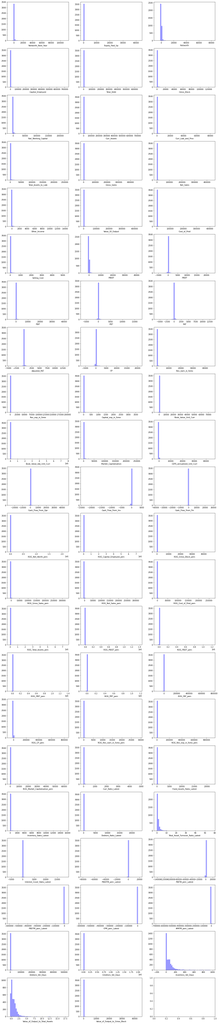

```python
fig, ax = plt.subplots(figsize = (20, 100), nrows = 22, ncols = 3)

for i, col in enumerate(df.columns):
        sns.distplot(df[col], ax = ax[i//3, i%3], kde = False, color = 'blue')
```

## Checking skewness in the data

```python
pd.DataFrame(df.skew().sort_values(ascending=False),columns=['Skewness'])
```

|  | Skewness |
| --- | --- |
| Book_Value_Adj_Unit_Curr | 59.835459 |
| ROG_PBIT_perc | 58.884442 |
| ROG_PBIDT_perc | 58.839674 |
| ROG_PBDT_perc | 58.366940 |
| ROG_PBT_perc | 57.292161 |
| ROG_Market_Capitalisation_perc | 57.290651 |
| ROG_Total_Assets_perc | 57.264557 |
| ROG_Rev_exp_in_forex_perc | 56.767771 |
| ROG_CP_perc | 56.749344 |
| ROG_Capital_Employed_perc | 56.397091 |
| ROG_PAT_perc | 52.606895 |
| CEPS_annualised_Unit_Curr | 48.499662 |
| Equity_Paid_Up | 45.897050 |
| ROG_Net_Sales_perc | 45.373973 |
| ROG_Gross_Sales_perc | 45.373047 |
| ROG_Gross_Block_perc | 44.839948 |
| ROG_Net_Worth_perc | 44.800706 |
| Interest_Cover_Ratio_Latest | 40.801193 |
| Debtors_Vel_Days | 38.633905 |
| ROG_Cost_of_Prod_perc | 37.243494 |
| Debtors_Ratio_Latest | 35.236850 |
| Rev_exp_in_forex | 34.817286 |
| Cost_of_Prod | 34.564594 |
| Creditors_Vel_Days | 34.097478 |
| Book_Value_Unit_Curr | 32.961635 |
| Value_of_Output_to_Gross_Block | 31.976222 |
| Gross_Sales | 31.538417 |
| Curr_Ratio_Latest | 31.264765 |
| Net_Sales | 31.063594 |
| ROG_Rev_earn_in_forex_perc | 31.030547 |
| Value_Of_Output | 30.790974 |
| Net_Working_Capital | 30.559236 |
| Capital_exp_in_forex | 27.591003 |
| Inventory_Ratio_Latest | 26.987799 |
| Rev_earn_in_forex | 24.159618 |
| Fixed_Assets_Ratio_Latest | 24.109628 |
| Curr_Assets | 20.764954 |
| Total_Debt | 19.404026 |
| Selling_Cost | 18.865968 |
| Other_Income | 18.792561 |
| Gross_Block | 18.515689 |
| Capital_Employed | 18.061056 |
| Curr_Liab_and_Prov | 15.280793 |
| Market_Capitalisation | 14.381041 |
| CP | 14.335178 |
| PBIT | 13.999627 |
| Adjusted_PAT | 13.865880 |
| PBDT | 13.545492 |
| Total_Assets_to_Liab | 13.358549 |
| PBIDT | 13.169771 |
| PBT | 13.118280 |
| PAT | 13.058587 |
| Networth_Next_Year | 13.032120 |
| Networth | 11.730548 |
| Total_Asset_Turnover_Ratio_Latest | 10.354365 |
| Cash_Flow_From_Opr | 6.630075 |
| Value_of_Output_to_Total_Assets | 4.708705 |
| Inventory_Vel_Days | 3.547576 |
| Cash_Flow_From_Fin | 1.702510 |
| Cash_Flow_From_Inv | -21.550029 |
| PBIDTM_perc_Latest | -30.914273 |
| PBITM_perc_Latest | -35.977753 |
| CPM_perc_Latest | -46.985387 |
| PBDTM_perc_Latest | -47.723669 |
| APATM_perc_Latest | -49.249980 |

## Outlier Analysis

```python
#outlier analysis

q1 = df.quantile(0.25)
q3 = df.quantile(0.75)
med = df.median()
IQR = q3 - q1

#checking extreme outliers (3x)
upper_limit = q3 + (3 * IQR)
lower_limit = q1 - (3 * IQR)
```

### What percent of values in each column are outliers

```python
((df > upper_limit).sum()/len(df)*100).sort_values(ascending=False)
```

```
ROG_Rev_exp_in_forex_perc            22.926557
Capital_exp_in_forex                 19.380061
ROG_Rev_earn_in_forex_perc           17.900028
Rev_earn_in_forex                    17.648701
Rev_exp_in_forex                     16.727171
PAT                                  14.884111
Market_Capitalisation                14.744485
PBT                                  14.688634
Adjusted_PAT                         14.632784
CP                                   14.325607
PBDT                                 14.074281
PBIT                                 13.683329
PBIDT                                13.655404
Selling_Cost                         13.292376
Other_Income                         13.236526
Cash_Flow_From_Opr                   13.068975
Networth_Next_Year                   13.041050
Total_Debt                           12.901424
Networth                             12.566322
Capital_Employed                     12.538397
Curr_Ratio_Latest                    12.510472
Curr_Liab_and_Prov                   12.259145
Curr_Assets                          12.007819
Total_Assets_to_Liab                 11.979894
Value_Of_Output                      11.616867
Gross_Sales                          11.616867
Net_Sales                            11.533091
Cost_of_Prod                         11.281765
Interest_Cover_Ratio_Latest          11.253840
Net_Working_Capital                  11.253840
Gross_Block                          10.639486
Value_of_Output_to_Gross_Block       10.360235
Fixed_Assets_Ratio_Latest            10.276459
Equity_Paid_Up                        9.075677
ROG_Gross_Block_perc                  9.047752
CEPS_annualised_Unit_Curr             8.461324
ROG_Cost_of_Prod_perc                 8.433398
Cash_Flow_From_Fin                    7.958671
Creditors_Vel_Days                    7.735269
Debtors_Vel_Days                      7.707344
```

[output cut: 11 more lines]

```
ROG_PBIT_perc                         6.115610
ROG_Capital_Employed_perc             6.003910
ROG_PBDT_perc                         5.640882
ROG_CP_perc                           5.473331
CPM_perc_Latest                       5.445406
ROG_Total_Assets_perc                 5.333706
ROG_PAT_perc                          5.249930
PBDTM_perc_Latest                     5.222005
ROG_PBT_perc                          5.026529
Cash_Flow_From_Inv                    4.691427
PBIDTM_perc_Latest                    4.495951
Inventory_Vel_Days                    3.937448
Total_Asset_Turnover_Ratio_Latest     2.429489
Value_of_Output_to_Total_Assets       1.480034
dtype: float64
```

```python
((df < lower_limit).sum()/len(df)*100).sort_values(ascending=False)
```

```
ROG_Rev_exp_in_forex_perc            22.172577
ROG_Rev_earn_in_forex_perc           18.877409
Cash_Flow_From_Inv                   14.800335
Cash_Flow_From_Fin                   13.739179
APATM_perc_Latest                    11.309690
CPM_perc_Latest                       8.209997
PBDTM_perc_Latest                     7.595644
PBITM_perc_Latest                     7.176766
ROG_Gross_Block_perc                  7.092991
Adjusted_PAT                          6.785814
PAT                                   6.646188
ROG_Net_Worth_perc                    6.450712
ROG_PBT_perc                          6.087685
PBT                                   6.059760
ROG_PAT_perc                          5.836359
ROG_CP_perc                           5.585032
ROG_PBDT_perc                         5.473331
PBIDTM_perc_Latest                    5.110304
ROG_PBIT_perc                         4.691427
ROG_PBIDT_perc                        4.300475
Interest_Cover_Ratio_Latest           3.797822
PBDT                                  3.769897
CP                                    3.630271
Cash_Flow_From_Opr                    3.546495
ROG_Capital_Employed_perc             2.624965
ROG_Gross_Sales_perc                  2.261938
ROG_Net_Sales_perc                    2.234013
PBIT                                  2.122312
Net_Working_Capital                   1.787210
CEPS_annualised_Unit_Curr             1.703435
ROG_Total_Assets_perc                 1.452108
PBIDT                                 1.396258
Networth_Next_Year                    1.172857
ROG_Cost_of_Prod_perc                 0.977381
Networth                              0.837755
Book_Value_Adj_Unit_Curr              0.781904
Book_Value_Unit_Curr                  0.670204
Capital_Employed                      0.055850
Value_of_Output_to_Gross_Block        0.055850
Other_Income                          0.027925
```

[output cut: 11 more lines]

```
Cost_of_Prod                          0.000000
Creditors_Vel_Days                    0.000000
Debtors_Vel_Days                      0.000000
Total_Asset_Turnover_Ratio_Latest     0.000000
Debtors_Ratio_Latest                  0.000000
Inventory_Ratio_Latest                0.000000
Fixed_Assets_Ratio_Latest             0.000000
Curr_Ratio_Latest                     0.000000
Rev_earn_in_forex                     0.000000
Rev_exp_in_forex                      0.000000
Capital_exp_in_forex                  0.000000
Market_Capitalisation                 0.000000
ROG_Market_Capitalisation_perc        0.000000
Selling_Cost                          0.000000
dtype: float64
```

```python
(((df>upper_limit).sum()+(df<lower_limit).sum())/len(df)*100).sort_values(ascending=False)
```

```
ROG_Rev_exp_in_forex_perc            45.099134
ROG_Rev_earn_in_forex_perc           36.777436
Cash_Flow_From_Fin                   21.697850
PAT                                  21.530299
Adjusted_PAT                         21.418598
PBT                                  20.748394
Cash_Flow_From_Inv                   19.491762
Capital_exp_in_forex                 19.380061
APATM_perc_Latest                    18.458531
CP                                   17.955878
PBDT                                 17.844178
Rev_earn_in_forex                    17.648701
Rev_exp_in_forex                     16.727171
Cash_Flow_From_Opr                   16.615471
ROG_Gross_Block_perc                 16.140743
PBIT                                 15.805641
Interest_Cover_Ratio_Latest          15.051662
PBIDT                                15.051662
Market_Capitalisation                14.744485
Networth_Next_Year                   14.213907
ROG_Net_Worth_perc                   13.962580
PBITM_perc_Latest                    13.767104
CPM_perc_Latest                      13.655404
Networth                             13.404077
Selling_Cost                         13.292376
Other_Income                         13.264451
Net_Working_Capital                  13.041050
Total_Debt                           12.901424
PBDTM_perc_Latest                    12.817649
Capital_Employed                     12.594247
Curr_Ratio_Latest                    12.510472
Curr_Liab_and_Prov                   12.259145
Curr_Assets                          12.007819
Total_Assets_to_Liab                 11.979894
Gross_Sales                          11.616867
Value_Of_Output                      11.616867
Net_Sales                            11.533091
Cost_of_Prod                         11.281765
ROG_PBDT_perc                        11.114214
ROG_PBT_perc                         11.114214
```

[output cut: 11 more lines]

```
ROG_Cost_of_Prod_perc                 9.410779
Equity_Paid_Up                        9.075677
ROG_Capital_Employed_perc             8.628875
Book_Value_Unit_Curr                  8.126222
Book_Value_Adj_Unit_Curr              7.846970
Creditors_Vel_Days                    7.735269
Debtors_Vel_Days                      7.707344
Inventory_Ratio_Latest                6.925440
ROG_Market_Capitalisation_perc        6.841664
ROG_Total_Assets_perc                 6.785814
Debtors_Ratio_Latest                  6.478637
Inventory_Vel_Days                    3.937448
Total_Asset_Turnover_Ratio_Latest     2.429489
Value_of_Output_to_Total_Assets       1.480034
dtype: float64
```

## Since there are a significant number of records which are outliers, it will change the essence of the data, if we treat outliers. Also the outliers are present due to the nature of the data which comprises small as well as big companies, hence the disparity

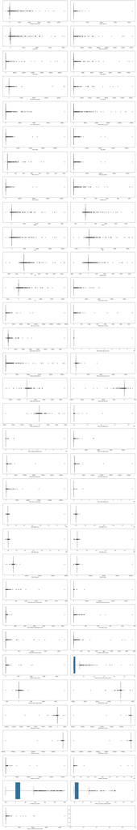

```python
#boxplots with extreme whiskers (+/- 3*IQR)

fig, ax = plt.subplots(figsize = (20, 120), nrows = 33, ncols = 2)

for i, col in enumerate(df.columns):
    sns.boxplot(x = df[col], ax = ax[i//2, i%2], whis = 3) #extreme whiskers

plt.tight_layout(pad = 1.1)
```

## Heatmap

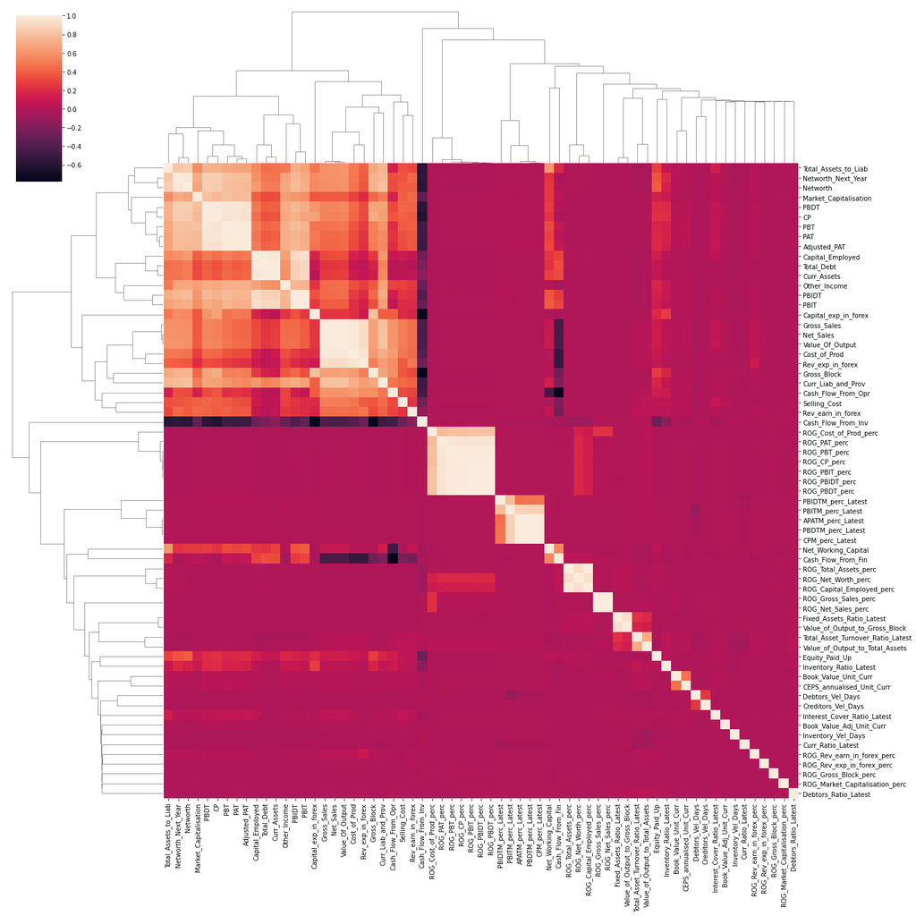

```python
sns.clustermap(df.corr(),figsize=(20,20))
```

## Analysing Networth_Next_Year variable, since on the basis of this variable we will define the dependent variable

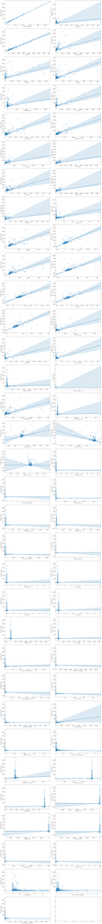

```python
fig, ax = plt.subplots(figsize = (20, 180), nrows = 33, ncols = 2)

for i, col in enumerate(df.columns):
    sns.regplot(x = df[col], y = df['Networth_Next_Year'], ax = ax[i//2, i%2])

plt.tight_layout(pad = 1.1)
```

## Making the dependent Variable

```python
df['Default']=np.where(df['Networth_Next_Year']<0,1,0)
```

```python
df.head()
```

|  | Networth_Next_Year | Equity_Paid_Up | Networth | Capital_Employed | Total_Debt | Gross_Block | Net_Working_Capital | Curr_Assets | Curr_Liab_and_Prov | Total_Assets_to_Liab | ... | PBITM_perc_Latest | PBDTM_perc_Latest | CPM_perc_Latest | APATM_perc_Latest | Debtors_Vel_Days | Creditors_Vel_Days | Inventory_Vel_Days | Value_of_Output_to_Total_Assets | Value_of_Output_to_Gross_Block | Default |
| --- | --- | --- | --- | --- | --- | --- | --- | --- | --- | --- | --- | --- | --- | --- | --- | --- | --- | --- | --- | --- | --- |
| 0 | -8021.60 | 419.36 | -7027.48 | -1007.24 | 5936.03 | 474.30 | -1076.34 | 40.50 | 1116.85 | 109.60 | ... | 0.00 | 0.00 | 0.00 | 0.00 | 0 | 0 | 45.0 | 0.00 | 0.00 | 1 |
| 1 | -3986.19 | 1954.93 | -2968.08 | 4458.20 | 7410.18 | 9070.86 | -1098.88 | 486.86 | 1585.74 | 6043.94 | ... | -39.74 | -57.74 | -57.74 | -87.18 | 29 | 101 | 2.0 | 0.31 | 0.24 | 1 |
| 2 | -3192.58 | 53.84 | 506.86 | 7714.68 | 6944.54 | 1281.54 | 4496.25 | 9097.64 | 4601.39 | 12316.07 | ... | -5516.98 | -7780.25 | -7723.67 | -7961.51 | 97 | 558 | 0.0 | -0.03 | -0.26 | 1 |
| 3 | -3054.51 | 157.30 | -623.49 | 2353.88 | 2326.05 | 1033.69 | -2612.42 | 1034.12 | 3646.54 | 6000.42 | ... | -7.21 | -48.13 | -47.70 | -51.58 | 93 | 63 | 2.0 | 0.24 | 1.90 | 1 |
| 4 | -2967.36 | 50.30 | -1070.83 | 4675.33 | 5740.90 | 1084.20 | 1836.23 | 4685.81 | 2849.58 | 7524.91 | ... | -400.55 | -845.88 | 379.79 | 274.79 | 3887 | 346 | 0.0 | 0.01 | 0.05 | 1 |

5 rows × 66 columns

## Converting to X and y

```python
X = df.drop('Default', axis = 1)
y = df['Default']
```

## Feature Selection

Since there are too many columns, we need to determine the columns which are related and eliminate them if possible. We will use VIF to determine the collinearity and eliminate using a threshold of 5.

```python
#vif calculation

def calculate_vif_(X, thresh = 5):
    cols = X.columns
    variables = np.arange(X.shape[1])
    dropped=True
    while dropped:
        dropped=False
        c = X[cols[variables]].values
        vif = [variance_inflation_factor(c, ix) for ix in np.arange(c.shape[1])]

        maxloc = vif.index(max(vif))
        if max(vif) > thresh:
            print('dropping \'' + X[cols[variables]].columns[maxloc] + '\' at index: ' + str(maxloc))
            variables = np.delete(variables, maxloc)
            dropped=True


    print('Remaining variables:')
    print(X.columns[variables])
    return X[cols[variables]]
```

```python
X=calculate_vif_(X,5)
```

```
dropping 'PBIDT' at index: 16
dropping 'PBDT' at index: 16
dropping 'APATM_perc_Latest' at index: 57
dropping 'ROG_Gross_Sales_perc' at index: 34
dropping 'Net_Sales' at index: 11
dropping 'PBDTM_perc_Latest' at index: 53
dropping 'Value_Of_Output' at index: 12
dropping 'ROG_Total_Assets_perc' at index: 34
dropping 'Capital_Employed' at index: 3
dropping 'Gross_Sales' at index: 9
dropping 'Total_Debt' at index: 3
dropping 'ROG_PBDT_perc' at index: 32
dropping 'ROG_PBIT_perc' at index: 32
dropping 'CP' at index: 15
dropping 'PAT' at index: 13
dropping 'ROG_PBIDT_perc' at index: 29
dropping 'Total_Assets_to_Liab' at index: 7
dropping 'ROG_PBT_perc' at index: 28
dropping 'PBT' at index: 11
dropping 'PBIT' at index: 10
dropping 'Cost_of_Prod' at index: 8
dropping 'Networth' at index: 2
dropping 'PBITM_perc_Latest' at index: 36
dropping 'ROG_CP_perc' at index: 25
dropping 'Cash_Flow_From_Fin' at index: 18
dropping 'ROG_Net_Worth_perc' at index: 18
dropping 'Gross_Block' at index: 2
dropping 'Fixed_Assets_Ratio_Latest' at index: 26
dropping 'Curr_Liab_and_Prov' at index: 4
dropping 'Networth_Next_Year' at index: 0
dropping 'Adjusted_PAT' at index: 5
Remaining variables:
Index(['Equity_Paid_Up', 'Net_Working_Capital', 'Curr_Assets', 'Other_Income',
       'Selling_Cost', 'Rev_earn_in_forex', 'Rev_exp_in_forex',
       'Capital_exp_in_forex', 'Book_Value_Unit_Curr',
       'Book_Value_Adj_Unit_Curr', 'Market_Capitalisation',
       'CEPS_annualised_Unit_Curr', 'Cash_Flow_From_Opr', 'Cash_Flow_From_Inv',
       'ROG_Capital_Employed_perc', 'ROG_Gross_Block_perc',
       'ROG_Net_Sales_perc', 'ROG_Cost_of_Prod_perc', 'ROG_PAT_perc',
       'ROG_Rev_earn_in_forex_perc', 'ROG_Rev_exp_in_forex_perc',
       'ROG_Market_Capitalisation_perc', 'Curr_Ratio_Latest',
       'Inventory_Ratio_Latest', 'Debtors_Ratio_Latest',
       'Total_Asset_Turnover_Ratio_Latest', 'Interest_Cover_Ratio_Latest',
       'PBIDTM_perc_Latest', 'CPM_perc_Latest', 'Debtors_Vel_Days',
       'Creditors_Vel_Days', 'Inventory_Vel_Days',
       'Value_of_Output_to_Total_Assets', 'Value_of_Output_to_Gross_Block'],
      dtype='object')
```

```python
X
```

|  | Equity_Paid_Up | Net_Working_Capital | Curr_Assets | Other_Income | Selling_Cost | Rev_earn_in_forex | Rev_exp_in_forex | Capital_exp_in_forex | Book_Value_Unit_Curr | Book_Value_Adj_Unit_Curr | ... | Debtors_Ratio_Latest | Total_Asset_Turnover_Ratio_Latest | Interest_Cover_Ratio_Latest | PBIDTM_perc_Latest | CPM_perc_Latest | Debtors_Vel_Days | Creditors_Vel_Days | Inventory_Vel_Days | Value_of_Output_to_Total_Assets | Value_of_Output_to_Gross_Block |
| --- | --- | --- | --- | --- | --- | --- | --- | --- | --- | --- | --- | --- | --- | --- | --- | --- | --- | --- | --- | --- | --- |
| 0 | 419.36 | -1076.34 | 40.50 | 7.60 | 0.00 | 0.00 | 0.00 | 0.00 | -167.58 | -167.58 | ... | 0.00 | 0.00 | -0.20 | 0.00 | 0.00 | 0 | 0 | 45.000000 | 0.00 | 0.00 |
| 1 | 1954.93 | -1098.88 | 486.86 | 46.27 | 40.51 | 6.35 | 143.42 | 141.17 | -15.18 | -15.18 | ... | 10.35 | 0.30 | -0.84 | -10.30 | -57.74 | 29 | 101 | 2.000000 | 0.31 | 0.24 |
| 2 | 53.84 | 4496.25 | 9097.64 | 9.55 | 54.83 | 0.00 | 86.36 | 2.27 | 94.14 | 94.14 | ... | 0.42 | 0.00 | -2.21 | -5279.14 | -7723.67 | 97 | 558 | 0.000000 | -0.03 | -0.26 |
| 3 | 157.30 | -2612.42 | 1034.12 | 223.85 | 3.34 | 0.89 | 28.88 | 0.00 | -39.64 | -39.64 | ... | 9.26 | 0.00 | -0.16 | -3.33 | -47.70 | 93 | 63 | 2.000000 | 0.24 | 1.90 |
| 4 | 50.30 | 1836.23 | 4685.81 | 9.82 | 1.97 | 0.00 | 15.62 | 0.00 | -212.89 | -212.89 | ... | 1.28 | 0.01 | -0.73 | -295.55 | 379.79 | 3887 | 346 | 0.000000 | 0.01 | 0.05 |
| ... | ... | ... | ... | ... | ... | ... | ... | ... | ... | ... | ... | ... | ... | ... | ... | ... | ... | ... | ... | ... | ... |
| 3581 | 501.30 | 0.00 | 444633.50 | 8996.35 | 187.47 | 0.00 | 0.00 | 0.00 | 247.39 | 247.39 | ... | 0.00 | 0.00 | 0.00 | 0.00 | 0.00 | 0 | 0 | 79.644559 | 0.60 | 7.76 |
| 3582 | 296.50 | 2503.86 | 11554.45 | 2008.86 | 249.20 | 14429.18 | 19525.06 | 11.30 | 114.87 | 114.87 | ... | 22.31 | 0.30 | 3.18 | 39.92 | 30.52 | 13 | 53 | 77.000000 | 0.29 | 1.00 |
| 3583 | 2427.95 | 6376.84 | 89609.82 | 5815.66 | 686.53 | 16009.99 | 193979.73 | 294.88 | 279.95 | 69.99 | ... | 55.49 | 2.62 | 8.60 | 8.09 | 5.69 | 7 | 30 | 48.000000 | 1.42 | 3.24 |
| 3584 | 8245.46 | 11449.79 | 42353.59 | 2399.39 | 71.22 | 3.41 | 962.27 | 2788.44 | 99.03 | 99.03 | ... | 9.86 | 0.39 | 4.35 | 28.12 | 19.55 | 32 | 69 | 42.000000 | 0.36 | 0.68 |
| 3585 | 1998.70 | -12145.30 | 11947.10 | 5193.00 | 1555.50 | 3727.40 | 3017.20 | 3722.10 | 195.80 | 195.80 | ... | 19.51 | 0.38 | 2.71 | 42.47 | 25.97 | 18 | 74 | 0.000000 | 0.42 | 0.49 |

3581 rows × 34 columns

```python
df_new=pd.concat([X,y],axis=1)
```

```python
df_new
```

|  | Equity_Paid_Up | Net_Working_Capital | Curr_Assets | Other_Income | Selling_Cost | Rev_earn_in_forex | Rev_exp_in_forex | Capital_exp_in_forex | Book_Value_Unit_Curr | Book_Value_Adj_Unit_Curr | ... | Total_Asset_Turnover_Ratio_Latest | Interest_Cover_Ratio_Latest | PBIDTM_perc_Latest | CPM_perc_Latest | Debtors_Vel_Days | Creditors_Vel_Days | Inventory_Vel_Days | Value_of_Output_to_Total_Assets | Value_of_Output_to_Gross_Block | Default |
| --- | --- | --- | --- | --- | --- | --- | --- | --- | --- | --- | --- | --- | --- | --- | --- | --- | --- | --- | --- | --- | --- |
| 0 | 419.36 | -1076.34 | 40.50 | 7.60 | 0.00 | 0.00 | 0.00 | 0.00 | -167.58 | -167.58 | ... | 0.00 | -0.20 | 0.00 | 0.00 | 0 | 0 | 45.000000 | 0.00 | 0.00 | 1 |
| 1 | 1954.93 | -1098.88 | 486.86 | 46.27 | 40.51 | 6.35 | 143.42 | 141.17 | -15.18 | -15.18 | ... | 0.30 | -0.84 | -10.30 | -57.74 | 29 | 101 | 2.000000 | 0.31 | 0.24 | 1 |
| 2 | 53.84 | 4496.25 | 9097.64 | 9.55 | 54.83 | 0.00 | 86.36 | 2.27 | 94.14 | 94.14 | ... | 0.00 | -2.21 | -5279.14 | -7723.67 | 97 | 558 | 0.000000 | -0.03 | -0.26 | 1 |
| 3 | 157.30 | -2612.42 | 1034.12 | 223.85 | 3.34 | 0.89 | 28.88 | 0.00 | -39.64 | -39.64 | ... | 0.00 | -0.16 | -3.33 | -47.70 | 93 | 63 | 2.000000 | 0.24 | 1.90 | 1 |
| 4 | 50.30 | 1836.23 | 4685.81 | 9.82 | 1.97 | 0.00 | 15.62 | 0.00 | -212.89 | -212.89 | ... | 0.01 | -0.73 | -295.55 | 379.79 | 3887 | 346 | 0.000000 | 0.01 | 0.05 | 1 |
| ... | ... | ... | ... | ... | ... | ... | ... | ... | ... | ... | ... | ... | ... | ... | ... | ... | ... | ... | ... | ... | ... |
| 3581 | 501.30 | 0.00 | 444633.50 | 8996.35 | 187.47 | 0.00 | 0.00 | 0.00 | 247.39 | 247.39 | ... | 0.00 | 0.00 | 0.00 | 0.00 | 0 | 0 | 79.644559 | 0.60 | 7.76 | 0 |
| 3582 | 296.50 | 2503.86 | 11554.45 | 2008.86 | 249.20 | 14429.18 | 19525.06 | 11.30 | 114.87 | 114.87 | ... | 0.30 | 3.18 | 39.92 | 30.52 | 13 | 53 | 77.000000 | 0.29 | 1.00 | 0 |
| 3583 | 2427.95 | 6376.84 | 89609.82 | 5815.66 | 686.53 | 16009.99 | 193979.73 | 294.88 | 279.95 | 69.99 | ... | 2.62 | 8.60 | 8.09 | 5.69 | 7 | 30 | 48.000000 | 1.42 | 3.24 | 0 |
| 3584 | 8245.46 | 11449.79 | 42353.59 | 2399.39 | 71.22 | 3.41 | 962.27 | 2788.44 | 99.03 | 99.03 | ... | 0.39 | 4.35 | 28.12 | 19.55 | 32 | 69 | 42.000000 | 0.36 | 0.68 | 0 |
| 3585 | 1998.70 | -12145.30 | 11947.10 | 5193.00 | 1555.50 | 3727.40 | 3017.20 | 3722.10 | 195.80 | 195.80 | ... | 0.38 | 2.71 | 42.47 | 25.97 | 18 | 74 | 0.000000 | 0.42 | 0.49 | 0 |

3581 rows × 35 columns

## Split of data based on Default Variable

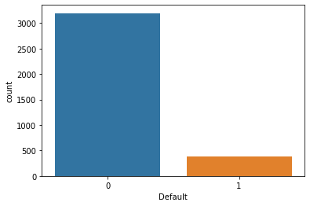

```python
sns.countplot(df_new['Default'])
```

```python
df_new['Default'].value_counts()
```

```
0    3195
1     386
Name: Default, dtype: int64
```

```python
df_new.groupby(df['Default']).sum()
```

| Default | Equity_Paid_Up | Net_Working_Capital | Curr_Assets | Other_Income | Selling_Cost | Rev_earn_in_forex | Rev_exp_in_forex | Capital_exp_in_forex | Book_Value_Unit_Curr | Book_Value_Adj_Unit_Curr | ... | Total_Asset_Turnover_Ratio_Latest | Interest_Cover_Ratio_Latest | PBIDTM_perc_Latest | CPM_perc_Latest | Debtors_Vel_Days | Creditors_Vel_Days | Inventory_Vel_Days | Value_of_Output_to_Total_Assets | Value_of_Output_to_Gross_Block | Default |
| --- | --- | --- | --- | --- | --- | --- | --- | --- | --- | --- | --- | --- | --- | --- | --- | --- | --- | --- | --- | --- | --- |
| 0 | 214218.10 | 1462147.61 | 6968115.21 | 171778.53 | 89962.39 | 464874.78 | 912428.20 | 27196.23 | 586861.65 | 8085269.63 | ... | 4034.82 | 68139.00 | -124454.16 | -463481.66 | 1982680 | 5105296 | 250651.944014 | 2753.69 | 220136.43 | 0 |
| 1 | 11418.37 | 10954.66 | 61538.31 | 2960.36 | 1662.93 | 5483.88 | 6760.43 | 257.07 | -23139.27 | -50382.12 | ... | 399.63 | -9387.15 | -58966.72 | -637120.30 | 182255 | 2260146 | 34512.445593 | 182.03 | 1773.34 | 386 |

2 rows × 35 columns

## Barplots

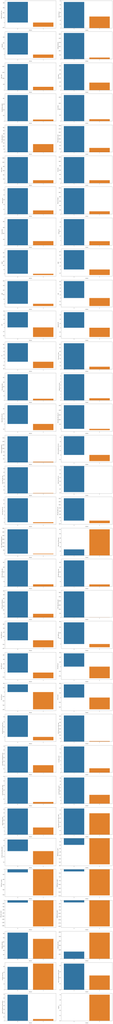

```python
fig, ax = plt.subplots(figsize = (20, 180), nrows = 33, ncols = 2)

for i, col in enumerate(df.columns):
    sns.barplot(x = df['Default'], y = df[col], ax = ax[i//2, i%2],ci=None)

plt.tight_layout(pad = 1.1)
```

## Since the data set is very imbalanced. We will apply SMOTE and then we will evaluate all models on both SMOTE as well as NON - SMOTE dataset and compare

```python
df_smote=df_new.copy()
```

```python
print("Before OverSampling the shape of X: {}".format(X.shape))
print("Before OverSampling the shape of y: {}".format(y.shape))

print("Before OverSampling, counts of label '1': {}".format(sum(y==1)))
print("Before OverSampling, counts of label '0': {} \n".format(sum(y==0)))
```

```
Before OverSampling the shape of X: (3581, 34)
Before OverSampling the shape of y: (3581,)
Before OverSampling, counts of label '1': 386
Before OverSampling, counts of label '0': 3195
```

```python
from imblearn.over_sampling import SMOTE
sm = SMOTE(random_state=33)
```

```python
X_smote,y_smote=sm.fit_sample(X,y.ravel())
```

```python
print("After OverSampling the shape of X: {}".format(X_smote.shape))
print("After OverSampling the shape of y: {}".format(y_smote.shape))

print("After OverSampling, counts of label '1': {}".format(sum(y_smote==1)))
print("After OverSampling, counts of label '0': {} \n".format(sum(y_smote==0)))
```

```
After OverSampling the shape of X: (6390, 34)
After OverSampling the shape of y: (6390,)
After OverSampling, counts of label '1': 3195
After OverSampling, counts of label '0': 3195
```

```python
X_train, X_test, y_train, y_test = train_test_split(X, y, test_size = 0.33, random_state = 42, stratify = y)
```

```python
X_train_smote, X_test_smote, y_train_smote, y_test_smote = train_test_split(
    X_smote, y_smote, test_size = 0.33, random_state = 42, stratify = y_smote)
```

## Concatinating X and y, so they can be used with statsmodel library

```python
df_train = pd.concat([X_train, y_train], axis = 1)
df_test = pd.concat([X_test, y_test], axis = 1)
```

```python
df_train
```

|  | Equity_Paid_Up | Net_Working_Capital | Curr_Assets | Other_Income | Selling_Cost | Rev_earn_in_forex | Rev_exp_in_forex | Capital_exp_in_forex | Book_Value_Unit_Curr | Book_Value_Adj_Unit_Curr | ... | Total_Asset_Turnover_Ratio_Latest | Interest_Cover_Ratio_Latest | PBIDTM_perc_Latest | CPM_perc_Latest | Debtors_Vel_Days | Creditors_Vel_Days | Inventory_Vel_Days | Value_of_Output_to_Total_Assets | Value_of_Output_to_Gross_Block | Default |
| --- | --- | --- | --- | --- | --- | --- | --- | --- | --- | --- | --- | --- | --- | --- | --- | --- | --- | --- | --- | --- | --- |
| 2218 | 3.06 | 40.94 | 66.67 | 0.25 | 7.65 | 23.25 | 23.34 | 4.82 | 132.56 | 132.56 | ... | 1.02 | 1.13 | 12.62 | 9.21 | 119 | 37 | 108.0 | 0.85 | 0.70 | 0 |
| 498 | 5.10 | 0.39 | 10.15 | 1.08 | 0.01 | 0.00 | 0.10 | 0.00 | 1.24 | 1.24 | ... | 2.81 | 2.24 | 3.60 | 2.28 | 2023 | 1179 | 0.0 | 1.13 | 2.55 | 0 |
| 1154 | 5.26 | 8.87 | 12.57 | 0.04 | 0.00 | 0.00 | 4.95 | 0.00 | 12.07 | 12.07 | ... | 3.54 | 1.29 | 2.84 | 0.82 | 53 | 19 | 8.0 | 3.28 | 18.12 | 0 |
| 1348 | 6.25 | 7.51 | 12.64 | 0.02 | 2.14 | 0.00 | 0.00 | 0.00 | 13.20 | 13.20 | ... | 0.42 | 4.60 | 44.10 | 24.96 | 422 | 642 | 47.0 | 0.27 | 4.03 | 0 |
| 3540 | 289.37 | -892.08 | 3862.90 | 582.42 | 576.87 | 9443.51 | 830.61 | 25.47 | 369.50 | 369.50 | ... | 1.50 | 3812.16 | 24.45 | 17.91 | 12 | 40 | 16.0 | 1.22 | 5.07 | 0 |
| ... | ... | ... | ... | ... | ... | ... | ... | ... | ... | ... | ... | ... | ... | ... | ... | ... | ... | ... | ... | ... | ... |
| 463 | 5.25 | 74.68 | 117.52 | 0.12 | 0.21 | 0.00 | 0.00 | 0.00 | 0.71 | 0.71 | ... | 0.63 | 1.60 | 12.02 | 5.48 | 481 | 508 | 0.0 | 0.47 | 2.44 | 0 |
| 143 | 42.56 | 35.49 | 174.83 | 5.29 | 23.35 | 269.59 | 123.31 | 0.65 | -8.40 | -8.40 | ... | 5.23 | -0.44 | -1.26 | -5.11 | 41 | 30 | 58.0 | 1.81 | 1.87 | 1 |
| 1522 | 15.50 | 6.56 | 7.30 | 0.00 | 0.12 | 0.45 | 0.01 | 0.00 | 0.80 | 0.80 | ... | 0.13 | 0.00 | 8.12 | 8.97 | 601 | 12 | 629.0 | 0.15 | 0.08 | 0 |
| 14 | 67.27 | -197.77 | 131.31 | 8.45 | 0.21 | 0.00 | 0.34 | 0.00 | -119.54 | -119.54 | ... | 0.00 | -1.40 | -78.94 | -138.85 | 34 | 160 | 81.0 | 0.52 | 0.24 | 1 |
| 3139 | 17.47 | 501.78 | 1390.93 | 62.52 | 18.91 | 46.99 | 258.08 | 2.03 | 48.53 | 48.53 | ... | 0.67 | 0.10 | 9.61 | -1.92 | 67 | 87 | 112.0 | 0.48 | 0.62 | 0 |

2399 rows × 35 columns

```python
df_test
```

|  | Equity_Paid_Up | Net_Working_Capital | Curr_Assets | Other_Income | Selling_Cost | Rev_earn_in_forex | Rev_exp_in_forex | Capital_exp_in_forex | Book_Value_Unit_Curr | Book_Value_Adj_Unit_Curr | ... | Total_Asset_Turnover_Ratio_Latest | Interest_Cover_Ratio_Latest | PBIDTM_perc_Latest | CPM_perc_Latest | Debtors_Vel_Days | Creditors_Vel_Days | Inventory_Vel_Days | Value_of_Output_to_Total_Assets | Value_of_Output_to_Gross_Block | Default |
| --- | --- | --- | --- | --- | --- | --- | --- | --- | --- | --- | --- | --- | --- | --- | --- | --- | --- | --- | --- | --- | --- |
| 1682 | 11.75 | 3.01 | 3.38 | 0.62 | 0.15 | 0.00 | 0.00 | 0.00 | 13.30 | 13.30 | ... | 0.24 | 1.53 | 22.67 | 9.96 | 17 | 26 | 77.0 | 0.24 | 0.23 | 0 |
| 3260 | 25.98 | 478.87 | 855.19 | 28.00 | 83.82 | 1032.47 | 225.05 | 0.14 | 332.14 | 332.14 | ... | 0.82 | 5.28 | 33.27 | 21.13 | 15 | 58 | 150.0 | 0.68 | 1.16 | 0 |
| 2156 | 9.34 | 7.40 | 59.65 | 1.48 | 0.00 | 0.00 | 0.00 | 0.00 | 34.56 | 34.56 | ... | 1.55 | 2.47 | 10.54 | 5.93 | 39 | 116 | 99.0 | 1.18 | 2.39 | 0 |
| 3295 | 7.35 | 424.45 | 1960.66 | 42.31 | 267.03 | 1166.70 | 321.98 | 3.49 | 1046.88 | 1046.88 | ... | 2.08 | 7.84 | 10.53 | 7.27 | 94 | 110 | 58.0 | 1.04 | 3.63 | 0 |
| 1311 | 5.05 | 2.82 | 4.30 | 0.23 | 0.03 | 10.55 | 0.05 | 0.00 | 16.15 | 16.15 | ... | 1.31 | 3.74 | 8.52 | 5.51 | 98 | 5 | 0.0 | 1.20 | 1.56 | 0 |
| ... | ... | ... | ... | ... | ... | ... | ... | ... | ... | ... | ... | ... | ... | ... | ... | ... | ... | ... | ... | ... | ... |
| 2539 | 8.90 | 112.20 | 130.61 | 0.30 | 17.62 | 279.55 | 7.73 | 0.00 | 91.86 | 73.49 | ... | 3.66 | 2.09 | 5.40 | 2.94 | 44 | 6 | 34.0 | 3.18 | 4.76 | 0 |
| 451 | 0.35 | 0.02 | 0.06 | 0.00 | 0.01 | 0.00 | 0.00 | 0.00 | 0.94 | 0.94 | ... | 0.24 | 0.00 | 0.00 | 0.00 | 0 | 0 | 0.0 | 0.20 | 0.00 | 0 |
| 1058 | 3.69 | 2.52 | 2.72 | 0.23 | 0.03 | 1.41 | 0.01 | 0.00 | 10.67 | 10.67 | ... | 0.00 | 1.00 | 0.00 | 0.00 | 29 | 3 | 27.0 | 0.00 | 0.00 | 0 |
| 2378 | 5.29 | 49.48 | 153.78 | 3.82 | 53.80 | 30.19 | 6.28 | 0.00 | 111.42 | 111.42 | ... | 5.18 | 16.93 | 12.53 | 8.10 | 28 | 34 | 71.0 | 2.71 | 10.72 | 0 |
| 762 | 0.27 | 0.09 | 0.14 | 0.00 | 0.01 | 0.00 | 0.00 | 0.00 | 10.21 | 10.21 | ... | 0.11 | 0.00 | 0.00 | 0.00 | 365 | 1460 | 0.0 | 0.00 | 0.00 | 0 |

1182 rows × 35 columns

```python
df_train_smote = pd.concat([X_train_smote, pd.DataFrame(y_train_smote,index=X_train_smote.index)], axis = 1)
df_test_smote = pd.concat([X_test_smote, pd.DataFrame(y_test_smote,index=X_test_smote.index)], axis = 1)
```

```python
df_train_smote.columns=[                   'Equity_Paid_Up',
                     'Net_Working_Capital',
                             'Curr_Assets',
                            'Other_Income',
                            'Selling_Cost',
                       'Rev_earn_in_forex',
                        'Rev_exp_in_forex',
                    'Capital_exp_in_forex',
                    'Book_Value_Unit_Curr',
                'Book_Value_Adj_Unit_Curr',
                   'Market_Capitalisation',
               'CEPS_annualised_Unit_Curr',
                      'Cash_Flow_From_Opr',
                      'Cash_Flow_From_Inv',
               'ROG_Capital_Employed_perc',
                    'ROG_Gross_Block_perc',
                      'ROG_Net_Sales_perc',
                   'ROG_Cost_of_Prod_perc',
                            'ROG_PAT_perc',
              'ROG_Rev_earn_in_forex_perc',
               'ROG_Rev_exp_in_forex_perc',
          'ROG_Market_Capitalisation_perc',
                       'Curr_Ratio_Latest',
                  'Inventory_Ratio_Latest',
                    'Debtors_Ratio_Latest',
       'Total_Asset_Turnover_Ratio_Latest',
             'Interest_Cover_Ratio_Latest',
                      'PBIDTM_perc_Latest',
                         'CPM_perc_Latest',
                        'Debtors_Vel_Days',
                      'Creditors_Vel_Days',
                      'Inventory_Vel_Days',
         'Value_of_Output_to_Total_Assets',
          'Value_of_Output_to_Gross_Block',
                        'Default']
df_train_smote
```

|  | Equity_Paid_Up | Net_Working_Capital | Curr_Assets | Other_Income | Selling_Cost | Rev_earn_in_forex | Rev_exp_in_forex | Capital_exp_in_forex | Book_Value_Unit_Curr | Book_Value_Adj_Unit_Curr | ... | Total_Asset_Turnover_Ratio_Latest | Interest_Cover_Ratio_Latest | PBIDTM_perc_Latest | CPM_perc_Latest | Debtors_Vel_Days | Creditors_Vel_Days | Inventory_Vel_Days | Value_of_Output_to_Total_Assets | Value_of_Output_to_Gross_Block | Default |
| --- | --- | --- | --- | --- | --- | --- | --- | --- | --- | --- | --- | --- | --- | --- | --- | --- | --- | --- | --- | --- | --- |
| 4223 | 7.347672 | 7.020814 | 15.989639 | 5.816834 | 0.560601 | 6.752390 | 0.442210 | 0.000000 | -2.623808 | -2.623808 | ... | 1.204066 | 0.047095 | -17.784282 | -73.110859 | 66 | 37 | 112.552142 | 0.973436 | 0.745392 | 1 |
| 3493 | 58.010000 | 3321.460000 | 5247.240000 | 123.720000 | 376.330000 | 2110.860000 | 2560.660000 | 72.470000 | 194.310000 | 194.310000 | ... | 0.580000 | 2.240000 | 18.370000 | 9.220000 | 75 | 31 | 124.000000 | 0.580000 | 1.040000 | 0 |
| 2844 | 11.560000 | 135.650000 | 267.950000 | 3.250000 | 11.670000 | 95.910000 | 146.260000 | 2.890000 | 161.570000 | 80.790000 | ... | 4.350000 | 4.550000 | 5.480000 | 3.540000 | 58 | 55 | 39.000000 | 2.120000 | 3.420000 | 0 |
| 4221 | 8.509298 | 0.610611 | 1.269695 | 10.223334 | 0.010000 | 0.004309 | 0.008618 | 0.000000 | -0.634595 | -0.634595 | ... | 0.453878 | -1.723518 | 3.425494 | 3.425494 | 14 | 398 | 0.000000 | 0.359677 | 0.000000 | 1 |
| 5583 | 3.960926 | -12.222521 | 1.994483 | 0.000000 | 0.001584 | 0.000000 | 0.000000 | 0.000000 | -30.534538 | -30.534538 | ... | 0.000000 | 0.000000 | 0.000000 | 0.000000 | 0 | 0 | 0.000000 | 0.000000 | 0.000000 | 1 |
| ... | ... | ... | ... | ... | ... | ... | ... | ... | ... | ... | ... | ... | ... | ... | ... | ... | ... | ... | ... | ... | ... |
| 2037 | 5.590000 | 19.890000 | 28.630000 | 2.420000 | 1.310000 | 0.000000 | 0.000000 | 0.000000 | 50.670000 | 50.670000 | ... | 0.900000 | 3.150000 | 14.060000 | 8.670000 | 41 | 38 | 52.000000 | 0.950000 | 2.530000 | 0 |
| 1231 | 0.500000 | 5.660000 | 16.670000 | 0.020000 | 1.000000 | 0.000000 | 0.000000 | 0.000000 | 93.680000 | 31.230000 | ... | 4.190000 | 3.970000 | 7.880000 | 4.490000 | 58 | 5 | 0.000000 | 4.020000 | 12.010000 | 0 |
| 4528 | 38.063388 | 70.952532 | 109.997387 | 11.169226 | 2.001923 | 67.912435 | 5.000147 | 1.534478 | -23.234465 | -23.234465 | ... | 1.040901 | -19.118507 | -11.458420 | -13.064260 | 95 | 61 | 81.695859 | 0.841460 | 4.561193 | 1 |
| 3629 | 3.371029 | -0.013994 | 0.029000 | 0.084003 | 0.001999 | 0.000000 | 0.000000 | 0.000000 | -0.698709 | -0.698709 | ... | 0.000000 | 0.000000 | 0.000000 | 0.000000 | 0 | 12 | 0.000000 | 0.000000 | 0.000000 | 1 |
| 1428 | 9.660000 | 30.590000 | 30.810000 | 0.000000 | 0.010000 | 0.000000 | 0.000000 | 0.000000 | 1.070000 | 1.070000 | ... | 0.120000 | 1.090000 | 95.200000 | 5.760000 | 0 | 57 | 0.000000 | 0.190000 | 86.420000 | 0 |

4281 rows × 35 columns

```python
df_test_smote.columns=['Equity_Paid_Up',
                     'Net_Working_Capital',
                             'Curr_Assets',
                            'Other_Income',
                            'Selling_Cost',
                       'Rev_earn_in_forex',
                        'Rev_exp_in_forex',
                    'Capital_exp_in_forex',
                    'Book_Value_Unit_Curr',
                'Book_Value_Adj_Unit_Curr',
                   'Market_Capitalisation',
               'CEPS_annualised_Unit_Curr',
                      'Cash_Flow_From_Opr',
                      'Cash_Flow_From_Inv',
               'ROG_Capital_Employed_perc',
                    'ROG_Gross_Block_perc',
                      'ROG_Net_Sales_perc',
                   'ROG_Cost_of_Prod_perc',
                            'ROG_PAT_perc',
              'ROG_Rev_earn_in_forex_perc',
               'ROG_Rev_exp_in_forex_perc',
          'ROG_Market_Capitalisation_perc',
                       'Curr_Ratio_Latest',
                  'Inventory_Ratio_Latest',
                    'Debtors_Ratio_Latest',
       'Total_Asset_Turnover_Ratio_Latest',
             'Interest_Cover_Ratio_Latest',
                      'PBIDTM_perc_Latest',
                         'CPM_perc_Latest',
                        'Debtors_Vel_Days',
                      'Creditors_Vel_Days',
                      'Inventory_Vel_Days',
         'Value_of_Output_to_Total_Assets',
          'Value_of_Output_to_Gross_Block',
                       'Default']

df_test_smote
```

|  | Equity_Paid_Up | Net_Working_Capital | Curr_Assets | Other_Income | Selling_Cost | Rev_earn_in_forex | Rev_exp_in_forex | Capital_exp_in_forex | Book_Value_Unit_Curr | Book_Value_Adj_Unit_Curr | ... | Total_Asset_Turnover_Ratio_Latest | Interest_Cover_Ratio_Latest | PBIDTM_perc_Latest | CPM_perc_Latest | Debtors_Vel_Days | Creditors_Vel_Days | Inventory_Vel_Days | Value_of_Output_to_Total_Assets | Value_of_Output_to_Gross_Block | Default |
| --- | --- | --- | --- | --- | --- | --- | --- | --- | --- | --- | --- | --- | --- | --- | --- | --- | --- | --- | --- | --- | --- |
| 2835 | 22.380000 | 78.410000 | 103.390000 | 8.640000 | 21.150000 | 127.530000 | 8.420000 | 0.29 | 78.560000 | 78.560000 | ... | 0.840000 | 21.030000 | 16.250000 | 11.690000 | 72 | 24 | 89.000000 | 0.780000 | 1.480000 | 0 |
| 397 | 3.480000 | 1.590000 | 1.590000 | 0.000000 | 0.000000 | 0.000000 | 0.000000 | 0.00 | 4.630000 | 4.630000 | ... | 0.000000 | 0.000000 | 0.000000 | 0.000000 | 0 | 0 | 0.000000 | 0.000000 | 0.000000 | 0 |
| 6079 | 17.176523 | -10.459328 | 21.625558 | 6.387596 | 0.541956 | 0.068453 | 0.000000 | 0.00 | -23.919190 | -23.919190 | ... | 0.000000 | -0.162576 | 2.045041 | -5.305127 | 27 | 51 | 72.731581 | 0.838552 | 0.367936 | 1 |
| 1238 | 3.360000 | 7.660000 | 8.350000 | 0.450000 | 0.260000 | 2.030000 | 0.000000 | 0.00 | 22.110000 | 22.110000 | ... | 0.730000 | -1.090000 | -3.100000 | -9.950000 | 29 | 10 | 254.000000 | 0.650000 | 0.880000 | 0 |
| 5033 | 8.221044 | -0.404253 | 0.508410 | 0.248232 | 0.000000 | 0.000000 | 0.000000 | 0.00 | -13.115452 | -13.115452 | ... | 0.000000 | -47.389800 | 0.000000 | 0.000000 | 0 | 659 | 750.761849 | 0.000000 | 0.000000 | 1 |
| ... | ... | ... | ... | ... | ... | ... | ... | ... | ... | ... | ... | ... | ... | ... | ... | ... | ... | ... | ... | ... | ... |
| 1262 | 15.910000 | 5.100000 | 15.710000 | 0.070000 | 0.020000 | 0.000000 | 0.000000 | 0.00 | 6.280000 | 6.280000 | ... | 0.420000 | -70.330000 | -0.450000 | 4.160000 | 196 | 201 | 202.000000 | 0.240000 | 0.280000 | 0 |
| 5567 | 5.449801 | 0.012240 | 0.082071 | 0.000317 | 0.000000 | 0.000000 | 0.000317 | 0.00 | -1.392903 | -1.366660 | ... | 0.007294 | 0.013320 | 0.157302 | 0.256804 | 0 | 0 | 0.000000 | 0.002537 | 0.001982 | 1 |
| 705 | 3.000000 | 1.770000 | 1.890000 | 0.000000 | 0.000000 | 0.000000 | 0.000000 | 0.00 | 10.020000 | 10.020000 | ... | 0.050000 | 0.000000 | 38.890000 | 77.780000 | 0 | 0 | 0.000000 | 0.050000 | 0.000000 | 0 |
| 2666 | 5.240000 | 53.720000 | 74.820000 | 1.640000 | 2.580000 | 72.720000 | 2.170000 | 0.45 | 217.570000 | 217.570000 | ... | 0.480000 | 3.210000 | 16.160000 | 11.140000 | 112 | 45 | 149.000000 | 0.450000 | 1.110000 | 0 |
| 5008 | 5.119697 | -3.756400 | 0.268286 | 0.000000 | 0.002128 | 0.000000 | 0.000000 | 0.00 | -4.804989 | -4.804989 | ... | 0.000000 | 0.000000 | 0.000000 | 0.000000 | 0 | 0 | 0.000000 | 0.000000 | 0.000000 | 1 |

2109 rows × 35 columns

```python
col=[]
for i in df_train.columns[:-1]:
    col.append(i)
```

```python
col
```

```
['Equity_Paid_Up',
 'Net_Working_Capital',
 'Curr_Assets',
 'Other_Income',
 'Selling_Cost',
 'Rev_earn_in_forex',
 'Rev_exp_in_forex',
 'Capital_exp_in_forex',
 'Book_Value_Unit_Curr',
 'Book_Value_Adj_Unit_Curr',
 'Market_Capitalisation',
 'CEPS_annualised_Unit_Curr',
 'Cash_Flow_From_Opr',
 'Cash_Flow_From_Inv',
 'ROG_Capital_Employed_perc',
 'ROG_Gross_Block_perc',
 'ROG_Net_Sales_perc',
 'ROG_Cost_of_Prod_perc',
 'ROG_PAT_perc',
 'ROG_Rev_earn_in_forex_perc',
 'ROG_Rev_exp_in_forex_perc',
 'ROG_Market_Capitalisation_perc',
 'Curr_Ratio_Latest',
 'Inventory_Ratio_Latest',
 'Debtors_Ratio_Latest',
 'Total_Asset_Turnover_Ratio_Latest',
 'Interest_Cover_Ratio_Latest',
 'PBIDTM_perc_Latest',
 'CPM_perc_Latest',
 'Debtors_Vel_Days',
 'Creditors_Vel_Days',
 'Inventory_Vel_Days',
 'Value_of_Output_to_Total_Assets',
 'Value_of_Output_to_Gross_Block']
```

# Model Building using Logistic Regression for 'Probability at default'

## The equation of the Logistic Regression by which we predict the corresponding probabilities and then go on predict a discrete target variable is

# y = $\frac{1}{1 + {e^{-z}}}$

### Note: z = $\beta_0$ +${\sum_{i=1}^{n}(\beta_i X_1)}$

### Statsmodels Logit Modeling with backward elimination.

#### After each model is built, the variable that has a p-value of >0.05 will be dropped as their coefficients are unreliable.

```python
model1 = SM.logit(formula = 'Default ~ Equity_Paid_Up + Net_Working_Capital + Curr_Assets + Other_Income + Selling_Cost + Rev_earn_in_forex + Rev_exp_in_forex + Capital_exp_in_forex + Book_Value_Unit_Curr + Book_Value_Adj_Unit_Curr + Market_Capitalisation + CEPS_annualised_Unit_Curr + Cash_Flow_From_Opr + Cash_Flow_From_Inv + ROG_Capital_Employed_perc + ROG_Gross_Block_perc + ROG_Net_Sales_perc + ROG_Cost_of_Prod_perc + ROG_PAT_perc + ROG_Rev_earn_in_forex_perc + ROG_Rev_exp_in_forex_perc + ROG_Market_Capitalisation_perc + Curr_Ratio_Latest + Inventory_Ratio_Latest + Debtors_Ratio_Latest + Total_Asset_Turnover_Ratio_Latest + Interest_Cover_Ratio_Latest + PBIDTM_perc_Latest + CPM_perc_Latest + Debtors_Vel_Days + Creditors_Vel_Days + Inventory_Vel_Days + Value_of_Output_to_Total_Assets + Value_of_Output_to_Gross_Block', data = df_train).fit(maxiter = 10000, method = 'bfgs')
print(model1.summary())
```

```
Optimization terminated successfully.
         Current function value: 0.118363
         Iterations: 324
         Function evaluations: 402
         Gradient evaluations: 393
                           Logit Regression Results
==============================================================================
Dep. Variable:                Default   No. Observations:                 2399
Model:                          Logit   Df Residuals:                     2364
Method:                           MLE   Df Model:                           34
Date:                Sun, 05 Dec 2021   Pseudo R-squ.:                  0.6541
Time:                        23:11:02   Log-Likelihood:                -283.95
converged:                       True   LL-Null:                       -821.02
Covariance Type:            nonrobust   LLR p-value:                1.349e-203
=====================================================================================================
                                        coef    std err          z      P>|z|      [0.025      0.975]
-----------------------------------------------------------------------------------------------------
Intercept                            -0.2130      0.176     -1.213      0.225      -0.557       0.131
Equity_Paid_Up                        0.0003      0.001      0.202      0.840      -0.002       0.003
Net_Working_Capital                   0.0003      0.000      0.822      0.411      -0.000       0.001
Curr_Assets                        8.536e-05   8.67e-05      0.984      0.325   -8.47e-05       0.000
Other_Income                         -0.0075      0.009     -0.877      0.381      -0.024       0.009
Selling_Cost                       5.552e-05      0.007      0.008      0.994      -0.014       0.014
Rev_earn_in_forex                     0.0015      0.002      0.881      0.378      -0.002       0.005
Rev_exp_in_forex                      0.0002      0.001      0.308      0.758      -0.001       0.002
Capital_exp_in_forex                 -0.0073      0.047     -0.154      0.878      -0.100       0.085
Book_Value_Unit_Curr                 -0.1268      0.052     -2.438      0.015      -0.229      -0.025
Book_Value_Adj_Unit_Curr             -0.0275      0.052     -0.529      0.597      -0.129       0.074
Market_Capitalisation                -0.0007      0.001     -0.937      0.349      -0.002       0.001
CEPS_annualised_Unit_Curr            -0.0922      0.017     -5.402      0.000      -0.126      -0.059
Cash_Flow_From_Opr                    0.0010      0.002      0.420      0.674      -0.004       0.006
Cash_Flow_From_Inv                   -0.0003      0.002     -0.178      0.859      -0.004       0.003
ROG_Capital_Employed_perc            -0.0005      0.001     -0.621      0.534      -0.002       0.001
ROG_Gross_Block_perc                 -0.0047      0.004     -1.252      0.211      -0.012       0.003
ROG_Net_Sales_perc                   -0.0002      0.001     -0.381      0.703      -0.001       0.001
ROG_Cost_of_Prod_perc             -4.205e-05      0.000     -0.252      0.801      -0.000       0.000
ROG_PAT_perc                       6.123e-05   4.43e-05      1.382      0.167   -2.56e-05       0.000
ROG_Rev_earn_in_forex_perc           -0.0032      0.004     -0.887      0.375      -0.010       0.004
ROG_Rev_exp_in_forex_perc         -8.732e-05      0.000     -0.225      0.822      -0.001       0.001
ROG_Market_Capitalisation_perc       -0.0004      0.001     -0.545      0.586      -0.002       0.001
Curr_Ratio_Latest                    -0.4393      0.096     -4.590      0.000      -0.627      -0.252
Inventory_Ratio_Latest               -0.0026      0.002     -1.642      0.101      -0.006       0.000
Debtors_Ratio_Latest                 -0.0017      0.002     -0.747      0.455      -0.006       0.003
Total_Asset_Turnover_Ratio_Latest     0.0250      0.037      0.674      0.500      -0.048       0.098
Interest_Cover_Ratio_Latest          -0.0023      0.001     -2.566      0.010      -0.004      -0.001
PBIDTM_perc_Latest                 4.199e-05      0.000      0.154      0.878      -0.000       0.001
CPM_perc_Latest                      -0.0001      0.000     -0.535      0.593      -0.001       0.000
Debtors_Vel_Days                  -4.735e-05   6.04e-05     -0.784      0.433      -0.000     7.1e-05
Creditors_Vel_Days                 6.635e-06    7.3e-06      0.909      0.364   -7.68e-06    2.09e-05
Inventory_Vel_Days                    0.0002      0.001      0.305      0.760      -0.001       0.002
Value_of_Output_to_Total_Assets      -0.0988      0.114     -0.868      0.385      -0.322       0.124
Value_of_Output_to_Gross_Block       -0.0005      0.001     -0.383      0.702      -0.003       0.002
=====================================================================================================

Possibly complete quasi-separation: A fraction 0.44 of observations can be
perfectly predicted. This might indicate that there is complete
quasi-separation. In this case some parameters will not be identified.
```

```python
model1.pvalues.sort_values(ascending = False).head()
```

```
Selling_Cost            0.993767
PBIDTM_perc_Latest      0.877953
Capital_exp_in_forex    0.877533
Cash_Flow_From_Inv      0.858975
Equity_Paid_Up          0.839786
dtype: float64
```

```python
model2 = SM.logit(formula = 'Default ~ Equity_Paid_Up + Net_Working_Capital + Curr_Assets + Other_Income + Selling_Cost + Rev_earn_in_forex + Rev_exp_in_forex + Capital_exp_in_forex + Book_Value_Unit_Curr + Book_Value_Adj_Unit_Curr + Market_Capitalisation + CEPS_annualised_Unit_Curr + Cash_Flow_From_Opr + Cash_Flow_From_Inv + ROG_Capital_Employed_perc + ROG_Gross_Block_perc + ROG_Net_Sales_perc + ROG_Cost_of_Prod_perc + ROG_PAT_perc + ROG_Rev_earn_in_forex_perc + ROG_Rev_exp_in_forex_perc + ROG_Market_Capitalisation_perc + Curr_Ratio_Latest + Inventory_Ratio_Latest + Debtors_Ratio_Latest + Total_Asset_Turnover_Ratio_Latest + Interest_Cover_Ratio_Latest + CPM_perc_Latest + Debtors_Vel_Days + Creditors_Vel_Days + Inventory_Vel_Days + Value_of_Output_to_Total_Assets + Value_of_Output_to_Gross_Block', data = df_train).fit(maxiter = 10000, method = 'bfgs')
print(model2.summary())
```

```
Optimization terminated successfully.
         Current function value: 0.118368
         Iterations: 273
         Function evaluations: 351
         Gradient evaluations: 343
                           Logit Regression Results
==============================================================================
Dep. Variable:                Default   No. Observations:                 2399
Model:                          Logit   Df Residuals:                     2365
Method:                           MLE   Df Model:                           33
Date:                Sun, 05 Dec 2021   Pseudo R-squ.:                  0.6541
Time:                        23:11:03   Log-Likelihood:                -283.97
converged:                       True   LL-Null:                       -821.02
Covariance Type:            nonrobust   LLR p-value:                2.370e-204
=====================================================================================================
                                        coef    std err          z      P>|z|      [0.025      0.975]
-----------------------------------------------------------------------------------------------------
Intercept                            -0.2144      0.175     -1.222      0.222      -0.558       0.129
Equity_Paid_Up                        0.0003      0.001      0.198      0.843      -0.002       0.003
Net_Working_Capital                   0.0003      0.000      0.818      0.413      -0.000       0.001
Curr_Assets                        8.528e-05   8.65e-05      0.986      0.324   -8.43e-05       0.000
Other_Income                         -0.0075      0.008     -0.878      0.380      -0.024       0.009
Selling_Cost                       3.845e-05      0.007      0.005      0.996      -0.014       0.014
Rev_earn_in_forex                     0.0015      0.002      0.882      0.378      -0.002       0.005
Rev_exp_in_forex                      0.0002      0.001      0.308      0.758      -0.001       0.002
Capital_exp_in_forex                 -0.0072      0.047     -0.153      0.878      -0.099       0.085
Book_Value_Unit_Curr                 -0.1267      0.052     -2.438      0.015      -0.229      -0.025
Book_Value_Adj_Unit_Curr             -0.0274      0.052     -0.529      0.597      -0.129       0.074
Market_Capitalisation                -0.0007      0.001     -0.938      0.348      -0.002       0.001
CEPS_annualised_Unit_Curr            -0.0923      0.017     -5.409      0.000      -0.126      -0.059
Cash_Flow_From_Opr                    0.0010      0.002      0.414      0.679      -0.004       0.006
Cash_Flow_From_Inv                   -0.0003      0.002     -0.182      0.856      -0.004       0.003
ROG_Capital_Employed_perc            -0.0005      0.001     -0.621      0.534      -0.002       0.001
ROG_Gross_Block_perc                 -0.0047      0.004     -1.252      0.210      -0.012       0.003
ROG_Net_Sales_perc                   -0.0002      0.001     -0.378      0.706      -0.001       0.001
ROG_Cost_of_Prod_perc             -4.205e-05      0.000     -0.252      0.801      -0.000       0.000
ROG_PAT_perc                       6.121e-05   4.43e-05      1.382      0.167   -2.56e-05       0.000
ROG_Rev_earn_in_forex_perc           -0.0032      0.004     -0.889      0.374      -0.010       0.004
ROG_Rev_exp_in_forex_perc         -8.725e-05      0.000     -0.225      0.822      -0.001       0.001
ROG_Market_Capitalisation_perc       -0.0004      0.001     -0.545      0.586      -0.002       0.001
Curr_Ratio_Latest                    -0.4389      0.096     -4.589      0.000      -0.626      -0.251
Inventory_Ratio_Latest               -0.0026      0.002     -1.639      0.101      -0.006       0.001
Debtors_Ratio_Latest                 -0.0017      0.002     -0.746      0.456      -0.006       0.003
Total_Asset_Turnover_Ratio_Latest     0.0250      0.037      0.674      0.500      -0.048       0.098
Interest_Cover_Ratio_Latest          -0.0023      0.001     -2.563      0.010      -0.004      -0.001
CPM_perc_Latest                   -9.842e-05   9.89e-05     -0.995      0.320      -0.000    9.54e-05
Debtors_Vel_Days                  -4.709e-05   6.04e-05     -0.780      0.435      -0.000    7.13e-05
Creditors_Vel_Days                 6.641e-06    7.3e-06      0.909      0.363   -7.67e-06     2.1e-05
Inventory_Vel_Days                    0.0002      0.001      0.304      0.761      -0.001       0.002
Value_of_Output_to_Total_Assets      -0.0987      0.114     -0.867      0.386      -0.322       0.124
Value_of_Output_to_Gross_Block       -0.0005      0.001     -0.383      0.702      -0.003       0.002
=====================================================================================================

Possibly complete quasi-separation: A fraction 0.44 of observations can be
perfectly predicted. This might indicate that there is complete
quasi-separation. In this case some parameters will not be identified.
```

```python
model2.pvalues.sort_values(ascending = False).head()
```

```
Selling_Cost                 0.995667
Capital_exp_in_forex         0.878467
Cash_Flow_From_Inv           0.855578
Equity_Paid_Up               0.842664
ROG_Rev_exp_in_forex_perc    0.822140
dtype: float64
```

```python
model3 = SM.logit(formula = 'Default ~ Equity_Paid_Up + Net_Working_Capital + Curr_Assets + Other_Income + Rev_earn_in_forex + Rev_exp_in_forex + Capital_exp_in_forex + Book_Value_Unit_Curr + Book_Value_Adj_Unit_Curr + Market_Capitalisation + CEPS_annualised_Unit_Curr + Cash_Flow_From_Opr + Cash_Flow_From_Inv + ROG_Capital_Employed_perc + ROG_Gross_Block_perc + ROG_Net_Sales_perc + ROG_Cost_of_Prod_perc + ROG_PAT_perc + ROG_Rev_earn_in_forex_perc + ROG_Rev_exp_in_forex_perc + ROG_Market_Capitalisation_perc + Curr_Ratio_Latest + Inventory_Ratio_Latest + Debtors_Ratio_Latest + Total_Asset_Turnover_Ratio_Latest + Interest_Cover_Ratio_Latest + CPM_perc_Latest + Debtors_Vel_Days + Creditors_Vel_Days + Inventory_Vel_Days + Value_of_Output_to_Total_Assets + Value_of_Output_to_Gross_Block', data = df_train).fit(maxiter = 10000, method = 'bfgs')
print(model3.summary())
```

```
Optimization terminated successfully.
         Current function value: 0.118368
         Iterations: 254
         Function evaluations: 319
         Gradient evaluations: 307
                           Logit Regression Results
==============================================================================
Dep. Variable:                Default   No. Observations:                 2399
Model:                          Logit   Df Residuals:                     2366
Method:                           MLE   Df Model:                           32
Date:                Sun, 05 Dec 2021   Pseudo R-squ.:                  0.6541
Time:                        23:11:05   Log-Likelihood:                -283.97
converged:                       True   LL-Null:                       -821.02
Covariance Type:            nonrobust   LLR p-value:                4.056e-205
=====================================================================================================
                                        coef    std err          z      P>|z|      [0.025      0.975]
-----------------------------------------------------------------------------------------------------
Intercept                            -0.2144      0.175     -1.223      0.221      -0.558       0.129
Equity_Paid_Up                        0.0003      0.001      0.199      0.842      -0.002       0.003
Net_Working_Capital                   0.0003      0.000      0.842      0.400      -0.000       0.001
Curr_Assets                        8.507e-05   7.75e-05      1.098      0.272   -6.68e-05       0.000
Other_Income                         -0.0074      0.007     -1.013      0.311      -0.022       0.007
Rev_earn_in_forex                     0.0015      0.002      0.895      0.371      -0.002       0.005
Rev_exp_in_forex                      0.0002      0.001      0.330      0.741      -0.001       0.002
Capital_exp_in_forex                 -0.0071      0.046     -0.155      0.877      -0.098       0.083
Book_Value_Unit_Curr                 -0.1267      0.052     -2.438      0.015      -0.229      -0.025
Book_Value_Adj_Unit_Curr             -0.0274      0.052     -0.529      0.597      -0.129       0.074
Market_Capitalisation                -0.0007      0.001     -0.940      0.347      -0.002       0.001
CEPS_annualised_Unit_Curr            -0.0923      0.017     -5.577      0.000      -0.125      -0.060
Cash_Flow_From_Opr                    0.0010      0.002      0.422      0.673      -0.004       0.006
Cash_Flow_From_Inv                   -0.0003      0.002     -0.184      0.854      -0.004       0.003
ROG_Capital_Employed_perc            -0.0005      0.001     -0.621      0.534      -0.002       0.001
ROG_Gross_Block_perc                 -0.0047      0.004     -1.252      0.210      -0.012       0.003
ROG_Net_Sales_perc                   -0.0002      0.001     -0.378      0.705      -0.001       0.001
ROG_Cost_of_Prod_perc             -4.204e-05      0.000     -0.252      0.801      -0.000       0.000
ROG_PAT_perc                       6.122e-05   4.42e-05      1.384      0.166   -2.55e-05       0.000
ROG_Rev_earn_in_forex_perc           -0.0032      0.004     -0.889      0.374      -0.010       0.004
ROG_Rev_exp_in_forex_perc         -8.723e-05      0.000     -0.225      0.822      -0.001       0.001
ROG_Market_Capitalisation_perc       -0.0004      0.001     -0.545      0.586      -0.002       0.001
Curr_Ratio_Latest                    -0.4389      0.096     -4.590      0.000      -0.626      -0.251
Inventory_Ratio_Latest               -0.0026      0.002     -1.640      0.101      -0.006       0.001
Debtors_Ratio_Latest                 -0.0017      0.002     -0.746      0.456      -0.006       0.003
Total_Asset_Turnover_Ratio_Latest     0.0250      0.037      0.674      0.500      -0.048       0.098
Interest_Cover_Ratio_Latest          -0.0023      0.001     -2.563      0.010      -0.004      -0.001
CPM_perc_Latest                   -9.842e-05   9.89e-05     -0.995      0.320      -0.000    9.54e-05
Debtors_Vel_Days                   -4.71e-05   6.04e-05     -0.780      0.435      -0.000    7.12e-05
Creditors_Vel_Days                 6.641e-06    7.3e-06      0.909      0.363   -7.67e-06     2.1e-05
Inventory_Vel_Days                    0.0002      0.001      0.304      0.761      -0.001       0.002
Value_of_Output_to_Total_Assets      -0.0986      0.114     -0.867      0.386      -0.322       0.124
Value_of_Output_to_Gross_Block       -0.0005      0.001     -0.383      0.702      -0.003       0.002
=====================================================================================================

Possibly complete quasi-separation: A fraction 0.44 of observations can be
perfectly predicted. This might indicate that there is complete
quasi-separation. In this case some parameters will not be identified.
```

```python
model3.pvalues.sort_values(ascending = False).head()
```

```
Capital_exp_in_forex         0.877015
Cash_Flow_From_Inv           0.853754
Equity_Paid_Up               0.842104
ROG_Rev_exp_in_forex_perc    0.822163
ROG_Cost_of_Prod_perc        0.800768
dtype: float64
```

```python
model4 = SM.logit(formula = 'Default ~ Equity_Paid_Up + Net_Working_Capital + Curr_Assets + Other_Income + Rev_earn_in_forex + Rev_exp_in_forex + Book_Value_Unit_Curr + Book_Value_Adj_Unit_Curr + Market_Capitalisation + CEPS_annualised_Unit_Curr + Cash_Flow_From_Opr + Cash_Flow_From_Inv + ROG_Capital_Employed_perc + ROG_Gross_Block_perc + ROG_Net_Sales_perc + ROG_Cost_of_Prod_perc + ROG_PAT_perc + ROG_Rev_earn_in_forex_perc + ROG_Rev_exp_in_forex_perc + ROG_Market_Capitalisation_perc + Curr_Ratio_Latest + Inventory_Ratio_Latest + Debtors_Ratio_Latest + Total_Asset_Turnover_Ratio_Latest + Interest_Cover_Ratio_Latest + CPM_perc_Latest + Debtors_Vel_Days + Creditors_Vel_Days + Inventory_Vel_Days + Value_of_Output_to_Total_Assets + Value_of_Output_to_Gross_Block', data = df_train).fit(maxiter = 10000, method = 'bfgs')
print(model4.summary())
```

```
Optimization terminated successfully.
         Current function value: 0.118376
         Iterations: 267
         Function evaluations: 359
         Gradient evaluations: 346
                           Logit Regression Results
==============================================================================
Dep. Variable:                Default   No. Observations:                 2399
Model:                          Logit   Df Residuals:                     2367
Method:                           MLE   Df Model:                           31
Date:                Sun, 05 Dec 2021   Pseudo R-squ.:                  0.6541
Time:                        23:11:06   Log-Likelihood:                -283.98
converged:                       True   LL-Null:                       -821.02
Covariance Type:            nonrobust   LLR p-value:                6.949e-206
=====================================================================================================
                                        coef    std err          z      P>|z|      [0.025      0.975]
-----------------------------------------------------------------------------------------------------
Intercept                            -0.2148      0.175     -1.225      0.220      -0.558       0.129
Equity_Paid_Up                        0.0002      0.001      0.156      0.876      -0.002       0.003
Net_Working_Capital                   0.0003      0.000      0.890      0.374      -0.000       0.001
Curr_Assets                        8.471e-05   7.51e-05      1.129      0.259   -6.24e-05       0.000
Other_Income                         -0.0074      0.007     -1.035      0.300      -0.021       0.007
Rev_earn_in_forex                     0.0015      0.002      0.902      0.367      -0.002       0.005
Rev_exp_in_forex                      0.0002      0.001      0.328      0.743      -0.001       0.002
Book_Value_Unit_Curr                 -0.1267      0.052     -2.437      0.015      -0.229      -0.025
Book_Value_Adj_Unit_Curr             -0.0275      0.052     -0.529      0.597      -0.129       0.074
Market_Capitalisation                -0.0007      0.001     -0.987      0.324      -0.002       0.001
CEPS_annualised_Unit_Curr            -0.0923      0.016     -5.604      0.000      -0.125      -0.060
Cash_Flow_From_Opr                    0.0010      0.002      0.448      0.654      -0.003       0.005
Cash_Flow_From_Inv                   -0.0003      0.002     -0.179      0.858      -0.004       0.003
ROG_Capital_Employed_perc            -0.0005      0.001     -0.621      0.535      -0.002       0.001
ROG_Gross_Block_perc                 -0.0047      0.004     -1.255      0.209      -0.012       0.003
ROG_Net_Sales_perc                   -0.0002      0.001     -0.379      0.705      -0.001       0.001
ROG_Cost_of_Prod_perc             -4.195e-05      0.000     -0.252      0.801      -0.000       0.000
ROG_PAT_perc                       6.109e-05   4.42e-05      1.382      0.167   -2.56e-05       0.000
ROG_Rev_earn_in_forex_perc           -0.0034      0.003     -0.989      0.323      -0.010       0.003
ROG_Rev_exp_in_forex_perc         -8.697e-05      0.000     -0.224      0.823      -0.001       0.001
ROG_Market_Capitalisation_perc       -0.0003      0.001     -0.544      0.586      -0.002       0.001
Curr_Ratio_Latest                    -0.4387      0.096     -4.588      0.000      -0.626      -0.251
Inventory_Ratio_Latest               -0.0026      0.002     -1.623      0.104      -0.006       0.001
Debtors_Ratio_Latest                 -0.0017      0.002     -0.742      0.458      -0.006       0.003
Total_Asset_Turnover_Ratio_Latest     0.0249      0.037      0.673      0.501      -0.048       0.098
Interest_Cover_Ratio_Latest          -0.0023      0.001     -2.566      0.010      -0.004      -0.001
CPM_perc_Latest                   -9.835e-05   9.89e-05     -0.994      0.320      -0.000    9.55e-05
Debtors_Vel_Days                  -4.706e-05   6.04e-05     -0.780      0.436      -0.000    7.12e-05
Creditors_Vel_Days                 6.668e-06   7.32e-06      0.911      0.362   -7.68e-06     2.1e-05
Inventory_Vel_Days                    0.0002      0.001      0.300      0.764      -0.001       0.002
Value_of_Output_to_Total_Assets      -0.0987      0.114     -0.867      0.386      -0.322       0.124
Value_of_Output_to_Gross_Block       -0.0005      0.001     -0.381      0.703      -0.003       0.002
=====================================================================================================

Possibly complete quasi-separation: A fraction 0.44 of observations can be
perfectly predicted. This might indicate that there is complete
quasi-separation. In this case some parameters will not be identified.
```

```python
model4.pvalues.sort_values(ascending = False).head()
```

```
Equity_Paid_Up               0.875767
Cash_Flow_From_Inv           0.858017
ROG_Rev_exp_in_forex_perc    0.822646
ROG_Cost_of_Prod_perc        0.801188
Inventory_Vel_Days           0.763947
dtype: float64
```

```python
model5 = SM.logit(formula = 'Default ~ Net_Working_Capital + Curr_Assets + Other_Income + Rev_earn_in_forex + Rev_exp_in_forex + Book_Value_Unit_Curr + Book_Value_Adj_Unit_Curr + Market_Capitalisation + CEPS_annualised_Unit_Curr + Cash_Flow_From_Opr + Cash_Flow_From_Inv + ROG_Capital_Employed_perc + ROG_Gross_Block_perc + ROG_Net_Sales_perc + ROG_Cost_of_Prod_perc + ROG_PAT_perc + ROG_Rev_earn_in_forex_perc + ROG_Rev_exp_in_forex_perc + ROG_Market_Capitalisation_perc + Curr_Ratio_Latest + Inventory_Ratio_Latest + Debtors_Ratio_Latest + Total_Asset_Turnover_Ratio_Latest + Interest_Cover_Ratio_Latest + CPM_perc_Latest + Debtors_Vel_Days + Creditors_Vel_Days + Inventory_Vel_Days + Value_of_Output_to_Total_Assets + Value_of_Output_to_Gross_Block', data = df_train).fit(maxiter = 10000, method = 'bfgs')
print(model5.summary())
```

```
Optimization terminated successfully.
         Current function value: 0.118381
         Iterations: 260
         Function evaluations: 306
         Gradient evaluations: 294
                           Logit Regression Results
==============================================================================
Dep. Variable:                Default   No. Observations:                 2399
Model:                          Logit   Df Residuals:                     2368
Method:                           MLE   Df Model:                           30
Date:                Sun, 05 Dec 2021   Pseudo R-squ.:                  0.6541
Time:                        23:11:07   Log-Likelihood:                -283.99
converged:                       True   LL-Null:                       -821.02
Covariance Type:            nonrobust   LLR p-value:                1.164e-206
=====================================================================================================
                                        coef    std err          z      P>|z|      [0.025      0.975]
-----------------------------------------------------------------------------------------------------
Intercept                            -0.2119      0.174     -1.216      0.224      -0.554       0.130
Net_Working_Capital                   0.0003      0.000      0.849      0.396      -0.000       0.001
Curr_Assets                        8.409e-05   7.52e-05      1.118      0.263   -6.33e-05       0.000
Other_Income                         -0.0071      0.007     -1.087      0.277      -0.020       0.006
Rev_earn_in_forex                     0.0015      0.002      0.902      0.367      -0.002       0.005
Rev_exp_in_forex                      0.0002      0.001      0.324      0.746      -0.001       0.002
Book_Value_Unit_Curr                 -0.1271      0.052     -2.454      0.014      -0.229      -0.026
Book_Value_Adj_Unit_Curr             -0.0271      0.052     -0.525      0.599      -0.128       0.074
Market_Capitalisation                -0.0007      0.001     -0.979      0.328      -0.002       0.001
CEPS_annualised_Unit_Curr            -0.0920      0.017     -5.559      0.000      -0.124      -0.060
Cash_Flow_From_Opr                    0.0009      0.002      0.403      0.687      -0.004       0.005
Cash_Flow_From_Inv                   -0.0004      0.002     -0.209      0.835      -0.004       0.003
ROG_Capital_Employed_perc            -0.0005      0.001     -0.623      0.533      -0.002       0.001
ROG_Gross_Block_perc                 -0.0047      0.004     -1.256      0.209      -0.012       0.003
ROG_Net_Sales_perc                   -0.0002      0.001     -0.382      0.702      -0.001       0.001
ROG_Cost_of_Prod_perc             -4.198e-05      0.000     -0.252      0.801      -0.000       0.000
ROG_PAT_perc                       6.052e-05   4.39e-05      1.377      0.168   -2.56e-05       0.000
ROG_Rev_earn_in_forex_perc           -0.0033      0.003     -0.969      0.333      -0.010       0.003
ROG_Rev_exp_in_forex_perc         -8.605e-05      0.000     -0.223      0.824      -0.001       0.001
ROG_Market_Capitalisation_perc       -0.0004      0.001     -0.548      0.583      -0.002       0.001
Curr_Ratio_Latest                    -0.4391      0.096     -4.593      0.000      -0.626      -0.252
Inventory_Ratio_Latest               -0.0025      0.002     -1.608      0.108      -0.006       0.001
Debtors_Ratio_Latest                 -0.0017      0.002     -0.739      0.460      -0.006       0.003
Total_Asset_Turnover_Ratio_Latest     0.0248      0.037      0.669      0.503      -0.048       0.097
Interest_Cover_Ratio_Latest          -0.0023      0.001     -2.573      0.010      -0.004      -0.001
CPM_perc_Latest                   -9.792e-05   9.89e-05     -0.991      0.322      -0.000    9.58e-05
Debtors_Vel_Days                  -4.706e-05   6.04e-05     -0.780      0.436      -0.000    7.12e-05
Creditors_Vel_Days                 6.698e-06   7.34e-06      0.913      0.361   -7.69e-06    2.11e-05
Inventory_Vel_Days                    0.0002      0.001      0.303      0.762      -0.001       0.002
Value_of_Output_to_Total_Assets      -0.0977      0.113     -0.861      0.389      -0.320       0.125
Value_of_Output_to_Gross_Block       -0.0006      0.001     -0.385      0.701      -0.003       0.002
=====================================================================================================

Possibly complete quasi-separation: A fraction 0.44 of observations can be
perfectly predicted. This might indicate that there is complete
quasi-separation. In this case some parameters will not be identified.
```

```python
model5.pvalues.sort_values(ascending = False).head()
```

```
Cash_Flow_From_Inv           0.834561
ROG_Rev_exp_in_forex_perc    0.823725
ROG_Cost_of_Prod_perc        0.801298
Inventory_Vel_Days           0.761611
Rev_exp_in_forex             0.745916
dtype: float64
```

```python
model6 = SM.logit(formula = 'Default ~ Net_Working_Capital + Curr_Assets + Other_Income + Rev_earn_in_forex + Rev_exp_in_forex + Book_Value_Unit_Curr + Book_Value_Adj_Unit_Curr + Market_Capitalisation + CEPS_annualised_Unit_Curr + Cash_Flow_From_Opr + ROG_Capital_Employed_perc + ROG_Gross_Block_perc + ROG_Net_Sales_perc + ROG_Cost_of_Prod_perc + ROG_PAT_perc + ROG_Rev_earn_in_forex_perc + ROG_Rev_exp_in_forex_perc + ROG_Market_Capitalisation_perc + Curr_Ratio_Latest + Inventory_Ratio_Latest + Debtors_Ratio_Latest + Total_Asset_Turnover_Ratio_Latest + Interest_Cover_Ratio_Latest + CPM_perc_Latest + Debtors_Vel_Days + Creditors_Vel_Days + Inventory_Vel_Days + Value_of_Output_to_Total_Assets + Value_of_Output_to_Gross_Block', data = df_train).fit(maxiter = 10000, method = 'bfgs')
print(model6.summary())
```

```
Optimization terminated successfully.
         Current function value: 0.118390
         Iterations: 251
         Function evaluations: 342
         Gradient evaluations: 328
                           Logit Regression Results
==============================================================================
Dep. Variable:                Default   No. Observations:                 2399
Model:                          Logit   Df Residuals:                     2369
Method:                           MLE   Df Model:                           29
Date:                Sun, 05 Dec 2021   Pseudo R-squ.:                  0.6541
Time:                        23:11:08   Log-Likelihood:                -284.02
converged:                       True   LL-Null:                       -821.02
Covariance Type:            nonrobust   LLR p-value:                1.938e-207
=====================================================================================================
                                        coef    std err          z      P>|z|      [0.025      0.975]
-----------------------------------------------------------------------------------------------------
Intercept                            -0.2142      0.174     -1.231      0.218      -0.555       0.127
Net_Working_Capital                   0.0003      0.000      1.390      0.165      -0.000       0.001
Curr_Assets                        7.484e-05   5.49e-05      1.362      0.173   -3.28e-05       0.000
Other_Income                         -0.0073      0.006     -1.159      0.246      -0.020       0.005
Rev_earn_in_forex                     0.0015      0.001      1.193      0.233      -0.001       0.004
Rev_exp_in_forex                      0.0002      0.000      0.486      0.627      -0.001       0.001
Book_Value_Unit_Curr                 -0.1269      0.052     -2.448      0.014      -0.229      -0.025
Book_Value_Adj_Unit_Curr             -0.0274      0.052     -0.530      0.596      -0.129       0.074
Market_Capitalisation                -0.0006      0.001     -1.025      0.305      -0.002       0.001
CEPS_annualised_Unit_Curr            -0.0937      0.014     -6.628      0.000      -0.121      -0.066
Cash_Flow_From_Opr                    0.0013      0.001      0.963      0.336      -0.001       0.004
ROG_Capital_Employed_perc            -0.0005      0.001     -0.622      0.534      -0.002       0.001
ROG_Gross_Block_perc                 -0.0047      0.004     -1.254      0.210      -0.012       0.003
ROG_Net_Sales_perc                   -0.0002      0.001     -0.378      0.706      -0.001       0.001
ROG_Cost_of_Prod_perc             -4.246e-05      0.000     -0.254      0.799      -0.000       0.000
ROG_PAT_perc                       6.103e-05    4.4e-05      1.387      0.165   -2.52e-05       0.000
ROG_Rev_earn_in_forex_perc           -0.0033      0.003     -0.950      0.342      -0.010       0.003
ROG_Rev_exp_in_forex_perc         -8.763e-05      0.000     -0.226      0.822      -0.001       0.001
ROG_Market_Capitalisation_perc       -0.0004      0.001     -0.549      0.583      -0.002       0.001
Curr_Ratio_Latest                    -0.4390      0.096     -4.592      0.000      -0.626      -0.252
Inventory_Ratio_Latest               -0.0025      0.002     -1.645      0.100      -0.006       0.000
Debtors_Ratio_Latest                 -0.0016      0.002     -0.733      0.463      -0.006       0.003
Total_Asset_Turnover_Ratio_Latest     0.0247      0.037      0.669      0.503      -0.048       0.097
Interest_Cover_Ratio_Latest          -0.0023      0.001     -2.580      0.010      -0.004      -0.001
CPM_perc_Latest                   -9.928e-05   9.87e-05     -1.006      0.315      -0.000    9.42e-05
Debtors_Vel_Days                  -4.708e-05   6.04e-05     -0.779      0.436      -0.000    7.14e-05
Creditors_Vel_Days                 6.696e-06   7.34e-06      0.913      0.361   -7.68e-06    2.11e-05
Inventory_Vel_Days                    0.0002      0.001      0.292      0.770      -0.001       0.002
Value_of_Output_to_Total_Assets      -0.0967      0.113     -0.853      0.393      -0.319       0.125
Value_of_Output_to_Gross_Block       -0.0006      0.001     -0.385      0.700      -0.003       0.002
=====================================================================================================

Possibly complete quasi-separation: A fraction 0.44 of observations can be
perfectly predicted. This might indicate that there is complete
quasi-separation. In this case some parameters will not be identified.
```

```python
model6.pvalues.sort_values(ascending = False).head()
```

```
ROG_Rev_exp_in_forex_perc         0.821509
ROG_Cost_of_Prod_perc             0.799277
Inventory_Vel_Days                0.770362
ROG_Net_Sales_perc                0.705682
Value_of_Output_to_Gross_Block    0.700134
dtype: float64
```

```python
model7 = SM.logit(formula = 'Default ~ Net_Working_Capital + Curr_Assets + Other_Income + Rev_earn_in_forex + Rev_exp_in_forex + Book_Value_Unit_Curr + Book_Value_Adj_Unit_Curr + Market_Capitalisation + CEPS_annualised_Unit_Curr + Cash_Flow_From_Opr + ROG_Capital_Employed_perc + ROG_Gross_Block_perc + ROG_Net_Sales_perc + ROG_Cost_of_Prod_perc + ROG_PAT_perc + ROG_Rev_earn_in_forex_perc + ROG_Market_Capitalisation_perc + Curr_Ratio_Latest + Inventory_Ratio_Latest + Debtors_Ratio_Latest + Total_Asset_Turnover_Ratio_Latest + Interest_Cover_Ratio_Latest + CPM_perc_Latest + Debtors_Vel_Days + Creditors_Vel_Days + Inventory_Vel_Days + Value_of_Output_to_Total_Assets + Value_of_Output_to_Gross_Block', data = df_train).fit(maxiter = 10000, method = 'bfgs')
print(model7.summary())
```

```
Optimization terminated successfully.
         Current function value: 0.118404
         Iterations: 217
         Function evaluations: 281
         Gradient evaluations: 272
                           Logit Regression Results
==============================================================================
Dep. Variable:                Default   No. Observations:                 2399
Model:                          Logit   Df Residuals:                     2370
Method:                           MLE   Df Model:                           28
Date:                Sun, 05 Dec 2021   Pseudo R-squ.:                  0.6540
Time:                        23:11:09   Log-Likelihood:                -284.05
converged:                       True   LL-Null:                       -821.02
Covariance Type:            nonrobust   LLR p-value:                3.197e-208
=====================================================================================================
                                        coef    std err          z      P>|z|      [0.025      0.975]
-----------------------------------------------------------------------------------------------------
Intercept                            -0.2146      0.174     -1.233      0.218      -0.556       0.127
Net_Working_Capital                   0.0003      0.000      1.388      0.165      -0.000       0.001
Curr_Assets                        7.481e-05    5.5e-05      1.361      0.174   -3.29e-05       0.000
Other_Income                         -0.0073      0.006     -1.159      0.247      -0.020       0.005
Rev_earn_in_forex                     0.0015      0.001      1.189      0.235      -0.001       0.004
Rev_exp_in_forex                      0.0002      0.000      0.486      0.627      -0.001       0.001
Book_Value_Unit_Curr                 -0.1269      0.052     -2.448      0.014      -0.229      -0.025
Book_Value_Adj_Unit_Curr             -0.0274      0.052     -0.530      0.596      -0.129       0.074
Market_Capitalisation                -0.0006      0.001     -1.029      0.303      -0.002       0.001
CEPS_annualised_Unit_Curr            -0.0937      0.014     -6.627      0.000      -0.121      -0.066
Cash_Flow_From_Opr                    0.0013      0.001      0.955      0.339      -0.001       0.004
ROG_Capital_Employed_perc            -0.0005      0.001     -0.622      0.534      -0.002       0.001
ROG_Gross_Block_perc                 -0.0047      0.004     -1.256      0.209      -0.012       0.003
ROG_Net_Sales_perc                   -0.0002      0.001     -0.378      0.705      -0.001       0.001
ROG_Cost_of_Prod_perc             -4.224e-05      0.000     -0.253      0.800      -0.000       0.000
ROG_PAT_perc                       6.092e-05    4.4e-05      1.386      0.166   -2.52e-05       0.000
ROG_Rev_earn_in_forex_perc           -0.0033      0.003     -0.953      0.340      -0.010       0.003
ROG_Market_Capitalisation_perc       -0.0004      0.001     -0.550      0.583      -0.002       0.001
Curr_Ratio_Latest                    -0.4393      0.096     -4.593      0.000      -0.627      -0.252
Inventory_Ratio_Latest               -0.0025      0.002     -1.648      0.099      -0.006       0.000
Debtors_Ratio_Latest                 -0.0016      0.002     -0.734      0.463      -0.006       0.003
Total_Asset_Turnover_Ratio_Latest     0.0246      0.037      0.664      0.506      -0.048       0.097
Interest_Cover_Ratio_Latest          -0.0023      0.001     -2.584      0.010      -0.004      -0.001
CPM_perc_Latest                   -9.937e-05   9.87e-05     -1.007      0.314      -0.000    9.41e-05
Debtors_Vel_Days                  -4.692e-05   6.04e-05     -0.777      0.437      -0.000    7.15e-05
Creditors_Vel_Days                 6.704e-06   7.34e-06      0.913      0.361   -7.68e-06    2.11e-05
Inventory_Vel_Days                    0.0002      0.001      0.294      0.769      -0.001       0.002
Value_of_Output_to_Total_Assets      -0.0982      0.113     -0.866      0.387      -0.321       0.124
Value_of_Output_to_Gross_Block       -0.0005      0.001     -0.379      0.705      -0.003       0.002
=====================================================================================================

Possibly complete quasi-separation: A fraction 0.44 of observations can be
perfectly predicted. This might indicate that there is complete
quasi-separation. In this case some parameters will not be identified.
```

```python
model7.pvalues.sort_values(ascending = False).head()
```

```
ROG_Cost_of_Prod_perc             0.800080
Inventory_Vel_Days                0.769136
ROG_Net_Sales_perc                0.705114
Value_of_Output_to_Gross_Block    0.704528
Rev_exp_in_forex                  0.626909
dtype: float64
```

```python
model8 = SM.logit(formula = 'Default ~ Net_Working_Capital + Curr_Assets + Other_Income + Rev_earn_in_forex + Rev_exp_in_forex + Book_Value_Unit_Curr + Book_Value_Adj_Unit_Curr + Market_Capitalisation + CEPS_annualised_Unit_Curr + Cash_Flow_From_Opr + ROG_Capital_Employed_perc + ROG_Gross_Block_perc + ROG_Net_Sales_perc + ROG_PAT_perc + ROG_Rev_earn_in_forex_perc + ROG_Market_Capitalisation_perc + Curr_Ratio_Latest + Inventory_Ratio_Latest + Debtors_Ratio_Latest + Total_Asset_Turnover_Ratio_Latest + Interest_Cover_Ratio_Latest + CPM_perc_Latest + Debtors_Vel_Days + Creditors_Vel_Days + Inventory_Vel_Days + Value_of_Output_to_Total_Assets + Value_of_Output_to_Gross_Block', data = df_train).fit(maxiter = 10000, method = 'bfgs')
print(model8.summary())
```

```
Optimization terminated successfully.
         Current function value: 0.118421
         Iterations: 223
         Function evaluations: 269
         Gradient evaluations: 259
                           Logit Regression Results
==============================================================================
Dep. Variable:                Default   No. Observations:                 2399
Model:                          Logit   Df Residuals:                     2371
Method:                           MLE   Df Model:                           27
Date:                Sun, 05 Dec 2021   Pseudo R-squ.:                  0.6540
Time:                        23:11:10   Log-Likelihood:                -284.09
converged:                       True   LL-Null:                       -821.02
Covariance Type:            nonrobust   LLR p-value:                5.221e-209
=====================================================================================================
                                        coef    std err          z      P>|z|      [0.025      0.975]
-----------------------------------------------------------------------------------------------------
Intercept                            -0.2161      0.174     -1.243      0.214      -0.557       0.125
Net_Working_Capital                   0.0003      0.000      1.389      0.165      -0.000       0.001
Curr_Assets                        7.462e-05   5.48e-05      1.363      0.173   -3.27e-05       0.000
Other_Income                         -0.0073      0.006     -1.163      0.245      -0.020       0.005
Rev_earn_in_forex                     0.0015      0.001      1.189      0.235      -0.001       0.004
Rev_exp_in_forex                      0.0002      0.000      0.485      0.627      -0.001       0.001
Book_Value_Unit_Curr                 -0.1270      0.052     -2.447      0.014      -0.229      -0.025
Book_Value_Adj_Unit_Curr             -0.0274      0.052     -0.529      0.597      -0.129       0.074
Market_Capitalisation                -0.0006      0.001     -1.030      0.303      -0.002       0.001
CEPS_annualised_Unit_Curr            -0.0936      0.014     -6.622      0.000      -0.121      -0.066
Cash_Flow_From_Opr                    0.0013      0.001      0.951      0.342      -0.001       0.004
ROG_Capital_Employed_perc            -0.0005      0.001     -0.617      0.537      -0.002       0.001
ROG_Gross_Block_perc                 -0.0047      0.004     -1.252      0.211      -0.012       0.003
ROG_Net_Sales_perc                   -0.0003      0.001     -0.661      0.509      -0.001       0.001
ROG_PAT_perc                       6.077e-05   4.39e-05      1.383      0.167   -2.54e-05       0.000
ROG_Rev_earn_in_forex_perc           -0.0033      0.003     -0.951      0.342      -0.010       0.003
ROG_Market_Capitalisation_perc       -0.0004      0.001     -0.549      0.583      -0.002       0.001
Curr_Ratio_Latest                    -0.4388      0.096     -4.590      0.000      -0.626      -0.251
Inventory_Ratio_Latest               -0.0025      0.002     -1.647      0.100      -0.006       0.000
Debtors_Ratio_Latest                 -0.0016      0.002     -0.733      0.464      -0.006       0.003
Total_Asset_Turnover_Ratio_Latest     0.0247      0.037      0.669      0.504      -0.048       0.097
Interest_Cover_Ratio_Latest          -0.0023      0.001     -2.580      0.010      -0.004      -0.001
CPM_perc_Latest                   -9.963e-05   9.87e-05     -1.009      0.313      -0.000    9.39e-05
Debtors_Vel_Days                  -4.695e-05   6.05e-05     -0.777      0.437      -0.000    7.16e-05
Creditors_Vel_Days                 6.725e-06   7.36e-06      0.914      0.361   -7.69e-06    2.11e-05
Inventory_Vel_Days                    0.0002      0.001      0.302      0.763      -0.001       0.002
Value_of_Output_to_Total_Assets      -0.0982      0.113     -0.866      0.386      -0.321       0.124
Value_of_Output_to_Gross_Block       -0.0006      0.001     -0.400      0.689      -0.003       0.002
=====================================================================================================

Possibly complete quasi-separation: A fraction 0.44 of observations can be
perfectly predicted. This might indicate that there is complete
quasi-separation. In this case some parameters will not be identified.
```

```python
model8.pvalues.sort_values(ascending = False).head()
```

```
Inventory_Vel_Days                0.763023
Value_of_Output_to_Gross_Block    0.689462
Rev_exp_in_forex                  0.627424
Book_Value_Adj_Unit_Curr          0.596692
ROG_Market_Capitalisation_perc    0.583337
dtype: float64
```

```python
model9 = SM.logit(formula = 'Default ~ Net_Working_Capital + Curr_Assets + Other_Income + Rev_earn_in_forex + Rev_exp_in_forex + Book_Value_Unit_Curr + Book_Value_Adj_Unit_Curr + Market_Capitalisation + CEPS_annualised_Unit_Curr + Cash_Flow_From_Opr + ROG_Capital_Employed_perc + ROG_Gross_Block_perc + ROG_Net_Sales_perc + ROG_PAT_perc + ROG_Rev_earn_in_forex_perc + ROG_Market_Capitalisation_perc + Curr_Ratio_Latest + Inventory_Ratio_Latest + Debtors_Ratio_Latest + Total_Asset_Turnover_Ratio_Latest + Interest_Cover_Ratio_Latest + CPM_perc_Latest + Debtors_Vel_Days + Creditors_Vel_Days + Value_of_Output_to_Total_Assets + Value_of_Output_to_Gross_Block', data = df_train).fit(maxiter = 10000, method = 'bfgs')
print(model9.summary())
```

```
Optimization terminated successfully.
         Current function value: 0.118439
         Iterations: 198
         Function evaluations: 255
         Gradient evaluations: 242
                           Logit Regression Results
==============================================================================
Dep. Variable:                Default   No. Observations:                 2399
Model:                          Logit   Df Residuals:                     2372
Method:                           MLE   Df Model:                           26
Date:                Sun, 05 Dec 2021   Pseudo R-squ.:                  0.6539
Time:                        23:11:11   Log-Likelihood:                -284.14
converged:                       True   LL-Null:                       -821.02
Covariance Type:            nonrobust   LLR p-value:                8.399e-210
=====================================================================================================
                                        coef    std err          z      P>|z|      [0.025      0.975]
-----------------------------------------------------------------------------------------------------
Intercept                            -0.2020      0.167     -1.207      0.227      -0.530       0.126
Net_Working_Capital                   0.0003      0.000      1.413      0.158      -0.000       0.001
Curr_Assets                        7.428e-05   5.43e-05      1.367      0.171   -3.22e-05       0.000
Other_Income                         -0.0073      0.006     -1.165      0.244      -0.019       0.005
Rev_earn_in_forex                     0.0016      0.001      1.198      0.231      -0.001       0.004
Rev_exp_in_forex                      0.0002      0.000      0.476      0.634      -0.001       0.001
Book_Value_Unit_Curr                 -0.1275      0.052     -2.459      0.014      -0.229      -0.026
Book_Value_Adj_Unit_Curr             -0.0268      0.052     -0.519      0.604      -0.128       0.074
Market_Capitalisation                -0.0006      0.001     -1.034      0.301      -0.002       0.001
CEPS_annualised_Unit_Curr            -0.0936      0.014     -6.633      0.000      -0.121      -0.066
Cash_Flow_From_Opr                    0.0013      0.001      0.981      0.327      -0.001       0.004
ROG_Capital_Employed_perc            -0.0005      0.001     -0.614      0.539      -0.002       0.001
ROG_Gross_Block_perc                 -0.0047      0.004     -1.254      0.210      -0.012       0.003
ROG_Net_Sales_perc                   -0.0004      0.001     -0.669      0.503      -0.001       0.001
ROG_PAT_perc                       6.073e-05   4.38e-05      1.385      0.166   -2.52e-05       0.000
ROG_Rev_earn_in_forex_perc           -0.0033      0.003     -0.948      0.343      -0.010       0.004
ROG_Market_Capitalisation_perc       -0.0004      0.001     -0.547      0.584      -0.002       0.001
Curr_Ratio_Latest                    -0.4380      0.096     -4.586      0.000      -0.625      -0.251
Inventory_Ratio_Latest               -0.0026      0.002     -1.656      0.098      -0.006       0.000
Debtors_Ratio_Latest                 -0.0016      0.002     -0.729      0.466      -0.006       0.003
Total_Asset_Turnover_Ratio_Latest     0.0246      0.037      0.667      0.505      -0.048       0.097
Interest_Cover_Ratio_Latest          -0.0023      0.001     -2.621      0.009      -0.004      -0.001
CPM_perc_Latest                   -9.949e-05   9.88e-05     -1.007      0.314      -0.000    9.41e-05
Debtors_Vel_Days                  -4.525e-05   5.95e-05     -0.760      0.447      -0.000    7.14e-05
Creditors_Vel_Days                 6.673e-06   7.34e-06      0.909      0.363   -7.71e-06    2.11e-05
Value_of_Output_to_Total_Assets      -0.0982      0.113     -0.867      0.386      -0.320       0.124
Value_of_Output_to_Gross_Block       -0.0006      0.001     -0.391      0.696      -0.003       0.002
=====================================================================================================

Possibly complete quasi-separation: A fraction 0.43 of observations can be
perfectly predicted. This might indicate that there is complete
quasi-separation. In this case some parameters will not be identified.
```

```python
model9.pvalues.sort_values(ascending = False).head()
```

```
Value_of_Output_to_Gross_Block    0.696161
Rev_exp_in_forex                  0.633897
Book_Value_Adj_Unit_Curr          0.603501
ROG_Market_Capitalisation_perc    0.584387
ROG_Capital_Employed_perc         0.539057
dtype: float64
```

```python
model10 = SM.logit(formula = 'Default ~ Net_Working_Capital + Curr_Assets + Other_Income + Rev_earn_in_forex + Rev_exp_in_forex + Book_Value_Unit_Curr + Book_Value_Adj_Unit_Curr + Market_Capitalisation + CEPS_annualised_Unit_Curr + Cash_Flow_From_Opr + ROG_Capital_Employed_perc + ROG_Gross_Block_perc + ROG_Net_Sales_perc + ROG_PAT_perc + ROG_Rev_earn_in_forex_perc + ROG_Market_Capitalisation_perc + Curr_Ratio_Latest + Inventory_Ratio_Latest + Debtors_Ratio_Latest + Total_Asset_Turnover_Ratio_Latest + Interest_Cover_Ratio_Latest + CPM_perc_Latest + Debtors_Vel_Days + Creditors_Vel_Days + Value_of_Output_to_Total_Assets', data = df_train).fit(maxiter = 10000, method = 'bfgs')
print(model10.summary())
```

```
Optimization terminated successfully.
         Current function value: 0.118493
         Iterations: 240
         Function evaluations: 301
         Gradient evaluations: 290
                           Logit Regression Results
==============================================================================
Dep. Variable:                Default   No. Observations:                 2399
Model:                          Logit   Df Residuals:                     2373
Method:                           MLE   Df Model:                           25
Date:                Sun, 05 Dec 2021   Pseudo R-squ.:                  0.6538
Time:                        23:11:12   Log-Likelihood:                -284.26
converged:                       True   LL-Null:                       -821.02
Covariance Type:            nonrobust   LLR p-value:                1.438e-210
=====================================================================================================
                                        coef    std err          z      P>|z|      [0.025      0.975]
-----------------------------------------------------------------------------------------------------
Intercept                            -0.1956      0.166     -1.178      0.239      -0.521       0.130
Net_Working_Capital                   0.0003      0.000      1.460      0.144      -0.000       0.001
Curr_Assets                        7.456e-05   5.39e-05      1.384      0.166    -3.1e-05       0.000
Other_Income                         -0.0072      0.006     -1.180      0.238      -0.019       0.005
Rev_earn_in_forex                     0.0016      0.001      1.206      0.228      -0.001       0.004
Rev_exp_in_forex                      0.0002      0.000      0.486      0.627      -0.001       0.001
Book_Value_Unit_Curr                 -0.1274      0.052     -2.464      0.014      -0.229      -0.026
Book_Value_Adj_Unit_Curr             -0.0270      0.052     -0.525      0.600      -0.128       0.074
Market_Capitalisation                -0.0006      0.001     -1.102      0.271      -0.002       0.001
CEPS_annualised_Unit_Curr            -0.0938      0.014     -6.642      0.000      -0.121      -0.066
Cash_Flow_From_Opr                    0.0013      0.001      1.008      0.314      -0.001       0.004
ROG_Capital_Employed_perc            -0.0005      0.001     -0.612      0.541      -0.002       0.001
ROG_Gross_Block_perc                 -0.0047      0.004     -1.254      0.210      -0.012       0.003
ROG_Net_Sales_perc                   -0.0004      0.001     -0.671      0.502      -0.001       0.001
ROG_PAT_perc                       6.167e-05    4.4e-05      1.401      0.161   -2.46e-05       0.000
ROG_Rev_earn_in_forex_perc           -0.0033      0.003     -0.948      0.343      -0.010       0.004
ROG_Market_Capitalisation_perc       -0.0003      0.001     -0.539      0.590      -0.002       0.001
Curr_Ratio_Latest                    -0.4409      0.095     -4.626      0.000      -0.628      -0.254
Inventory_Ratio_Latest               -0.0026      0.002     -1.657      0.098      -0.006       0.000
Debtors_Ratio_Latest                 -0.0016      0.002     -0.719      0.472      -0.006       0.003
Total_Asset_Turnover_Ratio_Latest     0.0218      0.036      0.613      0.540      -0.048       0.092
Interest_Cover_Ratio_Latest          -0.0023      0.001     -2.624      0.009      -0.004      -0.001
CPM_perc_Latest                   -9.993e-05   9.88e-05     -1.011      0.312      -0.000    9.37e-05
Debtors_Vel_Days                  -4.598e-05   5.98e-05     -0.769      0.442      -0.000    7.11e-05
Creditors_Vel_Days                 6.531e-06   7.22e-06      0.904      0.366   -7.62e-06    2.07e-05
Value_of_Output_to_Total_Assets      -0.1075      0.111     -0.966      0.334      -0.326       0.111
=====================================================================================================

Possibly complete quasi-separation: A fraction 0.43 of observations can be
perfectly predicted. This might indicate that there is complete
quasi-separation. In this case some parameters will not be identified.
```

```python
model10.pvalues.sort_values(ascending = False).head()
```

```
Rev_exp_in_forex                     0.627172
Book_Value_Adj_Unit_Curr             0.599696
ROG_Market_Capitalisation_perc       0.589719
ROG_Capital_Employed_perc            0.540664
Total_Asset_Turnover_Ratio_Latest    0.539922
dtype: float64
```

```python
model11 = SM.logit(formula = 'Default ~ Net_Working_Capital + Curr_Assets + Other_Income + Rev_earn_in_forex + Book_Value_Unit_Curr + Book_Value_Adj_Unit_Curr + Market_Capitalisation + CEPS_annualised_Unit_Curr + Cash_Flow_From_Opr + ROG_Capital_Employed_perc + ROG_Gross_Block_perc + ROG_Net_Sales_perc + ROG_PAT_perc + ROG_Rev_earn_in_forex_perc + ROG_Market_Capitalisation_perc + Curr_Ratio_Latest + Inventory_Ratio_Latest + Debtors_Ratio_Latest + Total_Asset_Turnover_Ratio_Latest + Interest_Cover_Ratio_Latest + CPM_perc_Latest + Debtors_Vel_Days + Creditors_Vel_Days + Value_of_Output_to_Total_Assets', data = df_train).fit(maxiter = 10000, method = 'bfgs')
print(model11.summary())
```

```
Optimization terminated successfully.
         Current function value: 0.118514
         Iterations: 223
         Function evaluations: 282
         Gradient evaluations: 269
                           Logit Regression Results
==============================================================================
Dep. Variable:                Default   No. Observations:                 2399
Model:                          Logit   Df Residuals:                     2374
Method:                           MLE   Df Model:                           24
Date:                Sun, 05 Dec 2021   Pseudo R-squ.:                  0.6537
Time:                        23:11:13   Log-Likelihood:                -284.32
converged:                       True   LL-Null:                       -821.02
Covariance Type:            nonrobust   LLR p-value:                2.234e-211
=====================================================================================================
                                        coef    std err          z      P>|z|      [0.025      0.975]
-----------------------------------------------------------------------------------------------------
Intercept                            -0.1979      0.166     -1.193      0.233      -0.523       0.127
Net_Working_Capital                   0.0003      0.000      1.393      0.164      -0.000       0.001
Curr_Assets                        7.323e-05   5.56e-05      1.317      0.188   -3.57e-05       0.000
Other_Income                         -0.0069      0.006     -1.227      0.220      -0.018       0.004
Rev_earn_in_forex                     0.0020      0.001      2.011      0.044       5e-05       0.004
Book_Value_Unit_Curr                 -0.1271      0.052     -2.446      0.014      -0.229      -0.025
Book_Value_Adj_Unit_Curr             -0.0274      0.052     -0.530      0.596      -0.129       0.074
Market_Capitalisation                -0.0006      0.001     -1.111      0.266      -0.002       0.000
CEPS_annualised_Unit_Curr            -0.0938      0.014     -6.560      0.000      -0.122      -0.066
Cash_Flow_From_Opr                    0.0013      0.001      0.876      0.381      -0.002       0.004
ROG_Capital_Employed_perc            -0.0005      0.001     -0.611      0.541      -0.002       0.001
ROG_Gross_Block_perc                 -0.0047      0.004     -1.256      0.209      -0.012       0.003
ROG_Net_Sales_perc                   -0.0004      0.001     -0.670      0.503      -0.001       0.001
ROG_PAT_perc                       6.171e-05   4.41e-05      1.401      0.161   -2.46e-05       0.000
ROG_Rev_earn_in_forex_perc           -0.0033      0.003     -0.955      0.340      -0.010       0.004
ROG_Market_Capitalisation_perc       -0.0003      0.001     -0.540      0.589      -0.002       0.001
Curr_Ratio_Latest                    -0.4409      0.095     -4.624      0.000      -0.628      -0.254
Inventory_Ratio_Latest               -0.0026      0.002     -1.655      0.098      -0.006       0.000
Debtors_Ratio_Latest                 -0.0016      0.002     -0.717      0.474      -0.006       0.003
Total_Asset_Turnover_Ratio_Latest     0.0220      0.036      0.619      0.536      -0.048       0.092
Interest_Cover_Ratio_Latest          -0.0023      0.001     -2.617      0.009      -0.004      -0.001
CPM_perc_Latest                   -9.997e-05   9.88e-05     -1.012      0.312      -0.000    9.37e-05
Debtors_Vel_Days                   -4.59e-05   5.98e-05     -0.768      0.442      -0.000    7.12e-05
Creditors_Vel_Days                 6.526e-06   7.22e-06      0.904      0.366   -7.62e-06    2.07e-05
Value_of_Output_to_Total_Assets      -0.1075      0.111     -0.965      0.334      -0.326       0.111
=====================================================================================================

Possibly complete quasi-separation: A fraction 0.43 of observations can be
perfectly predicted. This might indicate that there is complete
quasi-separation. In this case some parameters will not be identified.
```

```python
model11.pvalues.sort_values(ascending = False).head()
```

```
Book_Value_Adj_Unit_Curr             0.596393
ROG_Market_Capitalisation_perc       0.589476
ROG_Capital_Employed_perc            0.540879
Total_Asset_Turnover_Ratio_Latest    0.535605
ROG_Net_Sales_perc                   0.502645
dtype: float64
```

```python
model12 = SM.logit(formula = 'Default ~ Net_Working_Capital + Curr_Assets + Other_Income + Rev_earn_in_forex + Book_Value_Unit_Curr + Market_Capitalisation + CEPS_annualised_Unit_Curr + Cash_Flow_From_Opr + ROG_Capital_Employed_perc + ROG_Gross_Block_perc + ROG_Net_Sales_perc + ROG_PAT_perc + ROG_Rev_earn_in_forex_perc + ROG_Market_Capitalisation_perc + Curr_Ratio_Latest + Inventory_Ratio_Latest + Debtors_Ratio_Latest + Total_Asset_Turnover_Ratio_Latest + Interest_Cover_Ratio_Latest + CPM_perc_Latest + Debtors_Vel_Days + Creditors_Vel_Days + Value_of_Output_to_Total_Assets', data = df_train).fit(maxiter = 10000, method = 'bfgs')
print(model12.summary())
```

```
Optimization terminated successfully.
         Current function value: 0.118588
         Iterations: 174
         Function evaluations: 215
         Gradient evaluations: 209
                           Logit Regression Results
==============================================================================
Dep. Variable:                Default   No. Observations:                 2399
Model:                          Logit   Df Residuals:                     2375
Method:                           MLE   Df Model:                           23
Date:                Sun, 05 Dec 2021   Pseudo R-squ.:                  0.6535
Time:                        23:11:14   Log-Likelihood:                -284.49
converged:                       True   LL-Null:                       -821.02
Covariance Type:            nonrobust   LLR p-value:                3.844e-212
=====================================================================================================
                                        coef    std err          z      P>|z|      [0.025      0.975]
-----------------------------------------------------------------------------------------------------
Intercept                            -0.1958      0.166     -1.177      0.239      -0.522       0.130
Net_Working_Capital                   0.0003      0.000      1.431      0.152      -0.000       0.001
Curr_Assets                        7.289e-05    5.8e-05      1.256      0.209   -4.09e-05       0.000
Other_Income                         -0.0069      0.006     -1.239      0.215      -0.018       0.004
Rev_earn_in_forex                     0.0019      0.001      1.993      0.046    3.18e-05       0.004
Book_Value_Unit_Curr                 -0.1539      0.013    -11.564      0.000      -0.180      -0.128
Market_Capitalisation                -0.0006      0.001     -1.136      0.256      -0.002       0.000
CEPS_annualised_Unit_Curr            -0.0933      0.014     -6.483      0.000      -0.122      -0.065
Cash_Flow_From_Opr                    0.0013      0.002      0.825      0.410      -0.002       0.004
ROG_Capital_Employed_perc            -0.0005      0.001     -0.605      0.545      -0.002       0.001
ROG_Gross_Block_perc                 -0.0047      0.004     -1.246      0.213      -0.012       0.003
ROG_Net_Sales_perc                   -0.0003      0.001     -0.666      0.505      -0.001       0.001
ROG_PAT_perc                       6.239e-05   4.41e-05      1.414      0.157   -2.41e-05       0.000
ROG_Rev_earn_in_forex_perc           -0.0033      0.003     -0.958      0.338      -0.010       0.003
ROG_Market_Capitalisation_perc       -0.0003      0.001     -0.532      0.595      -0.002       0.001
Curr_Ratio_Latest                    -0.4478      0.096     -4.649      0.000      -0.637      -0.259
Inventory_Ratio_Latest               -0.0026      0.002     -1.652      0.099      -0.006       0.000
Debtors_Ratio_Latest                 -0.0015      0.002     -0.712      0.476      -0.006       0.003
Total_Asset_Turnover_Ratio_Latest     0.0221      0.036      0.622      0.534      -0.048       0.092
Interest_Cover_Ratio_Latest          -0.0023      0.001     -2.636      0.008      -0.004      -0.001
CPM_perc_Latest                   -9.944e-05   9.88e-05     -1.007      0.314      -0.000    9.42e-05
Debtors_Vel_Days                  -4.544e-05   5.97e-05     -0.761      0.447      -0.000    7.16e-05
Creditors_Vel_Days                 6.768e-06   7.14e-06      0.947      0.343   -7.23e-06    2.08e-05
Value_of_Output_to_Total_Assets      -0.1071      0.111     -0.962      0.336      -0.325       0.111
=====================================================================================================

Possibly complete quasi-separation: A fraction 0.44 of observations can be
perfectly predicted. This might indicate that there is complete
quasi-separation. In this case some parameters will not be identified.
```

```python
model12.pvalues.sort_values(ascending = False).head()
```

```
ROG_Market_Capitalisation_perc       0.594895
ROG_Capital_Employed_perc            0.545039
Total_Asset_Turnover_Ratio_Latest    0.533622
ROG_Net_Sales_perc                   0.505357
Debtors_Ratio_Latest                 0.476444
dtype: float64
```

```python
model13 = SM.logit(formula = 'Default ~ Net_Working_Capital + Curr_Assets + Other_Income + Rev_earn_in_forex + Book_Value_Unit_Curr + Market_Capitalisation + CEPS_annualised_Unit_Curr + Cash_Flow_From_Opr + ROG_Capital_Employed_perc + ROG_Gross_Block_perc + ROG_Net_Sales_perc + ROG_PAT_perc + ROG_Rev_earn_in_forex_perc + Curr_Ratio_Latest + Inventory_Ratio_Latest + Debtors_Ratio_Latest + Total_Asset_Turnover_Ratio_Latest + Interest_Cover_Ratio_Latest + CPM_perc_Latest + Debtors_Vel_Days + Creditors_Vel_Days + Value_of_Output_to_Total_Assets', data = df_train).fit(maxiter = 10000, method = 'bfgs')
print(model13.summary())
```

```
Optimization terminated successfully.
         Current function value: 0.118692
         Iterations: 202
         Function evaluations: 264
         Gradient evaluations: 252
                           Logit Regression Results
==============================================================================
Dep. Variable:                Default   No. Observations:                 2399
Model:                          Logit   Df Residuals:                     2376
Method:                           MLE   Df Model:                           22
Date:                Sun, 05 Dec 2021   Pseudo R-squ.:                  0.6532
Time:                        23:11:15   Log-Likelihood:                -284.74
converged:                       True   LL-Null:                       -821.02
Covariance Type:            nonrobust   LLR p-value:                6.943e-213
=====================================================================================================
                                        coef    std err          z      P>|z|      [0.025      0.975]
-----------------------------------------------------------------------------------------------------
Intercept                            -0.2029      0.166     -1.221      0.222      -0.529       0.123
Net_Working_Capital                   0.0003      0.000      1.439      0.150      -0.000       0.001
Curr_Assets                        7.364e-05   5.87e-05      1.254      0.210   -4.15e-05       0.000
Other_Income                         -0.0070      0.006     -1.239      0.215      -0.018       0.004
Rev_earn_in_forex                     0.0020      0.001      1.993      0.046    3.25e-05       0.004
Book_Value_Unit_Curr                 -0.1540      0.013    -11.571      0.000      -0.180      -0.128
Market_Capitalisation                -0.0007      0.001     -1.156      0.248      -0.002       0.000
CEPS_annualised_Unit_Curr            -0.0937      0.014     -6.498      0.000      -0.122      -0.065
Cash_Flow_From_Opr                    0.0013      0.002      0.832      0.406      -0.002       0.005
ROG_Capital_Employed_perc            -0.0005      0.001     -0.606      0.545      -0.002       0.001
ROG_Gross_Block_perc                 -0.0046      0.004     -1.237      0.216      -0.012       0.003
ROG_Net_Sales_perc                   -0.0003      0.001     -0.659      0.510      -0.001       0.001
ROG_PAT_perc                       6.475e-05   4.45e-05      1.454      0.146   -2.25e-05       0.000
ROG_Rev_earn_in_forex_perc           -0.0034      0.003     -0.971      0.331      -0.010       0.003
Curr_Ratio_Latest                    -0.4476      0.096     -4.640      0.000      -0.637      -0.259
Inventory_Ratio_Latest               -0.0026      0.002     -1.645      0.100      -0.006       0.000
Debtors_Ratio_Latest                 -0.0015      0.002     -0.707      0.480      -0.006       0.003
Total_Asset_Turnover_Ratio_Latest     0.0224      0.036      0.628      0.530      -0.048       0.092
Interest_Cover_Ratio_Latest          -0.0023      0.001     -2.662      0.008      -0.004      -0.001
CPM_perc_Latest                   -9.907e-05   9.88e-05     -1.003      0.316      -0.000    9.46e-05
Debtors_Vel_Days                  -4.576e-05      6e-05     -0.763      0.445      -0.000    7.17e-05
Creditors_Vel_Days                 6.886e-06   7.17e-06      0.960      0.337   -7.17e-06    2.09e-05
Value_of_Output_to_Total_Assets      -0.1100      0.112     -0.983      0.326      -0.329       0.109
=====================================================================================================

Possibly complete quasi-separation: A fraction 0.44 of observations can be
perfectly predicted. This might indicate that there is complete
quasi-separation. In this case some parameters will not be identified.
```

```python
model13.pvalues.sort_values(ascending = False).head()
```

```
ROG_Capital_Employed_perc            0.544502
Total_Asset_Turnover_Ratio_Latest    0.530205
ROG_Net_Sales_perc                   0.509844
Debtors_Ratio_Latest                 0.479672
Debtors_Vel_Days                     0.445311
dtype: float64
```

```python
model14 = SM.logit(formula = 'Default ~ Net_Working_Capital + Curr_Assets + Other_Income + Rev_earn_in_forex + Book_Value_Unit_Curr + Market_Capitalisation + CEPS_annualised_Unit_Curr + Cash_Flow_From_Opr + ROG_Gross_Block_perc + ROG_Net_Sales_perc + ROG_PAT_perc + ROG_Rev_earn_in_forex_perc + Curr_Ratio_Latest + Inventory_Ratio_Latest + Debtors_Ratio_Latest + Total_Asset_Turnover_Ratio_Latest + Interest_Cover_Ratio_Latest + CPM_perc_Latest + Debtors_Vel_Days + Creditors_Vel_Days + Value_of_Output_to_Total_Assets', data = df_train).fit(maxiter = 10000, method = 'bfgs')
print(model14.summary())
```

```
Optimization terminated successfully.
         Current function value: 0.118950
         Iterations: 163
         Function evaluations: 220
         Gradient evaluations: 204
                           Logit Regression Results
==============================================================================
Dep. Variable:                Default   No. Observations:                 2399
Model:                          Logit   Df Residuals:                     2377
Method:                           MLE   Df Model:                           21
Date:                Sun, 05 Dec 2021   Pseudo R-squ.:                  0.6524
Time:                        23:11:16   Log-Likelihood:                -285.36
converged:                       True   LL-Null:                       -821.02
Covariance Type:            nonrobust   LLR p-value:                1.764e-213
=====================================================================================================
                                        coef    std err          z      P>|z|      [0.025      0.975]
-----------------------------------------------------------------------------------------------------
Intercept                            -0.2008      0.166     -1.208      0.227      -0.527       0.125
Net_Working_Capital                   0.0003      0.000      1.489      0.137      -0.000       0.001
Curr_Assets                        7.346e-05   5.72e-05      1.285      0.199   -3.86e-05       0.000
Other_Income                         -0.0070      0.006     -1.238      0.216      -0.018       0.004
Rev_earn_in_forex                     0.0020      0.001      2.019      0.043    5.76e-05       0.004
Book_Value_Unit_Curr                 -0.1543      0.013    -11.642      0.000      -0.180      -0.128
Market_Capitalisation                -0.0007      0.001     -1.153      0.249      -0.002       0.000
CEPS_annualised_Unit_Curr            -0.0940      0.014     -6.567      0.000      -0.122      -0.066
Cash_Flow_From_Opr                    0.0014      0.002      0.893      0.372      -0.002       0.004
ROG_Gross_Block_perc                 -0.0048      0.004     -1.264      0.206      -0.012       0.003
ROG_Net_Sales_perc                   -0.0004      0.001     -0.719      0.472      -0.001       0.001
ROG_PAT_perc                       6.469e-05   4.46e-05      1.452      0.146   -2.26e-05       0.000
ROG_Rev_earn_in_forex_perc           -0.0034      0.003     -0.978      0.328      -0.010       0.003
Curr_Ratio_Latest                    -0.4552      0.097     -4.717      0.000      -0.644      -0.266
Inventory_Ratio_Latest               -0.0026      0.002     -1.645      0.100      -0.006       0.000
Debtors_Ratio_Latest                 -0.0015      0.002     -0.699      0.485      -0.006       0.003
Total_Asset_Turnover_Ratio_Latest     0.0228      0.036      0.635      0.525      -0.048       0.093
Interest_Cover_Ratio_Latest          -0.0023      0.001     -2.732      0.006      -0.004      -0.001
CPM_perc_Latest                   -9.711e-05   9.88e-05     -0.983      0.326      -0.000    9.66e-05
Debtors_Vel_Days                  -4.451e-05   5.96e-05     -0.747      0.455      -0.000    7.24e-05
Creditors_Vel_Days                 6.902e-06   7.16e-06      0.964      0.335   -7.14e-06    2.09e-05
Value_of_Output_to_Total_Assets      -0.1148      0.112     -1.021      0.307      -0.335       0.106
=====================================================================================================

Possibly complete quasi-separation: A fraction 0.44 of observations can be
perfectly predicted. This might indicate that there is complete
quasi-separation. In this case some parameters will not be identified.
```

```python
model14.pvalues.sort_values(ascending = False).head()
```

```
Total_Asset_Turnover_Ratio_Latest    0.525161
Debtors_Ratio_Latest                 0.484796
ROG_Net_Sales_perc                   0.471883
Debtors_Vel_Days                     0.455352
Cash_Flow_From_Opr                   0.372105
dtype: float64
```

```python
model15 = SM.logit(formula = 'Default ~ Net_Working_Capital + Curr_Assets + Other_Income + Rev_earn_in_forex + Book_Value_Unit_Curr + Market_Capitalisation + CEPS_annualised_Unit_Curr + Cash_Flow_From_Opr + ROG_Gross_Block_perc + ROG_Net_Sales_perc + ROG_PAT_perc + ROG_Rev_earn_in_forex_perc + Curr_Ratio_Latest + Inventory_Ratio_Latest + Debtors_Ratio_Latest + Interest_Cover_Ratio_Latest + CPM_perc_Latest + Debtors_Vel_Days + Creditors_Vel_Days + Value_of_Output_to_Total_Assets', data = df_train).fit(maxiter = 10000, method = 'bfgs')
print(model15.summary())
model15.pvalues.sort_values(ascending = False).head()
```

```
Optimization terminated successfully.
         Current function value: 0.119035
         Iterations: 180
         Function evaluations: 231
         Gradient evaluations: 220
                           Logit Regression Results
==============================================================================
Dep. Variable:                Default   No. Observations:                 2399
Model:                          Logit   Df Residuals:                     2378
Method:                           MLE   Df Model:                           20
Date:                Sun, 05 Dec 2021   Pseudo R-squ.:                  0.6522
Time:                        23:11:17   Log-Likelihood:                -285.56
converged:                       True   LL-Null:                       -821.02
Covariance Type:            nonrobust   LLR p-value:                2.900e-214
===================================================================================================
                                      coef    std err          z      P>|z|      [0.025      0.975]
---------------------------------------------------------------------------------------------------
Intercept                          -0.1935      0.166     -1.163      0.245      -0.520       0.133
Net_Working_Capital                 0.0003      0.000      1.463      0.143      -0.000       0.001
Curr_Assets                       7.36e-05   5.77e-05      1.276      0.202   -3.94e-05       0.000
Other_Income                       -0.0070      0.006     -1.244      0.214      -0.018       0.004
Rev_earn_in_forex                   0.0020      0.001      2.030      0.042    6.81e-05       0.004
Book_Value_Unit_Curr               -0.1546      0.013    -11.666      0.000      -0.181      -0.129
Market_Capitalisation              -0.0006      0.001     -1.146      0.252      -0.002       0.000
CEPS_annualised_Unit_Curr          -0.0942      0.014     -6.553      0.000      -0.122      -0.066
Cash_Flow_From_Opr                  0.0013      0.002      0.867      0.386      -0.002       0.004
ROG_Gross_Block_perc               -0.0048      0.004     -1.264      0.206      -0.012       0.003
ROG_Net_Sales_perc                 -0.0004      0.001     -0.723      0.470      -0.001       0.001
ROG_PAT_perc                      6.47e-05   4.47e-05      1.449      0.147   -2.28e-05       0.000
ROG_Rev_earn_in_forex_perc         -0.0034      0.003     -0.981      0.326      -0.010       0.003
Curr_Ratio_Latest                  -0.4555      0.096     -4.727      0.000      -0.644      -0.267
Inventory_Ratio_Latest             -0.0026      0.002     -1.649      0.099      -0.006       0.000
Debtors_Ratio_Latest               -0.0015      0.002     -0.681      0.496      -0.006       0.003
Interest_Cover_Ratio_Latest        -0.0023      0.001     -2.705      0.007      -0.004      -0.001
CPM_perc_Latest                 -9.715e-05   9.88e-05     -0.983      0.326      -0.000    9.66e-05
Debtors_Vel_Days                -4.484e-05   5.98e-05     -0.750      0.453      -0.000    7.23e-05
Creditors_Vel_Days               6.938e-06    7.2e-06      0.963      0.336   -7.18e-06    2.11e-05
Value_of_Output_to_Total_Assets    -0.0796      0.096     -0.828      0.408      -0.268       0.109
===================================================================================================

Possibly complete quasi-separation: A fraction 0.44 of observations can be
perfectly predicted. This might indicate that there is complete
quasi-separation. In this case some parameters will not be identified.
```

```
Debtors_Ratio_Latest               0.495728
ROG_Net_Sales_perc                 0.469621
Debtors_Vel_Days                   0.453120
Value_of_Output_to_Total_Assets    0.407706
Cash_Flow_From_Opr                 0.386156
dtype: float64
```

```python
model16 = SM.logit(formula = 'Default ~ Net_Working_Capital + Curr_Assets + Other_Income + Rev_earn_in_forex + Book_Value_Unit_Curr + Market_Capitalisation + CEPS_annualised_Unit_Curr + Cash_Flow_From_Opr + ROG_Gross_Block_perc + ROG_Net_Sales_perc + ROG_PAT_perc + ROG_Rev_earn_in_forex_perc + Curr_Ratio_Latest + Inventory_Ratio_Latest + Interest_Cover_Ratio_Latest + CPM_perc_Latest + Debtors_Vel_Days + Creditors_Vel_Days + Value_of_Output_to_Total_Assets', data = df_train).fit(maxiter = 10000, method = 'bfgs')
print(model16.summary())
model16.pvalues.sort_values(ascending = False).head()
```

```
Optimization terminated successfully.
         Current function value: 0.119191
         Iterations: 177
         Function evaluations: 233
         Gradient evaluations: 224
                           Logit Regression Results
==============================================================================
Dep. Variable:                Default   No. Observations:                 2399
Model:                          Logit   Df Residuals:                     2379
Method:                           MLE   Df Model:                           19
Date:                Sun, 05 Dec 2021   Pseudo R-squ.:                  0.6517
Time:                        23:11:17   Log-Likelihood:                -285.94
converged:                       True   LL-Null:                       -821.02
Covariance Type:            nonrobust   LLR p-value:                5.516e-215
===================================================================================================
                                      coef    std err          z      P>|z|      [0.025      0.975]
---------------------------------------------------------------------------------------------------
Intercept                          -0.2076      0.165     -1.257      0.209      -0.531       0.116
Net_Working_Capital                 0.0003      0.000      1.561      0.119   -8.68e-05       0.001
Curr_Assets                       7.59e-05   5.39e-05      1.407      0.159   -2.98e-05       0.000
Other_Income                       -0.0070      0.006     -1.236      0.216      -0.018       0.004
Rev_earn_in_forex                   0.0020      0.001      2.052      0.040    8.87e-05       0.004
Book_Value_Unit_Curr               -0.1547      0.013    -11.673      0.000      -0.181      -0.129
Market_Capitalisation              -0.0007      0.001     -1.172      0.241      -0.002       0.000
CEPS_annualised_Unit_Curr          -0.0943      0.014     -6.629      0.000      -0.122      -0.066
Cash_Flow_From_Opr                  0.0013      0.001      0.983      0.326      -0.001       0.004
ROG_Gross_Block_perc               -0.0048      0.004     -1.261      0.207      -0.012       0.003
ROG_Net_Sales_perc                 -0.0004      0.001     -0.726      0.468      -0.001       0.001
ROG_PAT_perc                     6.453e-05   4.53e-05      1.425      0.154   -2.43e-05       0.000
ROG_Rev_earn_in_forex_perc         -0.0035      0.004     -0.985      0.325      -0.010       0.003
Curr_Ratio_Latest                  -0.4542      0.096     -4.722      0.000      -0.643      -0.266
Inventory_Ratio_Latest             -0.0026      0.002     -1.651      0.099      -0.006       0.000
Interest_Cover_Ratio_Latest        -0.0023      0.001     -2.707      0.007      -0.004      -0.001
CPM_perc_Latest                 -9.709e-05   9.88e-05     -0.982      0.326      -0.000    9.66e-05
Debtors_Vel_Days                -4.363e-05   5.95e-05     -0.733      0.464      -0.000    7.31e-05
Creditors_Vel_Days               7.046e-06   7.26e-06      0.971      0.332   -7.18e-06    2.13e-05
Value_of_Output_to_Total_Assets    -0.0856      0.096     -0.890      0.373      -0.274       0.103
===================================================================================================

Possibly complete quasi-separation: A fraction 0.44 of observations can be
perfectly predicted. This might indicate that there is complete
quasi-separation. In this case some parameters will not be identified.
```

```
ROG_Net_Sales_perc                 0.468116
Debtors_Vel_Days                   0.463780
Value_of_Output_to_Total_Assets    0.373491
Creditors_Vel_Days                 0.331756
CPM_perc_Latest                    0.325952
dtype: float64
```

```python
model17 = SM.logit(formula = 'Default ~ Net_Working_Capital + Curr_Assets + Other_Income + Rev_earn_in_forex + Book_Value_Unit_Curr + Market_Capitalisation + CEPS_annualised_Unit_Curr + Cash_Flow_From_Opr + ROG_PAT_perc + ROG_Rev_earn_in_forex_perc + Curr_Ratio_Latest + Inventory_Ratio_Latest + Interest_Cover_Ratio_Latest + CPM_perc_Latest + Debtors_Vel_Days + Creditors_Vel_Days + Value_of_Output_to_Total_Assets', data = df_train).fit(maxiter = 10000, method = 'bfgs')
print(model17.summary())
model17.pvalues.sort_values(ascending = False).head()
```

```
Optimization terminated successfully.
         Current function value: 0.119963
         Iterations: 181
         Function evaluations: 239
         Gradient evaluations: 229
                           Logit Regression Results
==============================================================================
Dep. Variable:                Default   No. Observations:                 2399
Model:                          Logit   Df Residuals:                     2381
Method:                           MLE   Df Model:                           17
Date:                Sun, 05 Dec 2021   Pseudo R-squ.:                  0.6495
Time:                        23:11:18   Log-Likelihood:                -287.79
converged:                       True   LL-Null:                       -821.02
Covariance Type:            nonrobust   LLR p-value:                5.428e-216
===================================================================================================
                                      coef    std err          z      P>|z|      [0.025      0.975]
---------------------------------------------------------------------------------------------------
Intercept                          -0.2110      0.166     -1.272      0.203      -0.536       0.114
Net_Working_Capital                 0.0004      0.000      1.655      0.098   -6.69e-05       0.001
Curr_Assets                      7.624e-05   5.43e-05      1.405      0.160   -3.01e-05       0.000
Other_Income                       -0.0069      0.006     -1.224      0.221      -0.018       0.004
Rev_earn_in_forex                   0.0020      0.001      2.117      0.034       0.000       0.004
Book_Value_Unit_Curr               -0.1565      0.013    -11.760      0.000      -0.183      -0.130
Market_Capitalisation              -0.0008      0.001     -1.271      0.204      -0.002       0.000
CEPS_annualised_Unit_Curr          -0.0960      0.014     -6.705      0.000      -0.124      -0.068
Cash_Flow_From_Opr                  0.0014      0.001      1.049      0.294      -0.001       0.004
ROG_PAT_perc                     6.014e-05   4.43e-05      1.358      0.174   -2.66e-05       0.000
ROG_Rev_earn_in_forex_perc         -0.0035      0.003     -1.018      0.309      -0.010       0.003
Curr_Ratio_Latest                  -0.4591      0.097     -4.731      0.000      -0.649      -0.269
Inventory_Ratio_Latest             -0.0027      0.002     -1.658      0.097      -0.006       0.000
Interest_Cover_Ratio_Latest        -0.0024      0.001     -2.769      0.006      -0.004      -0.001
CPM_perc_Latest                    -0.0001   9.88e-05     -1.042      0.297      -0.000    9.07e-05
Debtors_Vel_Days                -3.927e-05   6.05e-05     -0.649      0.516      -0.000    7.93e-05
Creditors_Vel_Days               7.502e-06   7.59e-06      0.988      0.323   -7.37e-06    2.24e-05
Value_of_Output_to_Total_Assets    -0.0924      0.098     -0.939      0.348      -0.285       0.100
===================================================================================================

Possibly complete quasi-separation: A fraction 0.44 of observations can be
perfectly predicted. This might indicate that there is complete
quasi-separation. In this case some parameters will not be identified.
```

```
Debtors_Vel_Days                   0.516109
Value_of_Output_to_Total_Assets    0.347596
Creditors_Vel_Days                 0.322911
ROG_Rev_earn_in_forex_perc         0.308706
CPM_perc_Latest                    0.297290
dtype: float64
```

```python
model18 = SM.logit(formula = 'Default ~ Net_Working_Capital + Curr_Assets + Other_Income + Rev_earn_in_forex + Book_Value_Unit_Curr + Market_Capitalisation + CEPS_annualised_Unit_Curr + Cash_Flow_From_Opr + ROG_PAT_perc + ROG_Rev_earn_in_forex_perc + Curr_Ratio_Latest + Inventory_Ratio_Latest + Interest_Cover_Ratio_Latest + CPM_perc_Latest + Creditors_Vel_Days + Value_of_Output_to_Total_Assets', data = df_train).fit(maxiter = 10000, method = 'bfgs')
print(model18.summary())
model18.pvalues.sort_values(ascending = False).head()
```

```
Optimization terminated successfully.
         Current function value: 0.120087
         Iterations: 187
         Function evaluations: 238
         Gradient evaluations: 226
                           Logit Regression Results
==============================================================================
Dep. Variable:                Default   No. Observations:                 2399
Model:                          Logit   Df Residuals:                     2382
Method:                           MLE   Df Model:                           16
Date:                Sun, 05 Dec 2021   Pseudo R-squ.:                  0.6491
Time:                        23:11:18   Log-Likelihood:                -288.09
converged:                       True   LL-Null:                       -821.02
Covariance Type:            nonrobust   LLR p-value:                8.760e-217
===================================================================================================
                                      coef    std err          z      P>|z|      [0.025      0.975]
---------------------------------------------------------------------------------------------------
Intercept                          -0.2314      0.163     -1.419      0.156      -0.551       0.088
Net_Working_Capital                 0.0004      0.000      1.648      0.099   -6.78e-05       0.001
Curr_Assets                      7.644e-05   5.42e-05      1.410      0.159   -2.98e-05       0.000
Other_Income                       -0.0069      0.006     -1.210      0.226      -0.018       0.004
Rev_earn_in_forex                   0.0020      0.001      2.148      0.032       0.000       0.004
Book_Value_Unit_Curr               -0.1564      0.013    -11.759      0.000      -0.182      -0.130
Market_Capitalisation              -0.0007      0.001     -1.257      0.209      -0.002       0.000
CEPS_annualised_Unit_Curr          -0.0956      0.014     -6.682      0.000      -0.124      -0.068
Cash_Flow_From_Opr                  0.0014      0.001      1.043      0.297      -0.001       0.004
ROG_PAT_perc                     5.689e-05   4.28e-05      1.328      0.184    -2.7e-05       0.000
ROG_Rev_earn_in_forex_perc         -0.0035      0.003     -1.013      0.311      -0.010       0.003
Curr_Ratio_Latest                  -0.4609      0.097     -4.735      0.000      -0.652      -0.270
Inventory_Ratio_Latest             -0.0027      0.002     -1.656      0.098      -0.006       0.000
Interest_Cover_Ratio_Latest        -0.0024      0.001     -2.778      0.005      -0.004      -0.001
CPM_perc_Latest                    -0.0001   9.88e-05     -1.052      0.293      -0.000    8.97e-05
Creditors_Vel_Days               7.522e-06   7.56e-06      0.995      0.320    -7.3e-06    2.23e-05
Value_of_Output_to_Total_Assets    -0.0871      0.097     -0.895      0.371      -0.278       0.104
===================================================================================================

Possibly complete quasi-separation: A fraction 0.44 of observations can be
perfectly predicted. This might indicate that there is complete
quasi-separation. In this case some parameters will not be identified.
```

```
Value_of_Output_to_Total_Assets    0.370545
Creditors_Vel_Days                 0.319881
ROG_Rev_earn_in_forex_perc         0.310845
Cash_Flow_From_Opr                 0.296908
CPM_perc_Latest                    0.293026
dtype: float64
```

```python
model19 = SM.logit(formula = 'Default ~ Net_Working_Capital + Curr_Assets + Other_Income + Rev_earn_in_forex + Book_Value_Unit_Curr + Market_Capitalisation + CEPS_annualised_Unit_Curr + Cash_Flow_From_Opr + ROG_PAT_perc + ROG_Rev_earn_in_forex_perc + Curr_Ratio_Latest + Inventory_Ratio_Latest + Interest_Cover_Ratio_Latest + CPM_perc_Latest + Creditors_Vel_Days', data = df_train).fit(maxiter = 10000, method = 'bfgs')
print(model19.summary())
model19.pvalues.sort_values(ascending = False).head()
```

```
Optimization terminated successfully.
         Current function value: 0.120279
         Iterations: 188
         Function evaluations: 257
         Gradient evaluations: 241
                           Logit Regression Results
==============================================================================
Dep. Variable:                Default   No. Observations:                 2399
Model:                          Logit   Df Residuals:                     2383
Method:                           MLE   Df Model:                           15
Date:                Sun, 05 Dec 2021   Pseudo R-squ.:                  0.6485
Time:                        23:11:19   Log-Likelihood:                -288.55
converged:                       True   LL-Null:                       -821.02
Covariance Type:            nonrobust   LLR p-value:                1.609e-217
===============================================================================================
                                  coef    std err          z      P>|z|      [0.025      0.975]
-----------------------------------------------------------------------------------------------
Intercept                      -0.2749      0.157     -1.753      0.080      -0.582       0.033
Net_Working_Capital             0.0004      0.000      1.703      0.089   -5.53e-05       0.001
Curr_Assets                  7.715e-05    5.4e-05      1.430      0.153   -2.86e-05       0.000
Other_Income                   -0.0072      0.006     -1.188      0.235      -0.019       0.005
Rev_earn_in_forex               0.0020      0.001      2.133      0.033       0.000       0.004
Book_Value_Unit_Curr           -0.1574      0.013    -11.835      0.000      -0.184      -0.131
Market_Capitalisation          -0.0008      0.001     -1.262      0.207      -0.002       0.000
CEPS_annualised_Unit_Curr      -0.0971      0.014     -6.822      0.000      -0.125      -0.069
Cash_Flow_From_Opr              0.0015      0.001      1.155      0.248      -0.001       0.004
ROG_PAT_perc                 5.717e-05   4.31e-05      1.328      0.184   -2.72e-05       0.000
ROG_Rev_earn_in_forex_perc     -0.0033      0.003     -1.004      0.315      -0.010       0.003
Curr_Ratio_Latest              -0.4660      0.099     -4.724      0.000      -0.659      -0.273
Inventory_Ratio_Latest         -0.0028      0.002     -1.671      0.095      -0.006       0.000
Interest_Cover_Ratio_Latest    -0.0024      0.001     -2.833      0.005      -0.004      -0.001
CPM_perc_Latest                -0.0001   9.89e-05     -1.049      0.294      -0.000    9.01e-05
Creditors_Vel_Days           7.652e-06   7.55e-06      1.013      0.311   -7.15e-06    2.25e-05
===============================================================================================

Possibly complete quasi-separation: A fraction 0.44 of observations can be
perfectly predicted. This might indicate that there is complete
quasi-separation. In this case some parameters will not be identified.
```

```
ROG_Rev_earn_in_forex_perc    0.315277
Creditors_Vel_Days            0.310907
CPM_perc_Latest               0.294053
Cash_Flow_From_Opr            0.248015
Other_Income                  0.234725
dtype: float64
```

```python
model20 = SM.logit(formula = 'Default ~ Net_Working_Capital + Curr_Assets + Other_Income + Rev_earn_in_forex + Book_Value_Unit_Curr + Market_Capitalisation + CEPS_annualised_Unit_Curr + Cash_Flow_From_Opr + ROG_PAT_perc + Curr_Ratio_Latest + Inventory_Ratio_Latest + Interest_Cover_Ratio_Latest + CPM_perc_Latest + Creditors_Vel_Days', data = df_train).fit(maxiter = 10000, method = 'bfgs')
print(model20.summary())
model20.pvalues.sort_values(ascending = False).head()
```

```
Optimization terminated successfully.
         Current function value: 0.120754
         Iterations: 144
         Function evaluations: 198
         Gradient evaluations: 188
                           Logit Regression Results
==============================================================================
Dep. Variable:                Default   No. Observations:                 2399
Model:                          Logit   Df Residuals:                     2384
Method:                           MLE   Df Model:                           14
Date:                Sun, 05 Dec 2021   Pseudo R-squ.:                  0.6472
Time:                        23:11:19   Log-Likelihood:                -289.69
converged:                       True   LL-Null:                       -821.02
Covariance Type:            nonrobust   LLR p-value:                5.594e-218
===============================================================================================
                                  coef    std err          z      P>|z|      [0.025      0.975]
-----------------------------------------------------------------------------------------------
Intercept                      -0.2655      0.157     -1.696      0.090      -0.572       0.041
Net_Working_Capital             0.0004      0.000      1.847      0.065    -2.3e-05       0.001
Curr_Assets                  7.029e-05   5.23e-05      1.343      0.179   -3.23e-05       0.000
Other_Income                   -0.0061      0.006     -0.988      0.323      -0.018       0.006
Rev_earn_in_forex               0.0012      0.001      1.261      0.207      -0.001       0.003
Book_Value_Unit_Curr           -0.1570      0.013    -11.875      0.000      -0.183      -0.131
Market_Capitalisation          -0.0007      0.001     -1.287      0.198      -0.002       0.000
CEPS_annualised_Unit_Curr      -0.0992      0.014     -7.100      0.000      -0.127      -0.072
Cash_Flow_From_Opr              0.0015      0.001      1.250      0.211      -0.001       0.004
ROG_PAT_perc                  5.53e-05   4.22e-05      1.311      0.190   -2.74e-05       0.000
Curr_Ratio_Latest              -0.4712      0.099     -4.780      0.000      -0.664      -0.278
Inventory_Ratio_Latest         -0.0029      0.002     -1.768      0.077      -0.006       0.000
Interest_Cover_Ratio_Latest    -0.0025      0.001     -3.491      0.000      -0.004      -0.001
CPM_perc_Latest                -0.0001   9.89e-05     -1.054      0.292      -0.000    8.96e-05
Creditors_Vel_Days           7.572e-06    7.5e-06      1.010      0.312   -7.12e-06    2.23e-05
===============================================================================================

Possibly complete quasi-separation: A fraction 0.44 of observations can be
perfectly predicted. This might indicate that there is complete
quasi-separation. In this case some parameters will not be identified.
```

```
Other_Income          0.322996
Creditors_Vel_Days    0.312405
CPM_perc_Latest       0.291928
Cash_Flow_From_Opr    0.211414
Rev_earn_in_forex     0.207297
dtype: float64
```

```python
model21 = SM.logit(formula = 'Default ~ Net_Working_Capital + Curr_Assets + Rev_earn_in_forex + Book_Value_Unit_Curr + Market_Capitalisation + CEPS_annualised_Unit_Curr + Cash_Flow_From_Opr + ROG_PAT_perc + Curr_Ratio_Latest + Inventory_Ratio_Latest + Interest_Cover_Ratio_Latest + CPM_perc_Latest + Creditors_Vel_Days', data = df_train).fit(maxiter = 10000, method = 'bfgs')
print(model21.summary())
model21.pvalues.sort_values(ascending = False).head()
```

```
Optimization terminated successfully.
         Current function value: 0.121283
         Iterations: 168
         Function evaluations: 219
         Gradient evaluations: 208
                           Logit Regression Results
==============================================================================
Dep. Variable:                Default   No. Observations:                 2399
Model:                          Logit   Df Residuals:                     2385
Method:                           MLE   Df Model:                           13
Date:                Sun, 05 Dec 2021   Pseudo R-squ.:                  0.6456
Time:                        23:11:20   Log-Likelihood:                -290.96
converged:                       True   LL-Null:                       -821.02
Covariance Type:            nonrobust   LLR p-value:                2.127e-218
===============================================================================================
                                  coef    std err          z      P>|z|      [0.025      0.975]
-----------------------------------------------------------------------------------------------
Intercept                      -0.2839      0.156     -1.824      0.068      -0.589       0.021
Net_Working_Capital             0.0002      0.001      0.408      0.683      -0.001       0.001
Curr_Assets                  4.998e-05   8.19e-05      0.610      0.542      -0.000       0.000
Rev_earn_in_forex               0.0003      0.001      0.189      0.850      -0.002       0.003
Book_Value_Unit_Curr           -0.1537      0.013    -11.742      0.000      -0.179      -0.128
Market_Capitalisation          -0.0009      0.001     -1.213      0.225      -0.002       0.001
CEPS_annualised_Unit_Curr      -0.1010      0.021     -4.749      0.000      -0.143      -0.059
Cash_Flow_From_Opr              0.0009      0.002      0.408      0.683      -0.003       0.005
ROG_PAT_perc                 5.837e-05   4.36e-05      1.339      0.180    -2.7e-05       0.000
Curr_Ratio_Latest              -0.4662      0.098     -4.761      0.000      -0.658      -0.274
Inventory_Ratio_Latest         -0.0029      0.002     -1.679      0.093      -0.006       0.000
Interest_Cover_Ratio_Latest    -0.0024      0.001     -2.975      0.003      -0.004      -0.001
CPM_perc_Latest                -0.0001   9.92e-05     -1.010      0.312      -0.000    9.42e-05
Creditors_Vel_Days            7.47e-06   7.38e-06      1.012      0.311   -6.99e-06    2.19e-05
===============================================================================================

Possibly complete quasi-separation: A fraction 0.44 of observations can be
perfectly predicted. This might indicate that there is complete
quasi-separation. In this case some parameters will not be identified.
```

```
Rev_earn_in_forex      0.850155
Cash_Flow_From_Opr     0.683369
Net_Working_Capital    0.683178
Curr_Assets            0.541804
CPM_perc_Latest        0.312296
dtype: float64
```

```python
model22 = SM.logit(formula = 'Default ~ Net_Working_Capital + Curr_Assets + Book_Value_Unit_Curr + Market_Capitalisation + CEPS_annualised_Unit_Curr + Cash_Flow_From_Opr + ROG_PAT_perc + Curr_Ratio_Latest + Inventory_Ratio_Latest + Interest_Cover_Ratio_Latest + CPM_perc_Latest + Creditors_Vel_Days', data = df_train).fit(maxiter = 10000, method = 'bfgs')
print(model22.summary())
model22.pvalues.sort_values(ascending = False).head()
```

```
Optimization terminated successfully.
         Current function value: 0.121290
         Iterations: 155
         Function evaluations: 206
         Gradient evaluations: 197
                           Logit Regression Results
==============================================================================
Dep. Variable:                Default   No. Observations:                 2399
Model:                          Logit   Df Residuals:                     2386
Method:                           MLE   Df Model:                           12
Date:                Sun, 05 Dec 2021   Pseudo R-squ.:                  0.6456
Time:                        23:11:20   Log-Likelihood:                -290.97
converged:                       True   LL-Null:                       -821.02
Covariance Type:            nonrobust   LLR p-value:                2.253e-219
===============================================================================================
                                  coef    std err          z      P>|z|      [0.025      0.975]
-----------------------------------------------------------------------------------------------
Intercept                      -0.2811      0.155     -1.814      0.070      -0.585       0.023
Net_Working_Capital             0.0003      0.000      0.691      0.490      -0.001       0.001
Curr_Assets                  4.913e-05   7.82e-05      0.629      0.530      -0.000       0.000
Book_Value_Unit_Curr           -0.1539      0.013    -11.764      0.000      -0.180      -0.128
Market_Capitalisation          -0.0009      0.001     -1.225      0.221      -0.002       0.001
CEPS_annualised_Unit_Curr      -0.0998      0.020     -5.023      0.000      -0.139      -0.061
Cash_Flow_From_Opr              0.0010      0.002      0.441      0.659      -0.003       0.005
ROG_PAT_perc                 5.804e-05   4.35e-05      1.333      0.182   -2.73e-05       0.000
Curr_Ratio_Latest              -0.4669      0.098     -4.770      0.000      -0.659      -0.275
Inventory_Ratio_Latest         -0.0029      0.002     -1.677      0.094      -0.006       0.000
Interest_Cover_Ratio_Latest    -0.0024      0.001     -2.949      0.003      -0.004      -0.001
CPM_perc_Latest                -0.0001   9.91e-05     -1.010      0.313      -0.000    9.41e-05
Creditors_Vel_Days           7.458e-06   7.37e-06      1.011      0.312   -6.99e-06    2.19e-05
===============================================================================================

Possibly complete quasi-separation: A fraction 0.44 of observations can be
perfectly predicted. This might indicate that there is complete
quasi-separation. In this case some parameters will not be identified.
```

```
Cash_Flow_From_Opr     0.659435
Curr_Assets            0.529569
Net_Working_Capital    0.489687
CPM_perc_Latest        0.312542
Creditors_Vel_Days     0.311823
dtype: float64
```

```python
model23 = SM.logit(formula = 'Default ~ Net_Working_Capital + Curr_Assets + Book_Value_Unit_Curr + Market_Capitalisation + CEPS_annualised_Unit_Curr + ROG_PAT_perc + Curr_Ratio_Latest + Inventory_Ratio_Latest + Interest_Cover_Ratio_Latest + CPM_perc_Latest + Creditors_Vel_Days', data = df_train).fit(maxiter = 10000, method = 'bfgs')
print(model23.summary())
model23.pvalues.sort_values(ascending = False).head()
```

```
Optimization terminated successfully.
         Current function value: 0.121333
         Iterations: 152
         Function evaluations: 219
         Gradient evaluations: 209
                           Logit Regression Results
==============================================================================
Dep. Variable:                Default   No. Observations:                 2399
Model:                          Logit   Df Residuals:                     2387
Method:                           MLE   Df Model:                           11
Date:                Sun, 05 Dec 2021   Pseudo R-squ.:                  0.6455
Time:                        23:11:21   Log-Likelihood:                -291.08
converged:                       True   LL-Null:                       -821.02
Covariance Type:            nonrobust   LLR p-value:                2.482e-220
===============================================================================================
                                  coef    std err          z      P>|z|      [0.025      0.975]
-----------------------------------------------------------------------------------------------
Intercept                      -0.2775      0.155     -1.793      0.073      -0.581       0.026
Net_Working_Capital             0.0002      0.000      1.469      0.142   -8.01e-05       0.001
Curr_Assets                  7.184e-05   7.49e-05      0.959      0.337   -7.49e-05       0.000
Book_Value_Unit_Curr           -0.1540      0.013    -11.832      0.000      -0.180      -0.128
Market_Capitalisation          -0.0009      0.001     -1.205      0.228      -0.002       0.001
CEPS_annualised_Unit_Curr      -0.0952      0.014     -7.053      0.000      -0.122      -0.069
ROG_PAT_perc                 5.652e-05    4.3e-05      1.314      0.189   -2.78e-05       0.000
Curr_Ratio_Latest              -0.4680      0.098     -4.782      0.000      -0.660      -0.276
Inventory_Ratio_Latest         -0.0028      0.002     -1.642      0.101      -0.006       0.001
Interest_Cover_Ratio_Latest    -0.0024      0.001     -2.933      0.003      -0.004      -0.001
CPM_perc_Latest             -9.836e-05   9.86e-05     -0.997      0.319      -0.000    9.49e-05
Creditors_Vel_Days           7.452e-06   7.37e-06      1.011      0.312      -7e-06    2.19e-05
===============================================================================================

Possibly complete quasi-separation: A fraction 0.44 of observations can be
perfectly predicted. This might indicate that there is complete
quasi-separation. In this case some parameters will not be identified.
```

```
Curr_Assets              0.337414
CPM_perc_Latest          0.318619
Creditors_Vel_Days       0.312053
Market_Capitalisation    0.228322
ROG_PAT_perc             0.188699
dtype: float64
```

```python
model24 = SM.logit(formula = 'Default ~ Net_Working_Capital + Book_Value_Unit_Curr + Market_Capitalisation + CEPS_annualised_Unit_Curr + ROG_PAT_perc + Curr_Ratio_Latest + Inventory_Ratio_Latest + Interest_Cover_Ratio_Latest + CPM_perc_Latest + Creditors_Vel_Days', data = df_train).fit(maxiter = 10000, method = 'bfgs')
print(model24.summary())
model24.pvalues.sort_values(ascending = False).head()
```

```
Optimization terminated successfully.
         Current function value: 0.121361
         Iterations: 105
         Function evaluations: 140
         Gradient evaluations: 134
                           Logit Regression Results
==============================================================================
Dep. Variable:                Default   No. Observations:                 2399
Model:                          Logit   Df Residuals:                     2388
Method:                           MLE   Df Model:                           10
Date:                Sun, 05 Dec 2021   Pseudo R-squ.:                  0.6454
Time:                        23:11:21   Log-Likelihood:                -291.15
converged:                       True   LL-Null:                       -821.02
Covariance Type:            nonrobust   LLR p-value:                2.513e-221
===============================================================================================
                                  coef    std err          z      P>|z|      [0.025      0.975]
-----------------------------------------------------------------------------------------------
Intercept                      -0.2770      0.155     -1.789      0.074      -0.580       0.026
Net_Working_Capital             0.0003      0.000      2.076      0.038    1.71e-05       0.001
Book_Value_Unit_Curr           -0.1538      0.013    -11.839      0.000      -0.179      -0.128
Market_Capitalisation          -0.0008      0.001     -1.201      0.230      -0.002       0.000
CEPS_annualised_Unit_Curr      -0.0964      0.013     -7.156      0.000      -0.123      -0.070
ROG_PAT_perc                  5.71e-05   4.31e-05      1.326      0.185   -2.73e-05       0.000
Curr_Ratio_Latest              -0.4689      0.098     -4.791      0.000      -0.661      -0.277
Inventory_Ratio_Latest         -0.0028      0.002     -1.622      0.105      -0.006       0.001
Interest_Cover_Ratio_Latest    -0.0024      0.001     -2.933      0.003      -0.004      -0.001
CPM_perc_Latest             -9.945e-05   9.88e-05     -1.007      0.314      -0.000    9.41e-05
Creditors_Vel_Days            7.43e-06   7.35e-06      1.011      0.312   -6.97e-06    2.18e-05
===============================================================================================

Possibly complete quasi-separation: A fraction 0.44 of observations can be
perfectly predicted. This might indicate that there is complete
quasi-separation. In this case some parameters will not be identified.
```

```
CPM_perc_Latest           0.313904
Creditors_Vel_Days        0.312016
Market_Capitalisation     0.229932
ROG_PAT_perc              0.184819
Inventory_Ratio_Latest    0.104725
dtype: float64
```

```python
model25 = SM.logit(formula = 'Default ~ Net_Working_Capital + Book_Value_Unit_Curr + Market_Capitalisation + CEPS_annualised_Unit_Curr + ROG_PAT_perc + Curr_Ratio_Latest + Inventory_Ratio_Latest + Interest_Cover_Ratio_Latest + Creditors_Vel_Days', data = df_train).fit(maxiter = 10000, method = 'bfgs')
print(model25.summary())
model25.pvalues.sort_values(ascending = False).head()
```

```
Optimization terminated successfully.
         Current function value: 0.121567
         Iterations: 74
         Function evaluations: 104
         Gradient evaluations: 98
                           Logit Regression Results
==============================================================================
Dep. Variable:                Default   No. Observations:                 2399
Model:                          Logit   Df Residuals:                     2389
Method:                           MLE   Df Model:                            9
Date:                Sun, 05 Dec 2021   Pseudo R-squ.:                  0.6448
Time:                        23:11:22   Log-Likelihood:                -291.64
converged:                       True   LL-Null:                       -821.02
Covariance Type:            nonrobust   LLR p-value:                3.676e-222
===============================================================================================
                                  coef    std err          z      P>|z|      [0.025      0.975]
-----------------------------------------------------------------------------------------------
Intercept                      -0.2826      0.155     -1.829      0.067      -0.585       0.020
Net_Working_Capital             0.0003      0.000      2.172      0.030    2.97e-05       0.001
Book_Value_Unit_Curr           -0.1526      0.013    -11.881      0.000      -0.178      -0.127
Market_Capitalisation          -0.0008      0.001     -1.199      0.230      -0.002       0.000
CEPS_annualised_Unit_Curr      -0.0997      0.013     -7.546      0.000      -0.126      -0.074
ROG_PAT_perc                 5.817e-05    4.3e-05      1.353      0.176   -2.61e-05       0.000
Curr_Ratio_Latest              -0.4671      0.098     -4.785      0.000      -0.658      -0.276
Inventory_Ratio_Latest         -0.0028      0.002     -1.635      0.102      -0.006       0.001
Interest_Cover_Ratio_Latest    -0.0024      0.001     -2.970      0.003      -0.004      -0.001
Creditors_Vel_Days           7.434e-06   7.34e-06      1.013      0.311   -6.96e-06    2.18e-05
===============================================================================================

Possibly complete quasi-separation: A fraction 0.44 of observations can be
perfectly predicted. This might indicate that there is complete
quasi-separation. In this case some parameters will not be identified.
```

```
Creditors_Vel_Days        0.311277
Market_Capitalisation     0.230471
ROG_PAT_perc              0.176026
Inventory_Ratio_Latest    0.102057
Intercept                 0.067417
dtype: float64
```

```python
model26 = SM.logit(formula = 'Default ~ Net_Working_Capital + Book_Value_Unit_Curr + Market_Capitalisation + CEPS_annualised_Unit_Curr + ROG_PAT_perc + Curr_Ratio_Latest + Inventory_Ratio_Latest + Interest_Cover_Ratio_Latest', data = df_train).fit(maxiter = 10000, method = 'bfgs')
print(model26.summary())
model26.pvalues.sort_values(ascending = False).head()
```

```
Optimization terminated successfully.
         Current function value: 0.121882
         Iterations: 85
         Function evaluations: 115
         Gradient evaluations: 107
                           Logit Regression Results
==============================================================================
Dep. Variable:                Default   No. Observations:                 2399
Model:                          Logit   Df Residuals:                     2390
Method:                           MLE   Df Model:                            8
Date:                Sun, 05 Dec 2021   Pseudo R-squ.:                  0.6439
Time:                        23:11:22   Log-Likelihood:                -292.39
converged:                       True   LL-Null:                       -821.02
Covariance Type:            nonrobust   LLR p-value:                6.551e-223
===============================================================================================
                                  coef    std err          z      P>|z|      [0.025      0.975]
-----------------------------------------------------------------------------------------------
Intercept                      -0.2650      0.154     -1.723      0.085      -0.566       0.036
Net_Working_Capital             0.0003      0.000      2.156      0.031    2.75e-05       0.001
Book_Value_Unit_Curr           -0.1527      0.013    -11.889      0.000      -0.178      -0.128
Market_Capitalisation          -0.0008      0.001     -1.196      0.232      -0.002       0.000
CEPS_annualised_Unit_Curr      -0.0996      0.013     -7.540      0.000      -0.126      -0.074
ROG_PAT_perc                 5.795e-05   4.29e-05      1.352      0.176    -2.6e-05       0.000
Curr_Ratio_Latest              -0.4698      0.098     -4.814      0.000      -0.661      -0.279
Inventory_Ratio_Latest         -0.0028      0.002     -1.642      0.101      -0.006       0.001
Interest_Cover_Ratio_Latest    -0.0024      0.001     -2.951      0.003      -0.004      -0.001
===============================================================================================

Possibly complete quasi-separation: A fraction 0.44 of observations can be
perfectly predicted. This might indicate that there is complete
quasi-separation. In this case some parameters will not be identified.
```

```
Market_Capitalisation     0.231503
ROG_PAT_perc              0.176266
Inventory_Ratio_Latest    0.100584
Intercept                 0.084882
Net_Working_Capital       0.031098
dtype: float64
```

```python
model27 = SM.logit(formula = 'Default ~ Net_Working_Capital + Book_Value_Unit_Curr + CEPS_annualised_Unit_Curr + ROG_PAT_perc + Curr_Ratio_Latest + Inventory_Ratio_Latest + Interest_Cover_Ratio_Latest', data = df_train).fit(maxiter = 10000, method = 'bfgs')
print(model27.summary())
model27.pvalues.sort_values(ascending = False).head()
```

```
Optimization terminated successfully.
         Current function value: 0.122656
         Iterations: 81
         Function evaluations: 102
         Gradient evaluations: 96
                           Logit Regression Results
==============================================================================
Dep. Variable:                Default   No. Observations:                 2399
Model:                          Logit   Df Residuals:                     2391
Method:                           MLE   Df Model:                            7
Date:                Sun, 05 Dec 2021   Pseudo R-squ.:                  0.6416
Time:                        23:11:23   Log-Likelihood:                -294.25
converged:                       True   LL-Null:                       -821.02
Covariance Type:            nonrobust   LLR p-value:                3.263e-223
===============================================================================================
                                  coef    std err          z      P>|z|      [0.025      0.975]
-----------------------------------------------------------------------------------------------
Intercept                      -0.3016      0.153     -1.973      0.048      -0.601      -0.002
Net_Working_Capital             0.0001      0.000      1.109      0.267   -9.84e-05       0.000
Book_Value_Unit_Curr           -0.1546      0.013    -12.028      0.000      -0.180      -0.129
CEPS_annualised_Unit_Curr      -0.1006      0.013     -7.581      0.000      -0.127      -0.075
ROG_PAT_perc                 5.713e-05   4.26e-05      1.342      0.180   -2.63e-05       0.000
Curr_Ratio_Latest              -0.4688      0.098     -4.787      0.000      -0.661      -0.277
Inventory_Ratio_Latest         -0.0030      0.002     -1.703      0.089      -0.006       0.000
Interest_Cover_Ratio_Latest    -0.0024      0.001     -3.040      0.002      -0.004      -0.001
===============================================================================================

Possibly complete quasi-separation: A fraction 0.43 of observations can be
perfectly predicted. This might indicate that there is complete
quasi-separation. In this case some parameters will not be identified.
```

```
Net_Working_Capital            0.267307
ROG_PAT_perc                   0.179526
Inventory_Ratio_Latest         0.088639
Intercept                      0.048472
Interest_Cover_Ratio_Latest    0.002365
dtype: float64
```

```python
model28 = SM.logit(formula = 'Default ~ Book_Value_Unit_Curr + CEPS_annualised_Unit_Curr + ROG_PAT_perc + Curr_Ratio_Latest + Inventory_Ratio_Latest + Interest_Cover_Ratio_Latest', data = df_train).fit(maxiter = 10000, method = 'bfgs')
print(model28.summary())
model28.pvalues.sort_values(ascending = False).head()
```

```
Optimization terminated successfully.
         Current function value: 0.122694
         Iterations: 57
         Function evaluations: 70
         Gradient evaluations: 64
                           Logit Regression Results
==============================================================================
Dep. Variable:                Default   No. Observations:                 2399
Model:                          Logit   Df Residuals:                     2392
Method:                           MLE   Df Model:                            6
Date:                Sun, 05 Dec 2021   Pseudo R-squ.:                  0.6415
Time:                        23:11:23   Log-Likelihood:                -294.34
converged:                       True   LL-Null:                       -821.02
Covariance Type:            nonrobust   LLR p-value:                2.584e-224
===============================================================================================
                                  coef    std err          z      P>|z|      [0.025      0.975]
-----------------------------------------------------------------------------------------------
Intercept                      -0.3021      0.153     -1.979      0.048      -0.601      -0.003
Book_Value_Unit_Curr           -0.1539      0.013    -12.054      0.000      -0.179      -0.129
CEPS_annualised_Unit_Curr      -0.1032      0.013     -7.770      0.000      -0.129      -0.077
ROG_PAT_perc                 5.832e-05   4.26e-05      1.369      0.171   -2.51e-05       0.000
Curr_Ratio_Latest              -0.4676      0.098     -4.788      0.000      -0.659      -0.276
Inventory_Ratio_Latest         -0.0030      0.002     -1.698      0.090      -0.006       0.000
Interest_Cover_Ratio_Latest    -0.0024      0.001     -3.031      0.002      -0.004      -0.001
===============================================================================================

Possibly complete quasi-separation: A fraction 0.43 of observations can be
perfectly predicted. This might indicate that there is complete
quasi-separation. In this case some parameters will not be identified.
```

```
ROG_PAT_perc                   0.170844
Inventory_Ratio_Latest         0.089596
Intercept                      0.047783
Interest_Cover_Ratio_Latest    0.002438
Curr_Ratio_Latest              0.000002
dtype: float64
```

```python
model29 = SM.logit(formula = 'Default ~ Book_Value_Unit_Curr + CEPS_annualised_Unit_Curr + Curr_Ratio_Latest + Inventory_Ratio_Latest + Interest_Cover_Ratio_Latest', data = df_train).fit(maxiter = 10000, method = 'bfgs')
print(model29.summary())
model29.pvalues.sort_values(ascending = False).head()
```

```
Optimization terminated successfully.
         Current function value: 0.123361
         Iterations: 41
         Function evaluations: 56
         Gradient evaluations: 54
                           Logit Regression Results
==============================================================================
Dep. Variable:                Default   No. Observations:                 2399
Model:                          Logit   Df Residuals:                     2393
Method:                           MLE   Df Model:                            5
Date:                Sun, 05 Dec 2021   Pseudo R-squ.:                  0.6395
Time:                        23:11:23   Log-Likelihood:                -295.94
converged:                       True   LL-Null:                       -821.02
Covariance Type:            nonrobust   LLR p-value:                8.363e-225
===============================================================================================
                                  coef    std err          z      P>|z|      [0.025      0.975]
-----------------------------------------------------------------------------------------------
Intercept                      -0.3341      0.150     -2.227      0.026      -0.628      -0.040
Book_Value_Unit_Curr           -0.1535      0.013    -12.148      0.000      -0.178      -0.129
CEPS_annualised_Unit_Curr      -0.0994      0.013     -7.796      0.000      -0.124      -0.074
Curr_Ratio_Latest              -0.4612      0.097     -4.746      0.000      -0.652      -0.271
Inventory_Ratio_Latest         -0.0030      0.002     -1.673      0.094      -0.007       0.001
Interest_Cover_Ratio_Latest    -0.0024      0.001     -2.909      0.004      -0.004      -0.001
===============================================================================================

Possibly complete quasi-separation: A fraction 0.43 of observations can be
perfectly predicted. This might indicate that there is complete
quasi-separation. In this case some parameters will not be identified.
```

```
Inventory_Ratio_Latest         9.442073e-02
Intercept                      2.594959e-02
Interest_Cover_Ratio_Latest    3.621303e-03
Curr_Ratio_Latest              2.074068e-06
CEPS_annualised_Unit_Curr      6.387024e-15
dtype: float64
```

```python
model30 = SM.logit(formula = 'Default ~ Book_Value_Unit_Curr + CEPS_annualised_Unit_Curr + Curr_Ratio_Latest + Interest_Cover_Ratio_Latest', data = df_train).fit(maxiter = 10000, method = 'bfgs')
print(model30.summary())
model30.pvalues.sort_values(ascending = False).head()
```

```
Optimization terminated successfully.
         Current function value: 0.124653
         Iterations: 48
         Function evaluations: 57
         Gradient evaluations: 57
                           Logit Regression Results
==============================================================================
Dep. Variable:                Default   No. Observations:                 2399
Model:                          Logit   Df Residuals:                     2394
Method:                           MLE   Df Model:                            4
Date:                Sun, 05 Dec 2021   Pseudo R-squ.:                  0.6358
Time:                        23:11:24   Log-Likelihood:                -299.04
converged:                       True   LL-Null:                       -821.02
Covariance Type:            nonrobust   LLR p-value:                1.067e-224
===============================================================================================
                                  coef    std err          z      P>|z|      [0.025      0.975]
-----------------------------------------------------------------------------------------------
Intercept                      -0.3898      0.148     -2.641      0.008      -0.679      -0.100
Book_Value_Unit_Curr           -0.1514      0.012    -12.174      0.000      -0.176      -0.127
CEPS_annualised_Unit_Curr      -0.0972      0.013     -7.649      0.000      -0.122      -0.072
Curr_Ratio_Latest              -0.4580      0.097     -4.733      0.000      -0.648      -0.268
Interest_Cover_Ratio_Latest    -0.0024      0.001     -2.999      0.003      -0.004      -0.001
===============================================================================================

Possibly complete quasi-separation: A fraction 0.42 of observations can be
perfectly predicted. This might indicate that there is complete
quasi-separation. In this case some parameters will not be identified.
```

```
Intercept                      8.276667e-03
Interest_Cover_Ratio_Latest    2.704242e-03
Curr_Ratio_Latest              2.210014e-06
CEPS_annualised_Unit_Curr      2.020357e-14
Book_Value_Unit_Curr           4.275435e-34
dtype: float64
```

```python
y_prob_pred_train = model30.predict(df_train)
```

```python
y_class_pred = []
for i in range(0, len(y_prob_pred_train)):
    if np.array(y_prob_pred_train)[i] > 0.5:
        a = 1
    else:
        a = 0
    y_class_pred.append(a)
```

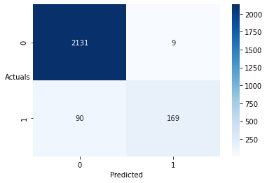

```python
sns.heatmap((metrics.confusion_matrix(df_train['Default'],y_class_pred)),annot=True,fmt='.5g',cmap='Blues');
plt.xlabel('Predicted');
plt.ylabel('Actuals',rotation=0);
```

```python
print(metrics.classification_report(df_train['Default'], y_class_pred, digits=3))
```

```
              precision    recall  f1-score   support

           0      0.959     0.996     0.977      2140
           1      0.949     0.653     0.773       259

    accuracy                          0.959      2399
   macro avg      0.954     0.824     0.875      2399
weighted avg      0.958     0.959     0.955      2399
```

```python
y_prob_pred_30 = model30.predict()
```

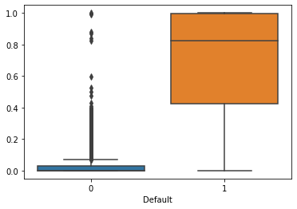

```python
sns.boxplot(x = df_train['Default'], y = y_prob_pred_30)
plt.xlabel('Default');
```

```python
from sklearn.metrics import roc_curve
fpr, tpr, thresholds = roc_curve(df_train['Default'], y_prob_pred_train)
```

```python
optimal_idx = np.argmax(tpr - fpr)
optimal_threshold = thresholds[optimal_idx]
optimal_threshold
```

```
0.24132824091512953
```

```python
y_class_pred=[]
for i in range(0,len(y_prob_pred_train)):
    if np.array(y_prob_pred_train)[i] > optimal_threshold:
        a=1
    else:
        a=0
    y_class_pred.append(a)
```

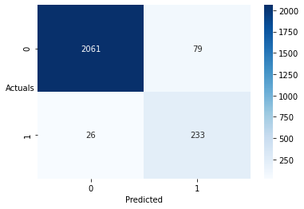

```python
sns.heatmap((metrics.confusion_matrix(df_train['Default'], y_class_pred)), annot = True,fmt = '.5g', cmap = 'Blues');
plt.xlabel('Predicted');
plt.ylabel('Actuals', rotation=0);
```

```python
print(metrics.classification_report(df_train['Default'], y_class_pred, digits=3))
```

```
              precision    recall  f1-score   support

           0      0.988     0.963     0.975      2140
           1      0.747     0.900     0.816       259

    accuracy                          0.956      2399
   macro avg      0.867     0.931     0.896      2399
weighted avg      0.962     0.956     0.958      2399
```

```python
y_prob_pred_test = model30.predict(df_test)
```

```python
y_class_pred=[]
for i in range(0,len(y_prob_pred_test)):
    if np.array(y_prob_pred_test)[i] > optimal_threshold:
        a=1
    else:
        a=0
    y_class_pred.append(a)
```

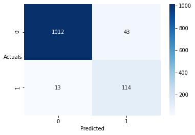

```python
sns.heatmap((metrics.confusion_matrix(df_test['Default'], y_class_pred)), annot = True,fmt = '.5g', cmap = 'Blues');
plt.xlabel('Predicted');
plt.ylabel('Actuals', rotation=0);
```

```python
print(metrics.classification_report(df_test['Default'], y_class_pred, digits=3))
```

```
              precision    recall  f1-score   support

           0      0.987     0.959     0.973      1055
           1      0.726     0.898     0.803       127

    accuracy                          0.953      1182
   macro avg      0.857     0.928     0.888      1182
weighted avg      0.959     0.953     0.955      1182
```

## SMOTE Set

```python
model1_smote = SM.logit(formula = 'Default ~ Equity_Paid_Up + Net_Working_Capital + Curr_Assets + Other_Income + Selling_Cost + Rev_earn_in_forex + Rev_exp_in_forex + Capital_exp_in_forex + Book_Value_Unit_Curr + Book_Value_Adj_Unit_Curr + Market_Capitalisation + CEPS_annualised_Unit_Curr + Cash_Flow_From_Opr + Cash_Flow_From_Inv + ROG_Capital_Employed_perc + ROG_Gross_Block_perc + ROG_Net_Sales_perc + ROG_Cost_of_Prod_perc + ROG_PAT_perc + ROG_Rev_earn_in_forex_perc + ROG_Rev_exp_in_forex_perc + ROG_Market_Capitalisation_perc + Curr_Ratio_Latest + Inventory_Ratio_Latest + Debtors_Ratio_Latest + Total_Asset_Turnover_Ratio_Latest + Interest_Cover_Ratio_Latest + PBIDTM_perc_Latest + CPM_perc_Latest + Debtors_Vel_Days + Creditors_Vel_Days + Inventory_Vel_Days + Value_of_Output_to_Total_Assets + Value_of_Output_to_Gross_Block', data = df_train_smote).fit(maxiter = 10000, method = 'bfgs')
print(model1_smote.summary())
model1_smote.pvalues.sort_values(ascending = False).head()
```

```
Optimization terminated successfully.
         Current function value: 0.210625
         Iterations: 388
         Function evaluations: 481
         Gradient evaluations: 463
                           Logit Regression Results
==============================================================================
Dep. Variable:                Default   No. Observations:                 4281
Model:                          Logit   Df Residuals:                     4246
Method:                           MLE   Df Model:                           34
Date:                Sun, 05 Dec 2021   Pseudo R-squ.:                  0.6961
Time:                        23:11:29   Log-Likelihood:                -901.68
converged:                       True   LL-Null:                       -2967.4
Covariance Type:            nonrobust   LLR p-value:                     0.000
=====================================================================================================
                                        coef    std err          z      P>|z|      [0.025      0.975]
-----------------------------------------------------------------------------------------------------
Intercept                             0.9395      0.085     11.014      0.000       0.772       1.107
Equity_Paid_Up                       -0.0001      0.001     -0.201      0.841      -0.002       0.001
Net_Working_Capital                   0.0001      0.000      0.855      0.392      -0.000       0.000
Curr_Assets                       -4.714e-05      0.000     -0.378      0.705      -0.000       0.000
Other_Income                          0.0149      0.003      4.394      0.000       0.008       0.021
Selling_Cost                         -0.0073      0.003     -2.556      0.011      -0.013      -0.002
Rev_earn_in_forex                     0.0015      0.001      2.521      0.012       0.000       0.003
Rev_exp_in_forex                   7.922e-05      0.000      0.263      0.792      -0.001       0.001
Capital_exp_in_forex                  0.0123      0.007      1.858      0.063      -0.001       0.025
Book_Value_Unit_Curr                 -0.1192      0.030     -4.029      0.000      -0.177      -0.061
Book_Value_Adj_Unit_Curr             -0.0438      0.029     -1.486      0.137      -0.101       0.014
Market_Capitalisation                -0.0012      0.000     -4.826      0.000      -0.002      -0.001
CEPS_annualised_Unit_Curr            -0.2268      0.017    -13.302      0.000      -0.260      -0.193
Cash_Flow_From_Opr                   -0.0029      0.001     -2.841      0.005      -0.005      -0.001
Cash_Flow_From_Inv                   -0.0035      0.001     -3.955      0.000      -0.005      -0.002
ROG_Capital_Employed_perc            -0.0005      0.000     -1.576      0.115      -0.001       0.000
ROG_Gross_Block_perc               -2.57e-05   7.41e-05     -0.347      0.729      -0.000       0.000
ROG_Net_Sales_perc                   -0.0010      0.000     -2.053      0.040      -0.002   -4.33e-05
ROG_Cost_of_Prod_perc                -0.0001      0.000     -0.698      0.485      -0.000       0.000
ROG_PAT_perc                          0.0002   3.36e-05      5.426      0.000       0.000       0.000
ROG_Rev_earn_in_forex_perc           -0.0058      0.002     -2.992      0.003      -0.010      -0.002
ROG_Rev_exp_in_forex_perc            -0.0006      0.001     -0.826      0.409      -0.002       0.001
ROG_Market_Capitalisation_perc       -0.0003      0.000     -0.787      0.431      -0.001       0.000
Curr_Ratio_Latest                    -0.0329      0.007     -4.449      0.000      -0.047      -0.018
Inventory_Ratio_Latest               -0.0037      0.002     -2.430      0.015      -0.007      -0.001
Debtors_Ratio_Latest                 -0.0036      0.002     -1.909      0.056      -0.007    9.66e-05
Total_Asset_Turnover_Ratio_Latest     0.0539      0.034      1.604      0.109      -0.012       0.120
Interest_Cover_Ratio_Latest          -0.0018      0.001     -2.715      0.007      -0.003      -0.000
PBIDTM_perc_Latest                 1.792e-05      0.000      0.177      0.860      -0.000       0.000
CPM_perc_Latest                   -8.166e-05   2.48e-05     -3.287      0.001      -0.000    -3.3e-05
Debtors_Vel_Days                  -8.161e-05   3.36e-05     -2.429      0.015      -0.000   -1.58e-05
Creditors_Vel_Days                  7.98e-06   4.25e-06      1.877      0.061   -3.53e-07    1.63e-05
Inventory_Vel_Days                    0.0008      0.000      1.778      0.075   -7.96e-05       0.002
Value_of_Output_to_Total_Assets      -0.1608      0.084     -1.908      0.056      -0.326       0.004
Value_of_Output_to_Gross_Block       -0.0046      0.001     -3.121      0.002      -0.007      -0.002
=====================================================================================================

Possibly complete quasi-separation: A fraction 0.30 of observations can be
perfectly predicted. This might indicate that there is complete
quasi-separation. In this case some parameters will not be identified.
```

```
PBIDTM_perc_Latest      0.859589
Equity_Paid_Up          0.840755
Rev_exp_in_forex        0.792235
ROG_Gross_Block_perc    0.728552
Curr_Assets             0.705412
dtype: float64
```

```python
model2_smote = SM.logit(formula = 'Default ~ Equity_Paid_Up + Net_Working_Capital + Curr_Assets + Other_Income + Selling_Cost + Rev_earn_in_forex + Rev_exp_in_forex + Capital_exp_in_forex + Book_Value_Unit_Curr + Book_Value_Adj_Unit_Curr + Market_Capitalisation + CEPS_annualised_Unit_Curr + Cash_Flow_From_Opr + Cash_Flow_From_Inv + ROG_Capital_Employed_perc + ROG_Gross_Block_perc + ROG_Net_Sales_perc + ROG_Cost_of_Prod_perc + ROG_PAT_perc + ROG_Rev_earn_in_forex_perc + ROG_Rev_exp_in_forex_perc + ROG_Market_Capitalisation_perc + Curr_Ratio_Latest + Inventory_Ratio_Latest + Debtors_Ratio_Latest + Total_Asset_Turnover_Ratio_Latest + Interest_Cover_Ratio_Latest + CPM_perc_Latest + Debtors_Vel_Days + Creditors_Vel_Days + Inventory_Vel_Days + Value_of_Output_to_Total_Assets + Value_of_Output_to_Gross_Block', data = df_train_smote).fit(maxiter = 10000, method = 'bfgs')
print(model2_smote.summary())
model2_smote.pvalues.sort_values(ascending = False).head()
```

```
Optimization terminated successfully.
         Current function value: 0.210628
         Iterations: 377
         Function evaluations: 451
         Gradient evaluations: 431
                           Logit Regression Results
==============================================================================
Dep. Variable:                Default   No. Observations:                 4281
Model:                          Logit   Df Residuals:                     4247
Method:                           MLE   Df Model:                           33
Date:                Sun, 05 Dec 2021   Pseudo R-squ.:                  0.6961
Time:                        23:11:29   Log-Likelihood:                -901.70
converged:                       True   LL-Null:                       -2967.4
Covariance Type:            nonrobust   LLR p-value:                     0.000
=====================================================================================================
                                        coef    std err          z      P>|z|      [0.025      0.975]
-----------------------------------------------------------------------------------------------------
Intercept                             0.9395      0.085     11.015      0.000       0.772       1.107
Equity_Paid_Up                       -0.0001      0.001     -0.200      0.841      -0.002       0.001
Net_Working_Capital                   0.0001      0.000      0.857      0.392      -0.000       0.000
Curr_Assets                       -4.701e-05      0.000     -0.378      0.705      -0.000       0.000
Other_Income                          0.0149      0.003      4.393      0.000       0.008       0.021
Selling_Cost                         -0.0073      0.003     -2.557      0.011      -0.013      -0.002
Rev_earn_in_forex                     0.0015      0.001      2.520      0.012       0.000       0.003
Rev_exp_in_forex                   7.913e-05      0.000      0.263      0.793      -0.001       0.001
Capital_exp_in_forex                  0.0123      0.007      1.855      0.064      -0.001       0.025
Book_Value_Unit_Curr                 -0.1192      0.030     -4.028      0.000      -0.177      -0.061
Book_Value_Adj_Unit_Curr             -0.0438      0.029     -1.487      0.137      -0.102       0.014
Market_Capitalisation                -0.0012      0.000     -4.824      0.000      -0.002      -0.001
CEPS_annualised_Unit_Curr            -0.2268      0.017    -13.300      0.000      -0.260      -0.193
Cash_Flow_From_Opr                   -0.0029      0.001     -2.842      0.004      -0.005      -0.001
Cash_Flow_From_Inv                   -0.0035      0.001     -3.955      0.000      -0.005      -0.002
ROG_Capital_Employed_perc            -0.0005      0.000     -1.578      0.115      -0.001       0.000
ROG_Gross_Block_perc               -2.57e-05    7.4e-05     -0.347      0.729      -0.000       0.000
ROG_Net_Sales_perc                   -0.0010      0.000     -2.049      0.040      -0.002   -4.16e-05
ROG_Cost_of_Prod_perc                -0.0001      0.000     -0.695      0.487      -0.000       0.000
ROG_PAT_perc                          0.0002   3.36e-05      5.426      0.000       0.000       0.000
ROG_Rev_earn_in_forex_perc           -0.0058      0.002     -2.991      0.003      -0.010      -0.002
ROG_Rev_exp_in_forex_perc            -0.0006      0.001     -0.826      0.409      -0.002       0.001
ROG_Market_Capitalisation_perc       -0.0003      0.000     -0.787      0.432      -0.001       0.000
Curr_Ratio_Latest                    -0.0329      0.007     -4.449      0.000      -0.047      -0.018
Inventory_Ratio_Latest               -0.0037      0.002     -2.430      0.015      -0.007      -0.001
Debtors_Ratio_Latest                 -0.0036      0.002     -1.909      0.056      -0.007    9.67e-05
Total_Asset_Turnover_Ratio_Latest     0.0539      0.034      1.604      0.109      -0.012       0.120
Interest_Cover_Ratio_Latest          -0.0018      0.001     -2.708      0.007      -0.003      -0.000
CPM_perc_Latest                   -7.889e-05   2.19e-05     -3.610      0.000      -0.000   -3.61e-05
Debtors_Vel_Days                  -8.187e-05   3.36e-05     -2.436      0.015      -0.000    -1.6e-05
Creditors_Vel_Days                 7.983e-06   4.26e-06      1.876      0.061   -3.58e-07    1.63e-05
Inventory_Vel_Days                    0.0008      0.000      1.776      0.076   -8.03e-05       0.002
Value_of_Output_to_Total_Assets      -0.1608      0.084     -1.908      0.056      -0.326       0.004
Value_of_Output_to_Gross_Block       -0.0046      0.001     -3.120      0.002      -0.007      -0.002
=====================================================================================================

Possibly complete quasi-separation: A fraction 0.30 of observations can be
perfectly predicted. This might indicate that there is complete
quasi-separation. In this case some parameters will not be identified.
```

```
Equity_Paid_Up           0.841399
Rev_exp_in_forex         0.792549
ROG_Gross_Block_perc     0.728532
Curr_Assets              0.705483
ROG_Cost_of_Prod_perc    0.487306
dtype: float64
```

```python
model3_smote = SM.logit(formula = 'Default ~Net_Working_Capital + Curr_Assets + Other_Income + Selling_Cost + Rev_earn_in_forex + Rev_exp_in_forex + Capital_exp_in_forex + Book_Value_Unit_Curr + Book_Value_Adj_Unit_Curr + Market_Capitalisation + CEPS_annualised_Unit_Curr + Cash_Flow_From_Opr + Cash_Flow_From_Inv + ROG_Capital_Employed_perc + ROG_Gross_Block_perc + ROG_Net_Sales_perc + ROG_Cost_of_Prod_perc + ROG_PAT_perc + ROG_Rev_earn_in_forex_perc + ROG_Rev_exp_in_forex_perc + ROG_Market_Capitalisation_perc + Curr_Ratio_Latest + Inventory_Ratio_Latest + Debtors_Ratio_Latest + Total_Asset_Turnover_Ratio_Latest + Interest_Cover_Ratio_Latest + CPM_perc_Latest + Debtors_Vel_Days + Creditors_Vel_Days + Inventory_Vel_Days + Value_of_Output_to_Total_Assets + Value_of_Output_to_Gross_Block', data = df_train_smote).fit(maxiter = 10000, method = 'bfgs')
print(model3_smote.summary())
model3_smote.pvalues.sort_values(ascending = False).head()
```

```
Warning: Desired error not necessarily achieved due to precision loss.
         Current function value: 0.402167
         Iterations: 37
         Function evaluations: 80
         Gradient evaluations: 62
                           Logit Regression Results
==============================================================================
Dep. Variable:                Default   No. Observations:                 4281
Model:                          Logit   Df Residuals:                     4248
Method:                           MLE   Df Model:                           32
Date:                Sun, 05 Dec 2021   Pseudo R-squ.:                  0.4198
Time:                        23:11:29   Log-Likelihood:                -1721.7
converged:                      False   LL-Null:                       -2967.4
Covariance Type:            nonrobust   LLR p-value:                     0.000
=====================================================================================================
                                        coef    std err          z      P>|z|      [0.025      0.975]
-----------------------------------------------------------------------------------------------------
Intercept                             0.5072      0.056      9.089      0.000       0.398       0.617
Net_Working_Capital                  -0.0006      0.000     -4.191      0.000      -0.001      -0.000
Curr_Assets                       -1.163e-05   1.81e-05     -0.642      0.521   -4.71e-05    2.39e-05
Other_Income                          0.0006      0.001      0.851      0.395      -0.001       0.002
Selling_Cost                          0.0010      0.001      0.703      0.482      -0.002       0.004
Rev_earn_in_forex                    -0.0007      0.001     -1.074      0.283      -0.002       0.001
Rev_exp_in_forex                  -6.185e-05      0.000     -0.252      0.801      -0.001       0.000
Capital_exp_in_forex                  0.0057      0.004      1.353      0.176      -0.003       0.014
Book_Value_Unit_Curr                 -0.0200      0.004     -4.684      0.000      -0.028      -0.012
Book_Value_Adj_Unit_Curr          -2.359e-05      0.004     -0.006      0.996      -0.008       0.008
Market_Capitalisation                -0.0002   7.81e-05     -2.766      0.006      -0.000   -6.29e-05
CEPS_annualised_Unit_Curr             0.0059      0.001      4.875      0.000       0.004       0.008
Cash_Flow_From_Opr                   -0.0016      0.000     -3.689      0.000      -0.002      -0.001
Cash_Flow_From_Inv                    0.0001      0.001      0.141      0.888      -0.001       0.002
ROG_Capital_Employed_perc            -0.0005      0.000     -2.043      0.041      -0.001   -2.06e-05
ROG_Gross_Block_perc                  0.0005      0.000      2.023      0.043    1.54e-05       0.001
ROG_Net_Sales_perc                   -0.0001      0.000     -0.816      0.414      -0.000       0.000
ROG_Cost_of_Prod_perc                -0.0001    8.7e-05     -1.551      0.121      -0.000    3.56e-05
ROG_PAT_perc                      -1.176e-05   9.48e-06     -1.241      0.215   -3.03e-05    6.81e-06
ROG_Rev_earn_in_forex_perc           -0.0018      0.001     -2.540      0.011      -0.003      -0.000
ROG_Rev_exp_in_forex_perc            -0.0003      0.000     -1.154      0.249      -0.001       0.000
ROG_Market_Capitalisation_perc       -0.0019      0.000     -4.016      0.000      -0.003      -0.001
Curr_Ratio_Latest                    -0.0331      0.005     -6.656      0.000      -0.043      -0.023
Inventory_Ratio_Latest               -0.0018      0.001     -2.642      0.008      -0.003      -0.000
Debtors_Ratio_Latest                 -0.0003      0.000     -0.779      0.436      -0.001       0.000
Total_Asset_Turnover_Ratio_Latest     0.1013      0.024      4.237      0.000       0.054       0.148
Interest_Cover_Ratio_Latest          -0.0017      0.001     -2.262      0.024      -0.003      -0.000
CPM_perc_Latest                    1.745e-06   3.39e-06      0.514      0.607    -4.9e-06     8.4e-06
Debtors_Vel_Days                  -1.239e-05   1.04e-05     -1.196      0.232   -3.27e-05    7.91e-06
Creditors_Vel_Days                 1.838e-05   9.85e-06      1.867      0.062   -9.17e-07    3.77e-05
Inventory_Vel_Days                    0.0008      0.000      3.008      0.003       0.000       0.001
Value_of_Output_to_Total_Assets      -0.4263      0.064     -6.685      0.000      -0.551      -0.301
Value_of_Output_to_Gross_Block       -0.0003      0.000     -0.819      0.413      -0.001       0.000
=====================================================================================================
```

```
Book_Value_Adj_Unit_Curr    0.995610
Cash_Flow_From_Inv          0.888111
Rev_exp_in_forex            0.800729
CPM_perc_Latest             0.606950
Curr_Assets                 0.520872
dtype: float64
```

```python
model4_smote = SM.logit(formula = 'Default ~Net_Working_Capital + Curr_Assets + Other_Income + Selling_Cost + Rev_earn_in_forex + Rev_exp_in_forex + Capital_exp_in_forex + Book_Value_Unit_Curr + Market_Capitalisation + CEPS_annualised_Unit_Curr + Cash_Flow_From_Opr + Cash_Flow_From_Inv + ROG_Capital_Employed_perc + ROG_Gross_Block_perc + ROG_Net_Sales_perc + ROG_Cost_of_Prod_perc + ROG_PAT_perc + ROG_Rev_earn_in_forex_perc + ROG_Rev_exp_in_forex_perc + ROG_Market_Capitalisation_perc + Curr_Ratio_Latest + Inventory_Ratio_Latest + Debtors_Ratio_Latest + Total_Asset_Turnover_Ratio_Latest + Interest_Cover_Ratio_Latest + CPM_perc_Latest + Debtors_Vel_Days + Creditors_Vel_Days + Inventory_Vel_Days + Value_of_Output_to_Total_Assets + Value_of_Output_to_Gross_Block', data = df_train_smote).fit(maxiter = 10000, method = 'bfgs')
print(model4_smote.summary())
model4_smote.pvalues.sort_values(ascending = False).head()
```

```
Optimization terminated successfully.
         Current function value: 0.210991
         Iterations: 295
         Function evaluations: 353
         Gradient evaluations: 341
                           Logit Regression Results
==============================================================================
Dep. Variable:                Default   No. Observations:                 4281
Model:                          Logit   Df Residuals:                     4249
Method:                           MLE   Df Model:                           31
Date:                Sun, 05 Dec 2021   Pseudo R-squ.:                  0.6956
Time:                        23:11:29   Log-Likelihood:                -903.25
converged:                       True   LL-Null:                       -2967.4
Covariance Type:            nonrobust   LLR p-value:                     0.000
=====================================================================================================
                                        coef    std err          z      P>|z|      [0.025      0.975]
-----------------------------------------------------------------------------------------------------
Intercept                             0.9308      0.084     11.066      0.000       0.766       1.096
Net_Working_Capital                   0.0002      0.000      1.040      0.298      -0.000       0.000
Curr_Assets                       -5.453e-05      0.000     -0.381      0.704      -0.000       0.000
Other_Income                          0.0145      0.003      4.461      0.000       0.008       0.021
Selling_Cost                         -0.0071      0.003     -2.550      0.011      -0.013      -0.002
Rev_earn_in_forex                     0.0015      0.001      2.515      0.012       0.000       0.003
Rev_exp_in_forex                    8.55e-05      0.000      0.287      0.774      -0.000       0.001
Capital_exp_in_forex                  0.0119      0.008      1.488      0.137      -0.004       0.028
Book_Value_Unit_Curr                 -0.1623      0.007    -23.016      0.000      -0.176      -0.149
Market_Capitalisation                -0.0012      0.000     -4.880      0.000      -0.002      -0.001
CEPS_annualised_Unit_Curr            -0.2263      0.017    -13.232      0.000      -0.260      -0.193
Cash_Flow_From_Opr                   -0.0030      0.001     -2.988      0.003      -0.005      -0.001
Cash_Flow_From_Inv                   -0.0036      0.001     -3.856      0.000      -0.005      -0.002
ROG_Capital_Employed_perc            -0.0005      0.000     -1.572      0.116      -0.001       0.000
ROG_Gross_Block_perc              -2.524e-05    7.4e-05     -0.341      0.733      -0.000       0.000
ROG_Net_Sales_perc                   -0.0009      0.000     -2.031      0.042      -0.002   -3.32e-05
ROG_Cost_of_Prod_perc                -0.0001      0.000     -0.689      0.491      -0.000       0.000
ROG_PAT_perc                          0.0002   3.34e-05      5.514      0.000       0.000       0.000
ROG_Rev_earn_in_forex_perc           -0.0057      0.002     -2.963      0.003      -0.010      -0.002
ROG_Rev_exp_in_forex_perc            -0.0006      0.001     -0.829      0.407      -0.002       0.001
ROG_Market_Capitalisation_perc       -0.0002      0.000     -0.746      0.456      -0.001       0.000
Curr_Ratio_Latest                    -0.0331      0.007     -4.457      0.000      -0.048      -0.019
Inventory_Ratio_Latest               -0.0037      0.002     -2.470      0.014      -0.007      -0.001
Debtors_Ratio_Latest                 -0.0036      0.002     -1.897      0.058      -0.007       0.000
Total_Asset_Turnover_Ratio_Latest     0.0544      0.034      1.615      0.106      -0.012       0.120
Interest_Cover_Ratio_Latest          -0.0018      0.001     -2.717      0.007      -0.003      -0.000
CPM_perc_Latest                   -7.853e-05   2.19e-05     -3.583      0.000      -0.000   -3.56e-05
Debtors_Vel_Days                  -8.124e-05   3.36e-05     -2.417      0.016      -0.000   -1.54e-05
Creditors_Vel_Days                 8.084e-06   4.34e-06      1.864      0.062   -4.14e-07    1.66e-05
Inventory_Vel_Days                    0.0008      0.000      1.725      0.085      -0.000       0.002
Value_of_Output_to_Total_Assets      -0.1580      0.084     -1.879      0.060      -0.323       0.007
Value_of_Output_to_Gross_Block       -0.0045      0.001     -3.099      0.002      -0.007      -0.002
=====================================================================================================

Possibly complete quasi-separation: A fraction 0.30 of observations can be
perfectly predicted. This might indicate that there is complete
quasi-separation. In this case some parameters will not be identified.
```

```
Rev_exp_in_forex                  0.773915
ROG_Gross_Block_perc              0.733251
Curr_Assets                       0.703552
ROG_Cost_of_Prod_perc             0.490843
ROG_Market_Capitalisation_perc    0.455896
dtype: float64
```

```python
model5_smote = SM.logit(formula = 'Default ~Net_Working_Capital + Curr_Assets + Other_Income + Selling_Cost + Rev_earn_in_forex + Capital_exp_in_forex + Book_Value_Unit_Curr + Market_Capitalisation + CEPS_annualised_Unit_Curr + Cash_Flow_From_Opr + Cash_Flow_From_Inv + ROG_Capital_Employed_perc + ROG_Gross_Block_perc + ROG_Net_Sales_perc + ROG_Cost_of_Prod_perc + ROG_PAT_perc + ROG_Rev_earn_in_forex_perc + ROG_Rev_exp_in_forex_perc + ROG_Market_Capitalisation_perc + Curr_Ratio_Latest + Inventory_Ratio_Latest + Debtors_Ratio_Latest + Total_Asset_Turnover_Ratio_Latest + Interest_Cover_Ratio_Latest + CPM_perc_Latest + Debtors_Vel_Days + Creditors_Vel_Days + Inventory_Vel_Days + Value_of_Output_to_Total_Assets + Value_of_Output_to_Gross_Block', data = df_train_smote).fit(maxiter = 10000, method = 'bfgs')
print(model5_smote.summary())
model5_smote.pvalues.sort_values(ascending = False).head()
```

```
Optimization terminated successfully.
         Current function value: 0.211000
         Iterations: 333
         Function evaluations: 399
         Gradient evaluations: 389
                           Logit Regression Results
==============================================================================
Dep. Variable:                Default   No. Observations:                 4281
Model:                          Logit   Df Residuals:                     4250
Method:                           MLE   Df Model:                           30
Date:                Sun, 05 Dec 2021   Pseudo R-squ.:                  0.6956
Time:                        23:11:30   Log-Likelihood:                -903.29
converged:                       True   LL-Null:                       -2967.4
Covariance Type:            nonrobust   LLR p-value:                     0.000
=====================================================================================================
                                        coef    std err          z      P>|z|      [0.025      0.975]
-----------------------------------------------------------------------------------------------------
Intercept                             0.9299      0.084     11.066      0.000       0.765       1.095
Net_Working_Capital                   0.0002      0.000      1.061      0.289      -0.000       0.000
Curr_Assets                        -5.25e-05      0.000     -0.379      0.705      -0.000       0.000
Other_Income                          0.0146      0.003      4.450      0.000       0.008       0.021
Selling_Cost                         -0.0071      0.003     -2.547      0.011      -0.013      -0.002
Rev_earn_in_forex                     0.0016      0.000      4.199      0.000       0.001       0.002
Capital_exp_in_forex                  0.0118      0.008      1.427      0.153      -0.004       0.028
Book_Value_Unit_Curr                 -0.1623      0.007    -23.015      0.000      -0.176      -0.149
Market_Capitalisation                -0.0012      0.000     -4.875      0.000      -0.002      -0.001
CEPS_annualised_Unit_Curr            -0.2262      0.017    -13.242      0.000      -0.260      -0.193
Cash_Flow_From_Opr                   -0.0029      0.001     -3.032      0.002      -0.005      -0.001
Cash_Flow_From_Inv                   -0.0036      0.001     -3.902      0.000      -0.005      -0.002
ROG_Capital_Employed_perc            -0.0005      0.000     -1.571      0.116      -0.001       0.000
ROG_Gross_Block_perc              -2.521e-05    7.4e-05     -0.341      0.733      -0.000       0.000
ROG_Net_Sales_perc                   -0.0009      0.000     -2.031      0.042      -0.002   -3.31e-05
ROG_Cost_of_Prod_perc                -0.0001      0.000     -0.688      0.491      -0.000       0.000
ROG_PAT_perc                          0.0002   3.34e-05      5.511      0.000       0.000       0.000
ROG_Rev_earn_in_forex_perc           -0.0058      0.002     -2.973      0.003      -0.010      -0.002
ROG_Rev_exp_in_forex_perc            -0.0006      0.001     -0.830      0.406      -0.002       0.001
ROG_Market_Capitalisation_perc       -0.0002      0.000     -0.748      0.454      -0.001       0.000
Curr_Ratio_Latest                    -0.0331      0.007     -4.456      0.000      -0.048      -0.019
Inventory_Ratio_Latest               -0.0037      0.001     -2.453      0.014      -0.007      -0.001
Debtors_Ratio_Latest                 -0.0036      0.002     -1.898      0.058      -0.007       0.000
Total_Asset_Turnover_Ratio_Latest     0.0544      0.034      1.615      0.106      -0.012       0.120
Interest_Cover_Ratio_Latest          -0.0018      0.001     -2.718      0.007      -0.003      -0.000
CPM_perc_Latest                   -7.847e-05   2.19e-05     -3.582      0.000      -0.000   -3.55e-05
Debtors_Vel_Days                  -8.119e-05   3.36e-05     -2.416      0.016      -0.000   -1.53e-05
Creditors_Vel_Days                 8.081e-06   4.33e-06      1.866      0.062   -4.09e-07    1.66e-05
Inventory_Vel_Days                    0.0007      0.000      1.720      0.085      -0.000       0.002
Value_of_Output_to_Total_Assets      -0.1577      0.084     -1.876      0.061      -0.322       0.007
Value_of_Output_to_Gross_Block       -0.0045      0.001     -3.095      0.002      -0.007      -0.002
=====================================================================================================

Possibly complete quasi-separation: A fraction 0.30 of observations can be
perfectly predicted. This might indicate that there is complete
quasi-separation. In this case some parameters will not be identified.
```

```
ROG_Gross_Block_perc              0.733462
Curr_Assets                       0.704955
ROG_Cost_of_Prod_perc             0.491177
ROG_Market_Capitalisation_perc    0.454498
ROG_Rev_exp_in_forex_perc         0.406319
dtype: float64
```

```python
model6_smote = SM.logit(formula = 'Default ~Net_Working_Capital + Curr_Assets + Other_Income + Selling_Cost + Rev_earn_in_forex + Capital_exp_in_forex + Book_Value_Unit_Curr + Market_Capitalisation + CEPS_annualised_Unit_Curr + Cash_Flow_From_Opr + Cash_Flow_From_Inv + ROG_Capital_Employed_perc + ROG_Net_Sales_perc + ROG_Cost_of_Prod_perc + ROG_PAT_perc + ROG_Rev_earn_in_forex_perc + ROG_Rev_exp_in_forex_perc + ROG_Market_Capitalisation_perc + Curr_Ratio_Latest + Inventory_Ratio_Latest + Debtors_Ratio_Latest + Total_Asset_Turnover_Ratio_Latest + Interest_Cover_Ratio_Latest + CPM_perc_Latest + Debtors_Vel_Days + Creditors_Vel_Days + Inventory_Vel_Days + Value_of_Output_to_Total_Assets + Value_of_Output_to_Gross_Block', data = df_train_smote).fit(maxiter = 10000, method = 'bfgs')
print(model6_smote.summary())
model6_smote.pvalues.sort_values(ascending = False).head()
```

```
Optimization terminated successfully.
         Current function value: 0.211010
         Iterations: 306
         Function evaluations: 352
         Gradient evaluations: 342
                           Logit Regression Results
==============================================================================
Dep. Variable:                Default   No. Observations:                 4281
Model:                          Logit   Df Residuals:                     4251
Method:                           MLE   Df Model:                           29
Date:                Sun, 05 Dec 2021   Pseudo R-squ.:                  0.6956
Time:                        23:11:30   Log-Likelihood:                -903.34
converged:                       True   LL-Null:                       -2967.4
Covariance Type:            nonrobust   LLR p-value:                     0.000
=====================================================================================================
                                        coef    std err          z      P>|z|      [0.025      0.975]
-----------------------------------------------------------------------------------------------------
Intercept                             0.9294      0.084     11.063      0.000       0.765       1.094
Net_Working_Capital                   0.0002      0.000      1.062      0.288      -0.000       0.000
Curr_Assets                       -5.249e-05      0.000     -0.379      0.705      -0.000       0.000
Other_Income                          0.0146      0.003      4.449      0.000       0.008       0.021
Selling_Cost                         -0.0071      0.003     -2.547      0.011      -0.013      -0.002
Rev_earn_in_forex                     0.0016      0.000      4.199      0.000       0.001       0.002
Capital_exp_in_forex                  0.0118      0.008      1.427      0.154      -0.004       0.028
Book_Value_Unit_Curr                 -0.1623      0.007    -23.013      0.000      -0.176      -0.148
Market_Capitalisation                -0.0012      0.000     -4.875      0.000      -0.002      -0.001
CEPS_annualised_Unit_Curr            -0.2261      0.017    -13.242      0.000      -0.260      -0.193
Cash_Flow_From_Opr                   -0.0029      0.001     -3.033      0.002      -0.005      -0.001
Cash_Flow_From_Inv                   -0.0036      0.001     -3.900      0.000      -0.005      -0.002
ROG_Capital_Employed_perc            -0.0005      0.000     -1.572      0.116      -0.001       0.000
ROG_Net_Sales_perc                   -0.0009      0.000     -2.032      0.042      -0.002   -3.34e-05
ROG_Cost_of_Prod_perc                -0.0001      0.000     -0.688      0.491      -0.000       0.000
ROG_PAT_perc                          0.0002   3.33e-05      5.508      0.000       0.000       0.000
ROG_Rev_earn_in_forex_perc           -0.0058      0.002     -2.973      0.003      -0.010      -0.002
ROG_Rev_exp_in_forex_perc            -0.0006      0.001     -0.830      0.406      -0.002       0.001
ROG_Market_Capitalisation_perc       -0.0002      0.000     -0.748      0.455      -0.001       0.000
Curr_Ratio_Latest                    -0.0331      0.007     -4.466      0.000      -0.048      -0.019
Inventory_Ratio_Latest               -0.0037      0.001     -2.453      0.014      -0.007      -0.001
Debtors_Ratio_Latest                 -0.0036      0.002     -1.899      0.058      -0.007       0.000
Total_Asset_Turnover_Ratio_Latest     0.0544      0.034      1.616      0.106      -0.012       0.120
Interest_Cover_Ratio_Latest          -0.0018      0.001     -2.718      0.007      -0.003      -0.000
CPM_perc_Latest                   -7.845e-05   2.19e-05     -3.580      0.000      -0.000   -3.55e-05
Debtors_Vel_Days                  -8.111e-05   3.36e-05     -2.414      0.016      -0.000   -1.52e-05
Creditors_Vel_Days                  8.08e-06   4.33e-06      1.866      0.062   -4.08e-07    1.66e-05
Inventory_Vel_Days                    0.0008      0.000      1.724      0.085      -0.000       0.002
Value_of_Output_to_Total_Assets      -0.1578      0.084     -1.877      0.061      -0.322       0.007
Value_of_Output_to_Gross_Block       -0.0045      0.001     -3.095      0.002      -0.007      -0.002
=====================================================================================================

Possibly complete quasi-separation: A fraction 0.30 of observations can be
perfectly predicted. This might indicate that there is complete
quasi-separation. In this case some parameters will not be identified.
```

```
Curr_Assets                       0.704788
ROG_Cost_of_Prod_perc             0.491474
ROG_Market_Capitalisation_perc    0.454602
ROG_Rev_exp_in_forex_perc         0.406353
Net_Working_Capital               0.288413
dtype: float64
```

```python
model7_smote = SM.logit(formula = 'Default ~Net_Working_Capital + Other_Income + Selling_Cost + Rev_earn_in_forex + Capital_exp_in_forex + Book_Value_Unit_Curr + Market_Capitalisation + CEPS_annualised_Unit_Curr + Cash_Flow_From_Opr + Cash_Flow_From_Inv + ROG_Capital_Employed_perc + ROG_Net_Sales_perc + ROG_Cost_of_Prod_perc + ROG_PAT_perc + ROG_Rev_earn_in_forex_perc + ROG_Rev_exp_in_forex_perc + ROG_Market_Capitalisation_perc + Curr_Ratio_Latest + Inventory_Ratio_Latest + Debtors_Ratio_Latest + Total_Asset_Turnover_Ratio_Latest + Interest_Cover_Ratio_Latest + CPM_perc_Latest + Debtors_Vel_Days + Creditors_Vel_Days + Inventory_Vel_Days + Value_of_Output_to_Total_Assets + Value_of_Output_to_Gross_Block', data = df_train_smote).fit(maxiter = 10000, method = 'bfgs')
print(model7_smote.summary())
model7_smote.pvalues.sort_values(ascending = False).head()
```

```
Optimization terminated successfully.
         Current function value: 0.211063
         Iterations: 241
         Function evaluations: 277
         Gradient evaluations: 267
                           Logit Regression Results
==============================================================================
Dep. Variable:                Default   No. Observations:                 4281
Model:                          Logit   Df Residuals:                     4252
Method:                           MLE   Df Model:                           28
Date:                Sun, 05 Dec 2021   Pseudo R-squ.:                  0.6955
Time:                        23:11:31   Log-Likelihood:                -903.56
converged:                       True   LL-Null:                       -2967.4
Covariance Type:            nonrobust   LLR p-value:                     0.000
=====================================================================================================
                                        coef    std err          z      P>|z|      [0.025      0.975]
-----------------------------------------------------------------------------------------------------
Intercept                             0.9329      0.084     11.135      0.000       0.769       1.097
Net_Working_Capital                   0.0001   9.96e-05      1.125      0.261   -8.32e-05       0.000
Other_Income                          0.0130      0.002      8.049      0.000       0.010       0.016
Selling_Cost                         -0.0064      0.002     -2.805      0.005      -0.011      -0.002
Rev_earn_in_forex                     0.0016      0.000      4.886      0.000       0.001       0.002
Capital_exp_in_forex                  0.0118      0.009      1.347      0.178      -0.005       0.029
Book_Value_Unit_Curr                 -0.1626      0.007    -23.092      0.000      -0.176      -0.149
Market_Capitalisation                -0.0012      0.000     -5.026      0.000      -0.002      -0.001
CEPS_annualised_Unit_Curr            -0.2242      0.017    -13.486      0.000      -0.257      -0.192
Cash_Flow_From_Opr                   -0.0028      0.001     -3.936      0.000      -0.004      -0.001
Cash_Flow_From_Inv                   -0.0035      0.001     -4.520      0.000      -0.005      -0.002
ROG_Capital_Employed_perc            -0.0005      0.000     -1.571      0.116      -0.001       0.000
ROG_Net_Sales_perc                   -0.0009      0.000     -2.020      0.043      -0.002   -2.79e-05
ROG_Cost_of_Prod_perc                -0.0001      0.000     -0.695      0.487      -0.000       0.000
ROG_PAT_perc                          0.0002   3.29e-05      5.534      0.000       0.000       0.000
ROG_Rev_earn_in_forex_perc           -0.0058      0.002     -3.006      0.003      -0.010      -0.002
ROG_Rev_exp_in_forex_perc            -0.0006      0.001     -0.824      0.410      -0.002       0.001
ROG_Market_Capitalisation_perc       -0.0002      0.000     -0.733      0.463      -0.001       0.000
Curr_Ratio_Latest                    -0.0332      0.007     -4.473      0.000      -0.048      -0.019
Inventory_Ratio_Latest               -0.0037      0.002     -2.432      0.015      -0.007      -0.001
Debtors_Ratio_Latest                 -0.0036      0.002     -1.899      0.058      -0.007       0.000
Total_Asset_Turnover_Ratio_Latest     0.0549      0.034      1.624      0.104      -0.011       0.121
Interest_Cover_Ratio_Latest          -0.0018      0.001     -2.721      0.007      -0.003      -0.000
CPM_perc_Latest                   -7.854e-05   2.18e-05     -3.604      0.000      -0.000   -3.58e-05
Debtors_Vel_Days                  -8.088e-05   3.36e-05     -2.408      0.016      -0.000   -1.51e-05
Creditors_Vel_Days                 8.146e-06   4.42e-06      1.844      0.065   -5.11e-07    1.68e-05
Inventory_Vel_Days                    0.0008      0.000      1.735      0.083   -9.79e-05       0.002
Value_of_Output_to_Total_Assets      -0.1600      0.084     -1.901      0.057      -0.325       0.005
Value_of_Output_to_Gross_Block       -0.0045      0.001     -3.094      0.002      -0.007      -0.002
=====================================================================================================

Possibly complete quasi-separation: A fraction 0.30 of observations can be
perfectly predicted. This might indicate that there is complete
quasi-separation. In this case some parameters will not be identified.
```

```
ROG_Cost_of_Prod_perc             0.486819
ROG_Market_Capitalisation_perc    0.463377
ROG_Rev_exp_in_forex_perc         0.409815
Net_Working_Capital               0.260621
Capital_exp_in_forex              0.177830
dtype: float64
```

```python
model8_smote = SM.logit(formula = 'Default ~Net_Working_Capital + Other_Income + Selling_Cost + Rev_earn_in_forex + Capital_exp_in_forex + Book_Value_Unit_Curr + Market_Capitalisation + CEPS_annualised_Unit_Curr + Cash_Flow_From_Opr + Cash_Flow_From_Inv + ROG_Capital_Employed_perc + ROG_Net_Sales_perc + ROG_PAT_perc + ROG_Rev_earn_in_forex_perc + ROG_Rev_exp_in_forex_perc + ROG_Market_Capitalisation_perc + Curr_Ratio_Latest + Inventory_Ratio_Latest + Debtors_Ratio_Latest + Total_Asset_Turnover_Ratio_Latest + Interest_Cover_Ratio_Latest + CPM_perc_Latest + Debtors_Vel_Days + Creditors_Vel_Days + Inventory_Vel_Days + Value_of_Output_to_Total_Assets + Value_of_Output_to_Gross_Block', data = df_train_smote).fit(maxiter = 10000, method = 'bfgs')
print(model8_smote.summary())
model8_smote.pvalues.sort_values(ascending = False).head()
```

```
Optimization terminated successfully.
         Current function value: 0.211151
         Iterations: 243
         Function evaluations: 294
         Gradient evaluations: 284
                           Logit Regression Results
==============================================================================
Dep. Variable:                Default   No. Observations:                 4281
Model:                          Logit   Df Residuals:                     4253
Method:                           MLE   Df Model:                           27
Date:                Sun, 05 Dec 2021   Pseudo R-squ.:                  0.6954
Time:                        23:11:31   Log-Likelihood:                -903.94
converged:                       True   LL-Null:                       -2967.4
Covariance Type:            nonrobust   LLR p-value:                     0.000
=====================================================================================================
                                        coef    std err          z      P>|z|      [0.025      0.975]
-----------------------------------------------------------------------------------------------------
Intercept                             0.9321      0.084     11.129      0.000       0.768       1.096
Net_Working_Capital                   0.0001   9.94e-05      1.128      0.259   -8.27e-05       0.000
Other_Income                          0.0130      0.002      8.104      0.000       0.010       0.016
Selling_Cost                         -0.0064      0.002     -2.806      0.005      -0.011      -0.002
Rev_earn_in_forex                     0.0016      0.000      4.900      0.000       0.001       0.002
Capital_exp_in_forex                  0.0118      0.009      1.352      0.176      -0.005       0.029
Book_Value_Unit_Curr                 -0.1625      0.007    -23.104      0.000      -0.176      -0.149
Market_Capitalisation                -0.0012      0.000     -5.029      0.000      -0.002      -0.001
CEPS_annualised_Unit_Curr            -0.2239      0.017    -13.468      0.000      -0.256      -0.191
Cash_Flow_From_Opr                   -0.0028      0.001     -3.948      0.000      -0.004      -0.001
Cash_Flow_From_Inv                   -0.0035      0.001     -4.540      0.000      -0.005      -0.002
ROG_Capital_Employed_perc            -0.0005      0.000     -1.558      0.119      -0.001       0.000
ROG_Net_Sales_perc                   -0.0011      0.000     -2.800      0.005      -0.002      -0.000
ROG_PAT_perc                          0.0002   3.29e-05      5.513      0.000       0.000       0.000
ROG_Rev_earn_in_forex_perc           -0.0058      0.002     -3.007      0.003      -0.010      -0.002
ROG_Rev_exp_in_forex_perc            -0.0006      0.001     -0.817      0.414      -0.002       0.001
ROG_Market_Capitalisation_perc       -0.0002      0.000     -0.724      0.469      -0.001       0.000
Curr_Ratio_Latest                    -0.0334      0.007     -4.504      0.000      -0.048      -0.019
Inventory_Ratio_Latest               -0.0037      0.002     -2.435      0.015      -0.007      -0.001
Debtors_Ratio_Latest                 -0.0036      0.002     -1.888      0.059      -0.007       0.000
Total_Asset_Turnover_Ratio_Latest     0.0556      0.034      1.638      0.102      -0.011       0.122
Interest_Cover_Ratio_Latest          -0.0018      0.001     -2.715      0.007      -0.003      -0.000
CPM_perc_Latest                   -7.864e-05   2.15e-05     -3.652      0.000      -0.000   -3.64e-05
Debtors_Vel_Days                  -8.086e-05   3.36e-05     -2.404      0.016      -0.000   -1.49e-05
Creditors_Vel_Days                 8.157e-06   4.42e-06      1.843      0.065   -5.16e-07    1.68e-05
Inventory_Vel_Days                    0.0007      0.000      1.701      0.089      -0.000       0.002
Value_of_Output_to_Total_Assets      -0.1623      0.084     -1.929      0.054      -0.327       0.003
Value_of_Output_to_Gross_Block       -0.0045      0.001     -3.094      0.002      -0.007      -0.002
=====================================================================================================

Possibly complete quasi-separation: A fraction 0.30 of observations can be
perfectly predicted. This might indicate that there is complete
quasi-separation. In this case some parameters will not be identified.
```

```
ROG_Market_Capitalisation_perc    0.469363
ROG_Rev_exp_in_forex_perc         0.413908
Net_Working_Capital               0.259314
Capital_exp_in_forex              0.176261
ROG_Capital_Employed_perc         0.119214
dtype: float64
```

```python
model9_smote = SM.logit(formula = 'Default ~Net_Working_Capital + Other_Income + Selling_Cost + Rev_earn_in_forex + Capital_exp_in_forex + Book_Value_Unit_Curr + Market_Capitalisation + CEPS_annualised_Unit_Curr + Cash_Flow_From_Opr + Cash_Flow_From_Inv + ROG_Capital_Employed_perc + ROG_Net_Sales_perc + ROG_PAT_perc + ROG_Rev_earn_in_forex_perc + ROG_Rev_exp_in_forex_perc + Curr_Ratio_Latest + Inventory_Ratio_Latest + Debtors_Ratio_Latest + Total_Asset_Turnover_Ratio_Latest + Interest_Cover_Ratio_Latest + CPM_perc_Latest + Debtors_Vel_Days + Creditors_Vel_Days + Inventory_Vel_Days + Value_of_Output_to_Total_Assets + Value_of_Output_to_Gross_Block', data = df_train_smote).fit(maxiter = 10000, method = 'bfgs')
print(model9_smote.summary())
model9_smote.pvalues.sort_values(ascending = False).head()
```

```
Optimization terminated successfully.
         Current function value: 0.211215
         Iterations: 262
         Function evaluations: 309
         Gradient evaluations: 293
                           Logit Regression Results
==============================================================================
Dep. Variable:                Default   No. Observations:                 4281
Model:                          Logit   Df Residuals:                     4254
Method:                           MLE   Df Model:                           26
Date:                Sun, 05 Dec 2021   Pseudo R-squ.:                  0.6953
Time:                        23:11:31   Log-Likelihood:                -904.21
converged:                       True   LL-Null:                       -2967.4
Covariance Type:            nonrobust   LLR p-value:                     0.000
=====================================================================================================
                                        coef    std err          z      P>|z|      [0.025      0.975]
-----------------------------------------------------------------------------------------------------
Intercept                             0.9281      0.084     11.108      0.000       0.764       1.092
Net_Working_Capital                   0.0001    9.9e-05      1.158      0.247   -7.94e-05       0.000
Other_Income                          0.0130      0.002      8.059      0.000       0.010       0.016
Selling_Cost                         -0.0064      0.002     -2.816      0.005      -0.011      -0.002
Rev_earn_in_forex                     0.0016      0.000      4.889      0.000       0.001       0.002
Capital_exp_in_forex                  0.0120      0.009      1.370      0.171      -0.005       0.029
Book_Value_Unit_Curr                 -0.1626      0.007    -23.118      0.000      -0.176      -0.149
Market_Capitalisation                -0.0012      0.000     -5.086      0.000      -0.002      -0.001
CEPS_annualised_Unit_Curr            -0.2246      0.017    -13.539      0.000      -0.257      -0.192
Cash_Flow_From_Opr                   -0.0028      0.001     -3.929      0.000      -0.004      -0.001
Cash_Flow_From_Inv                   -0.0035      0.001     -4.556      0.000      -0.005      -0.002
ROG_Capital_Employed_perc            -0.0005      0.000     -1.560      0.119      -0.001       0.000
ROG_Net_Sales_perc                   -0.0011      0.000     -2.797      0.005      -0.002      -0.000
ROG_PAT_perc                          0.0002    3.3e-05      5.505      0.000       0.000       0.000
ROG_Rev_earn_in_forex_perc           -0.0058      0.002     -3.021      0.003      -0.010      -0.002
ROG_Rev_exp_in_forex_perc            -0.0006      0.001     -0.809      0.418      -0.002       0.001
Curr_Ratio_Latest                    -0.0333      0.007     -4.495      0.000      -0.048      -0.019
Inventory_Ratio_Latest               -0.0037      0.002     -2.443      0.015      -0.007      -0.001
Debtors_Ratio_Latest                 -0.0035      0.002     -1.879      0.060      -0.007       0.000
Total_Asset_Turnover_Ratio_Latest     0.0552      0.034      1.633      0.102      -0.011       0.122
Interest_Cover_Ratio_Latest          -0.0018      0.001     -2.735      0.006      -0.003      -0.001
CPM_perc_Latest                   -7.877e-05   2.15e-05     -3.658      0.000      -0.000   -3.66e-05
Debtors_Vel_Days                  -8.073e-05   3.37e-05     -2.395      0.017      -0.000   -1.47e-05
Creditors_Vel_Days                 8.195e-06   4.46e-06      1.836      0.066   -5.52e-07    1.69e-05
Inventory_Vel_Days                    0.0007      0.000      1.682      0.093      -0.000       0.002
Value_of_Output_to_Total_Assets      -0.1642      0.084     -1.950      0.051      -0.329       0.001
Value_of_Output_to_Gross_Block       -0.0045      0.001     -3.081      0.002      -0.007      -0.002
=====================================================================================================

Possibly complete quasi-separation: A fraction 0.30 of observations can be
perfectly predicted. This might indicate that there is complete
quasi-separation. In this case some parameters will not be identified.
```

```
ROG_Rev_exp_in_forex_perc            0.418350
Net_Working_Capital                  0.247021
Capital_exp_in_forex                 0.170711
ROG_Capital_Employed_perc            0.118783
Total_Asset_Turnover_Ratio_Latest    0.102462
dtype: float64
```

```python
model10_smote = SM.logit(formula = 'Default ~Net_Working_Capital + Other_Income + Selling_Cost + Rev_earn_in_forex + Capital_exp_in_forex + Book_Value_Unit_Curr + Market_Capitalisation + CEPS_annualised_Unit_Curr + Cash_Flow_From_Opr + Cash_Flow_From_Inv + ROG_Capital_Employed_perc + ROG_Net_Sales_perc + ROG_PAT_perc + ROG_Rev_earn_in_forex_perc + Curr_Ratio_Latest + Inventory_Ratio_Latest + Debtors_Ratio_Latest + Total_Asset_Turnover_Ratio_Latest + Interest_Cover_Ratio_Latest + CPM_perc_Latest + Debtors_Vel_Days + Creditors_Vel_Days + Inventory_Vel_Days + Value_of_Output_to_Total_Assets + Value_of_Output_to_Gross_Block', data = df_train_smote).fit(maxiter = 10000, method = 'bfgs')
print(model10_smote.summary())
model10_smote.pvalues.sort_values(ascending = False).head()
```

```
Optimization terminated successfully.
         Current function value: 0.211411
         Iterations: 265
         Function evaluations: 312
         Gradient evaluations: 300
                           Logit Regression Results
==============================================================================
Dep. Variable:                Default   No. Observations:                 4281
Model:                          Logit   Df Residuals:                     4255
Method:                           MLE   Df Model:                           25
Date:                Sun, 05 Dec 2021   Pseudo R-squ.:                  0.6950
Time:                        23:11:31   Log-Likelihood:                -905.05
converged:                       True   LL-Null:                       -2967.4
Covariance Type:            nonrobust   LLR p-value:                     0.000
=====================================================================================================
                                        coef    std err          z      P>|z|      [0.025      0.975]
-----------------------------------------------------------------------------------------------------
Intercept                             0.9294      0.084     11.118      0.000       0.766       1.093
Net_Working_Capital                   0.0001   9.85e-05      1.159      0.247   -7.89e-05       0.000
Other_Income                          0.0130      0.002      8.100      0.000       0.010       0.016
Selling_Cost                         -0.0064      0.002     -2.820      0.005      -0.011      -0.002
Rev_earn_in_forex                     0.0016      0.000      4.856      0.000       0.001       0.002
Capital_exp_in_forex                  0.0119      0.009      1.355      0.175      -0.005       0.029
Book_Value_Unit_Curr                 -0.1626      0.007    -23.132      0.000      -0.176      -0.149
Market_Capitalisation                -0.0012      0.000     -5.097      0.000      -0.002      -0.001
CEPS_annualised_Unit_Curr            -0.2244      0.017    -13.552      0.000      -0.257      -0.192
Cash_Flow_From_Opr                   -0.0028      0.001     -3.940      0.000      -0.004      -0.001
Cash_Flow_From_Inv                   -0.0035      0.001     -4.530      0.000      -0.005      -0.002
ROG_Capital_Employed_perc            -0.0005      0.000     -1.562      0.118      -0.001       0.000
ROG_Net_Sales_perc                   -0.0011      0.000     -2.812      0.005      -0.002      -0.000
ROG_PAT_perc                          0.0002   3.29e-05      5.502      0.000       0.000       0.000
ROG_Rev_earn_in_forex_perc           -0.0058      0.002     -3.009      0.003      -0.010      -0.002
Curr_Ratio_Latest                    -0.0332      0.007     -4.495      0.000      -0.048      -0.019
Inventory_Ratio_Latest               -0.0037      0.002     -2.435      0.015      -0.007      -0.001
Debtors_Ratio_Latest                 -0.0037      0.002     -1.908      0.056      -0.007    9.97e-05
Total_Asset_Turnover_Ratio_Latest     0.0540      0.033      1.615      0.106      -0.012       0.120
Interest_Cover_Ratio_Latest          -0.0018      0.001     -2.755      0.006      -0.003      -0.001
CPM_perc_Latest                   -7.891e-05   2.14e-05     -3.680      0.000      -0.000   -3.69e-05
Debtors_Vel_Days                  -8.034e-05   3.37e-05     -2.386      0.017      -0.000   -1.43e-05
Creditors_Vel_Days                 8.224e-06    4.5e-06      1.829      0.067    -5.9e-07     1.7e-05
Inventory_Vel_Days                    0.0007      0.000      1.689      0.091      -0.000       0.002
Value_of_Output_to_Total_Assets      -0.1709      0.084     -2.028      0.043      -0.336      -0.006
Value_of_Output_to_Gross_Block       -0.0045      0.001     -3.068      0.002      -0.007      -0.002
=====================================================================================================

Possibly complete quasi-separation: A fraction 0.30 of observations can be
perfectly predicted. This might indicate that there is complete
quasi-separation. In this case some parameters will not be identified.
```

```
Net_Working_Capital                  0.246522
Capital_exp_in_forex                 0.175425
ROG_Capital_Employed_perc            0.118392
Total_Asset_Turnover_Ratio_Latest    0.106268
Inventory_Vel_Days                   0.091228
dtype: float64
```

```python
model11_smote = SM.logit(formula = 'Default ~ Other_Income + Selling_Cost + Rev_earn_in_forex + Capital_exp_in_forex + Book_Value_Unit_Curr + Market_Capitalisation + CEPS_annualised_Unit_Curr + Cash_Flow_From_Opr + Cash_Flow_From_Inv + ROG_Capital_Employed_perc + ROG_Net_Sales_perc + ROG_PAT_perc + ROG_Rev_earn_in_forex_perc + Curr_Ratio_Latest + Inventory_Ratio_Latest + Debtors_Ratio_Latest + Total_Asset_Turnover_Ratio_Latest + Interest_Cover_Ratio_Latest + CPM_perc_Latest + Debtors_Vel_Days + Creditors_Vel_Days + Inventory_Vel_Days + Value_of_Output_to_Total_Assets + Value_of_Output_to_Gross_Block', data = df_train_smote).fit(maxiter = 10000, method = 'bfgs')
print(model11_smote.summary())
model11_smote.pvalues.sort_values(ascending = False).head()
```

```
Optimization terminated successfully.
         Current function value: 0.211522
         Iterations: 243
         Function evaluations: 280
         Gradient evaluations: 270
                           Logit Regression Results
==============================================================================
Dep. Variable:                Default   No. Observations:                 4281
Model:                          Logit   Df Residuals:                     4256
Method:                           MLE   Df Model:                           24
Date:                Sun, 05 Dec 2021   Pseudo R-squ.:                  0.6948
Time:                        23:11:32   Log-Likelihood:                -905.53
converged:                       True   LL-Null:                       -2967.4
Covariance Type:            nonrobust   LLR p-value:                     0.000
=====================================================================================================
                                        coef    std err          z      P>|z|      [0.025      0.975]
-----------------------------------------------------------------------------------------------------
Intercept                             0.9285      0.084     11.108      0.000       0.765       1.092
Other_Income                          0.0127      0.002      6.913      0.000       0.009       0.016
Selling_Cost                         -0.0059      0.002     -2.502      0.012      -0.010      -0.001
Rev_earn_in_forex                     0.0017      0.000      5.198      0.000       0.001       0.002
Capital_exp_in_forex                  0.0102      0.007      1.403      0.160      -0.004       0.024
Book_Value_Unit_Curr                 -0.1626      0.007    -23.166      0.000      -0.176      -0.149
Market_Capitalisation                -0.0011      0.000     -6.409      0.000      -0.001      -0.001
CEPS_annualised_Unit_Curr            -0.2240      0.017    -13.454      0.000      -0.257      -0.191
Cash_Flow_From_Opr                   -0.0033      0.001     -4.580      0.000      -0.005      -0.002
Cash_Flow_From_Inv                   -0.0039      0.001     -4.752      0.000      -0.005      -0.002
ROG_Capital_Employed_perc            -0.0005      0.000     -1.562      0.118      -0.001       0.000
ROG_Net_Sales_perc                   -0.0011      0.000     -2.822      0.005      -0.002      -0.000
ROG_PAT_perc                          0.0002   3.29e-05      5.514      0.000       0.000       0.000
ROG_Rev_earn_in_forex_perc           -0.0058      0.002     -3.020      0.003      -0.010      -0.002
Curr_Ratio_Latest                    -0.0333      0.007     -4.499      0.000      -0.048      -0.019
Inventory_Ratio_Latest               -0.0037      0.001     -2.459      0.014      -0.007      -0.001
Debtors_Ratio_Latest                 -0.0036      0.002     -1.905      0.057      -0.007       0.000
Total_Asset_Turnover_Ratio_Latest     0.0542      0.033      1.618      0.106      -0.011       0.120
Interest_Cover_Ratio_Latest          -0.0018      0.001     -2.761      0.006      -0.003      -0.001
CPM_perc_Latest                   -7.925e-05   2.14e-05     -3.706      0.000      -0.000   -3.73e-05
Debtors_Vel_Days                  -7.976e-05   3.36e-05     -2.373      0.018      -0.000   -1.39e-05
Creditors_Vel_Days                 8.239e-06    4.5e-06      1.830      0.067   -5.83e-07    1.71e-05
Inventory_Vel_Days                    0.0007      0.000      1.721      0.085      -0.000       0.002
Value_of_Output_to_Total_Assets      -0.1720      0.084     -2.039      0.041      -0.337      -0.007
Value_of_Output_to_Gross_Block       -0.0045      0.001     -3.070      0.002      -0.007      -0.002
=====================================================================================================

Possibly complete quasi-separation: A fraction 0.30 of observations can be
perfectly predicted. This might indicate that there is complete
quasi-separation. In this case some parameters will not be identified.
```

```
Capital_exp_in_forex                 0.160489
ROG_Capital_Employed_perc            0.118354
Total_Asset_Turnover_Ratio_Latest    0.105665
Inventory_Vel_Days                   0.085206
Creditors_Vel_Days                   0.067186
dtype: float64
```